# Feature Selection : Evaluating Model-Independent Feature Importance for Predictors with Dichotomous Categorical Responses

John Pauline Pineda

December 14, 2022

# **1. Table of Contents**

This project explores different model-independent feature importance metrics for predictors with dichotomous categorical responses using various helpful packages in **R**. Metrics applied in the analysis to evaluate feature importance for numeric predictors included the **Area under the Receiver Operating Characteristics Curve (AUROC)**, **Absolute T-Test Statistic**, **Maximal Information Coefficient** and **Relief Values**, while those for factor predictors included the **Volcano Plot Using Fisher’s Exact Test** and **Volcano Plot Using Gain Ratio**. All results were consolidated in a **Summary** presented at the end of the document.  
Model-independent feature importance determines the degree of relationship, usefulness and contribution of the independent variables (features) with respect to the dependent variables (target responses), outside the context of the particular model structure being applied. Analyzing the importance metrics of features allow the discovery and inclusion of only relevant features, reducing the number of meaningful variables in the model thereby providing more targeted insights into the data, speeding up the processing time, boosting its predictive performance and improving the interpretability of the results. The algorithms applied in this study (mostly contained in the **caret** package, **stats** package, **minerva** package and **CORElearn** packages) attempt to assign scores to input features based on their relevance at discriminating or predicting the target variable.

## 1.1 Sample Data

The **Solubility** dataset from the **AppliedPredictiveModeling** package was used for this illustrated example. The original numeric response was transformed to simulate a dichotomous categorical variable.  
Preliminary dataset assessment:  
**[A]** 1267 rows (observations)  
**[A.1]** Train Set = 951 observations  
**[A.2]** Test Set = 316 observations  
**[B]** 229 columns (variables)  
**[B.1]** 1/229 response = Log_Solubility_Class variable (factor)  
**[B.1.1]** Levels = Log_Solubility_Class=Low < Log_Solubility_Class=High  
**[B.2]** 228/229 predictors = All remaining variables (208/228 factor + 20/228 numeric)

**Code Chunk | Output**

```r
##################################
# Loading R libraries
##################################
library(AppliedPredictiveModeling)
library(caret)
library(rpart)
library(lattice)
library(dplyr)
library(tidyr)
library(moments)
library(skimr)
library(RANN)
library(pls)
library(corrplot)
library(tidyverse)
library(lares)
library(DMwR)
library(gridExtra)
library(rattle)
library(rpart.plot)
library(RColorBrewer)
library(stats)
library(nnet)
library(elasticnet)
library(earth)
library(party)
library(kernlab)
library(randomForest)
library(Cubist)
library(pROC)
library(mda)
library(klaR)
library(pamr)
library(minerva)
library(CORElearn)

##################################
# Loading source and
# formulating the train set
##################################
data(solubility)
Solubility_Train <- as.data.frame(cbind(solTrainY,solTrainX))
Solubility_Test  <- as.data.frame(cbind(solTestY,solTestX))

##################################
# Applying dichotomization and
# defining the response variable
##################################
Solubility_Train$Log_Solubility_Class <- ifelse(Solubility_Train$solTrainY<mean(Solubility_Train$solTrainY),
                                                "Low","High")
Solubility_Train$Log_Solubility_Class <- factor(Solubility_Train$Log_Solubility_Class,
                                                levels = c("Low","High"))
Solubility_Test$Log_Solubility_Class <- ifelse(Solubility_Test$solTestY<mean(Solubility_Train$solTrainY),
                                                "Low","High")
Solubility_Test$Log_Solubility_Class <- factor(Solubility_Test$Log_Solubility_Class,
                                                levels = c("Low","High"))

Solubility_Train$solTrainY <- NULL
Solubility_Test$solTestY <- NULL

##################################
# Performing a general exploration of the train set
##################################
dim(Solubility_Train)
```

```
## [1] 951 229
```

```r
str(Solubility_Train)
```

```
## 'data.frame':    951 obs. of  229 variables:
##  $ FP001               : int  0 0 1 0 0 1 0 1 1 1 ...
##  $ FP002               : int  1 1 1 0 0 0 1 0 0 1 ...
##  $ FP003               : int  0 0 1 1 1 1 0 1 1 1 ...
##  $ FP004               : int  0 1 1 0 1 1 1 1 1 1 ...
##  $ FP005               : int  1 1 1 0 1 0 1 0 0 1 ...
##  $ FP006               : int  0 1 0 0 1 0 0 0 1 1 ...
##  $ FP007               : int  0 1 0 1 0 0 0 1 1 1 ...
##  $ FP008               : int  1 1 1 0 0 0 1 0 0 0 ...
##  $ FP009               : int  0 0 0 0 1 1 1 0 1 0 ...
##  $ FP010               : int  0 0 1 0 0 0 0 0 0 0 ...
##  $ FP011               : int  0 1 0 0 0 0 0 0 1 0 ...
##  $ FP012               : int  0 0 0 0 0 1 0 1 0 0 ...
##  $ FP013               : int  0 0 0 0 1 0 1 0 0 0 ...
##  $ FP014               : int  0 0 0 0 0 0 1 0 0 0 ...
```

[output cut: 86 more lines]

```r
summary(Solubility_Train)
```

```
##      FP001            FP002            FP003            FP004
##  Min.   :0.0000   Min.   :0.0000   Min.   :0.0000   Min.   :0.0000
##  1st Qu.:0.0000   1st Qu.:0.0000   1st Qu.:0.0000   1st Qu.:0.0000
##  Median :0.0000   Median :1.0000   Median :0.0000   Median :1.0000
##  Mean   :0.4932   Mean   :0.5394   Mean   :0.4364   Mean   :0.5846
##  3rd Qu.:1.0000   3rd Qu.:1.0000   3rd Qu.:1.0000   3rd Qu.:1.0000
##  Max.   :1.0000   Max.   :1.0000   Max.   :1.0000   Max.   :1.0000
##      FP005            FP006            FP007            FP008
##  Min.   :0.0000   Min.   :0.0000   Min.   :0.0000   Min.   :0.000
##  1st Qu.:0.0000   1st Qu.:0.0000   1st Qu.:0.0000   1st Qu.:0.000
##  Median :1.0000   Median :0.0000   Median :0.0000   Median :0.000
##  Mean   :0.5794   Mean   :0.4006   Mean   :0.3638   Mean   :0.326
##  3rd Qu.:1.0000   3rd Qu.:1.0000   3rd Qu.:1.0000   3rd Qu.:1.000
##  Max.   :1.0000   Max.   :1.0000   Max.   :1.0000   Max.   :1.000
##      FP009            FP010            FP011            FP012
##  Min.   :0.0000   Min.   :0.0000   Min.   :0.0000   Min.   :0.0000
##  1st Qu.:0.0000   1st Qu.:0.0000   1st Qu.:0.0000   1st Qu.:0.0000
##  Median :0.0000   Median :0.0000   Median :0.0000   Median :0.0000
##  Mean   :0.2797   Mean   :0.1788   Mean   :0.2145   Mean   :0.1767
##  3rd Qu.:1.0000   3rd Qu.:0.0000   3rd Qu.:0.0000   3rd Qu.:0.0000
##  Max.   :1.0000   Max.   :1.0000   Max.   :1.0000   Max.   :1.0000
##      FP013            FP014            FP015            FP016
##  Min.   :0.0000   Min.   :0.0000   Min.   :0.0000   Min.   :0.0000
##  1st Qu.:0.0000   1st Qu.:0.0000   1st Qu.:1.0000   1st Qu.:0.0000
##  Median :0.0000   Median :0.0000   Median :1.0000   Median :0.0000
##  Mean   :0.1661   Mean   :0.1609   Mean   :0.8601   Mean   :0.1462
##  3rd Qu.:0.0000   3rd Qu.:0.0000   3rd Qu.:1.0000   3rd Qu.:0.0000
##  Max.   :1.0000   Max.   :1.0000   Max.   :1.0000   Max.   :1.0000
##      FP017            FP018            FP019           FP020
##  Min.   :0.0000   Min.   :0.0000   Min.   :0.000   Min.   :0.0000
##  1st Qu.:0.0000   1st Qu.:0.0000   1st Qu.:0.000   1st Qu.:0.0000
##  Median :0.0000   Median :0.0000   Median :0.000   Median :0.0000
##  Mean   :0.1441   Mean   :0.1314   Mean   :0.122   Mean   :0.1199
##  3rd Qu.:0.0000   3rd Qu.:0.0000   3rd Qu.:0.000   3rd Qu.:0.0000
##  Max.   :1.0000   Max.   :1.0000   Max.   :1.000   Max.   :1.0000
##      FP021            FP022            FP023           FP024
##  Min.   :0.0000   Min.   :0.0000   Min.   :0.000   Min.   :0.0000
##  1st Qu.:0.0000   1st Qu.:0.0000   1st Qu.:0.000   1st Qu.:0.0000
##  Median :0.0000   Median :0.0000   Median :0.000   Median :0.0000
##  Mean   :0.1209   Mean   :0.1041   Mean   :0.123   Mean   :0.1125
```

[output cut: 351 more lines]

```
##  Max.   :13.000   Max.   :4.000   Max.   :10.0000   Max.   :10.0000
##     NumRings     HydrophilicFactor   SurfaceArea1     SurfaceArea2
##  Min.   :0.000   Min.   :-0.98500   Min.   :  0.00   Min.   :  0.00
##  1st Qu.:0.000   1st Qu.:-0.76300   1st Qu.:  9.23   1st Qu.: 10.63
##  Median :1.000   Median :-0.31400   Median : 29.10   Median : 33.12
##  Mean   :1.402   Mean   :-0.02059   Mean   : 36.46   Mean   : 40.23
##  3rd Qu.:2.000   3rd Qu.: 0.31300   3rd Qu.: 53.28   3rd Qu.: 60.66
##  Max.   :7.000   Max.   :13.48300   Max.   :331.94   Max.   :331.94
##  Log_Solubility_Class
##  Low :427
##  High:524
##
##
##
##
```

```r
##################################
# Performing a general exploration of the test set
##################################
dim(Solubility_Test)
```

```
## [1] 316 229
```

```r
str(Solubility_Test)
```

```
## 'data.frame':    316 obs. of  229 variables:
##  $ FP001               : int  1 1 0 0 1 1 1 0 1 0 ...
##  $ FP002               : int  0 0 1 0 1 0 0 0 0 1 ...
##  $ FP003               : int  0 1 0 1 0 0 0 0 1 0 ...
##  $ FP004               : int  1 1 0 0 1 1 1 1 1 0 ...
##  $ FP005               : int  0 0 1 0 1 0 0 0 0 1 ...
##  $ FP006               : int  0 1 0 1 1 0 0 0 0 0 ...
##  $ FP007               : int  0 0 0 0 0 0 0 1 1 0 ...
##  $ FP008               : int  0 0 0 0 1 0 0 0 0 0 ...
##  $ FP009               : int  1 0 0 0 0 0 0 0 0 0 ...
##  $ FP010               : int  1 0 1 0 0 0 0 0 0 0 ...
##  $ FP011               : int  0 1 0 0 1 0 0 0 0 0 ...
##  $ FP012               : int  0 1 0 0 0 1 0 1 0 0 ...
##  $ FP013               : int  0 0 0 0 0 0 0 0 0 0 ...
##  $ FP014               : int  0 0 0 0 0 0 0 0 0 0 ...
```

[output cut: 86 more lines]

```r
summary(Solubility_Test)
```

```
##      FP001            FP002            FP003           FP004
##  Min.   :0.0000   Min.   :0.0000   Min.   :0.000   Min.   :0.0000
##  1st Qu.:0.0000   1st Qu.:0.0000   1st Qu.:0.000   1st Qu.:0.0000
##  Median :0.0000   Median :1.0000   Median :0.000   Median :1.0000
##  Mean   :0.4684   Mean   :0.5854   Mean   :0.443   Mean   :0.5316
##  3rd Qu.:1.0000   3rd Qu.:1.0000   3rd Qu.:1.000   3rd Qu.:1.0000
##  Max.   :1.0000   Max.   :1.0000   Max.   :1.000   Max.   :1.0000
##      FP005            FP006            FP007            FP008
##  Min.   :0.0000   Min.   :0.0000   Min.   :0.0000   Min.   :0.0000
##  1st Qu.:0.0000   1st Qu.:0.0000   1st Qu.:0.0000   1st Qu.:0.0000
##  Median :1.0000   Median :0.0000   Median :0.0000   Median :0.0000
##  Mean   :0.6171   Mean   :0.3513   Mean   :0.3544   Mean   :0.3608
##  3rd Qu.:1.0000   3rd Qu.:1.0000   3rd Qu.:1.0000   3rd Qu.:1.0000
##  Max.   :1.0000   Max.   :1.0000   Max.   :1.0000   Max.   :1.0000
##      FP009            FP010           FP011            FP012
##  Min.   :0.0000   Min.   :0.000   Min.   :0.0000   Min.   :0.0000
##  1st Qu.:0.0000   1st Qu.:0.000   1st Qu.:0.0000   1st Qu.:0.0000
##  Median :0.0000   Median :0.000   Median :0.0000   Median :0.0000
##  Mean   :0.2627   Mean   :0.193   Mean   :0.1741   Mean   :0.1677
##  3rd Qu.:1.0000   3rd Qu.:0.000   3rd Qu.:0.0000   3rd Qu.:0.0000
##  Max.   :1.0000   Max.   :1.000   Max.   :1.0000   Max.   :1.0000
##      FP013            FP014            FP015            FP016
##  Min.   :0.0000   Min.   :0.0000   Min.   :0.0000   Min.   :0.0000
##  1st Qu.:0.0000   1st Qu.:0.0000   1st Qu.:1.0000   1st Qu.:0.0000
##  Median :0.0000   Median :0.0000   Median :1.0000   Median :0.0000
##  Mean   :0.1646   Mean   :0.1582   Mean   :0.8291   Mean   :0.1424
##  3rd Qu.:0.0000   3rd Qu.:0.0000   3rd Qu.:1.0000   3rd Qu.:0.0000
##  Max.   :1.0000   Max.   :1.0000   Max.   :1.0000   Max.   :1.0000
##      FP017            FP018             FP019            FP020
##  Min.   :0.0000   Min.   :0.00000   Min.   :0.0000   Min.   :0.0000
##  1st Qu.:0.0000   1st Qu.:0.00000   1st Qu.:0.0000   1st Qu.:0.0000
##  Median :0.0000   Median :0.00000   Median :0.0000   Median :0.0000
##  Mean   :0.1487   Mean   :0.08544   Mean   :0.1139   Mean   :0.1076
##  3rd Qu.:0.0000   3rd Qu.:0.00000   3rd Qu.:0.0000   3rd Qu.:0.0000
##  Max.   :1.0000   Max.   :1.00000   Max.   :1.0000   Max.   :1.0000
##      FP021            FP022            FP023             FP024
##  Min.   :0.0000   Min.   :0.0000   Min.   :0.00000   Min.   :0.0000
##  1st Qu.:0.0000   1st Qu.:0.0000   1st Qu.:0.00000   1st Qu.:0.0000
##  Median :0.0000   Median :0.0000   Median :0.00000   Median :0.0000
##  Mean   :0.1076   Mean   :0.1171   Mean   :0.08544   Mean   :0.0981
```

[output cut: 344 more lines]

```
##  Max.   :40.0   Max.   :24.000   Max.   :6.0000   Max.   :9.000
##    NumSulfer       NumChlorine      NumHalogen        NumRings
##  Min.   :0.0000   Min.   :0.000   Min.   :0.0000   Min.   :0.000
##  1st Qu.:0.0000   1st Qu.:0.000   1st Qu.:0.0000   1st Qu.:1.000
##  Median :0.0000   Median :0.000   Median :0.0000   Median :1.000
##  Mean   :0.1013   Mean   :0.557   Mean   :0.7089   Mean   :1.399
##  3rd Qu.:0.0000   3rd Qu.:0.000   3rd Qu.:1.0000   3rd Qu.:2.000
##  Max.   :3.0000   Max.   :9.000   Max.   :9.0000   Max.   :6.000
##  HydrophilicFactor  SurfaceArea1     SurfaceArea2    Log_Solubility_Class
##  Min.   :-0.9860   Min.   :  0.00   Min.   :  0.00   Low :143
##  1st Qu.:-0.7670   1st Qu.:  9.23   1st Qu.:  9.23   High:173
##  Median :-0.3970   Median : 26.30   Median : 26.30
##  Mean   :-0.1022   Mean   : 32.76   Mean   : 35.04
##  3rd Qu.: 0.2140   3rd Qu.: 49.55   3rd Qu.: 52.32
##  Max.   : 5.0000   Max.   :201.85   Max.   :201.85
```

```r
##################################
# Formulating a data type assessment summary
##################################
PDA <- Solubility_Train
(PDA.Summary <- data.frame(
  Column.Index=c(1:length(names(PDA))),
  Column.Name= names(PDA),
  Column.Type=sapply(PDA, function(x) class(x)),
  row.names=NULL)
)
```

```
##     Column.Index          Column.Name Column.Type
## 1              1                FP001     integer
## 2              2                FP002     integer
## 3              3                FP003     integer
## 4              4                FP004     integer
## 5              5                FP005     integer
## 6              6                FP006     integer
## 7              7                FP007     integer
## 8              8                FP008     integer
## 9              9                FP009     integer
## 10            10                FP010     integer
## 11            11                FP011     integer
## 12            12                FP012     integer
## 13            13                FP013     integer
## 14            14                FP014     integer
```

[output cut: 215 more lines]

## 1.2 Data Quality Assessment

**[A]** No missing observations noted for any variable.  
**[B]** Low variance observed for 127 variables with First.Second.Mode.Ratio>5.  
**[B.1]-[B.33]** FP013 to FP045 variables (factor)  
**[B.34]-[B.45]** FP048 to FP059 variables (factor)  
**[B.46]** FP114 variable (factor)  
**[B.47]-[B.50]** FP119 to FP122 variable (factor)  
**[B.51]-[B.88]** FP124 to FP161 variables (factor)  
**[B.89]-[B.118]** FP172 to FP201 variables (factor)  
**[B.119]-[B.124]** FP203 to FP208 variables (factor)  
**[B.125]** NumSulfer variable (numeric)  
**[B.126]** NumChlorine variable (numeric)  
**[B.127]** NumHalogen variable (numeric)  
**[C]** Low variance observed for 4 variables with Unique.Count.Ratio<0.01.  
**[C.1]** NumDblBonds variable (numeric)  
**[C.2]** NumNitrogen variable (numeric)  
**[C.3]** NumSulfer variable (numeric)  
**[C.4]** NumRings variable (numeric)  
**[D]** High skewness observed for 3 variables with Skewness>3 or Skewness<(-3).  
**[D.1]** NumSulfer variable (numeric)  
**[D.2]** NumChlorine variable (numeric)  
**[D.3]** HydrophilicFactor variable (numeric)

**Code Chunk | Output**

```r
##################################
# Loading dataset
##################################
DQA <- Solubility_Train

##################################
# Formulating an overall data quality assessment summary
##################################
(DQA.Summary <- data.frame(
  Column.Index=c(1:length(names(DQA))),
  Column.Name= names(DQA),
  Column.Type=sapply(DQA, function(x) class(x)),
  Row.Count=sapply(DQA, function(x) nrow(DQA)),
  NA.Count=sapply(DQA,function(x)sum(is.na(x))),
  Fill.Rate=sapply(DQA,function(x)format(round((sum(!is.na(x))/nrow(DQA)),3),nsmall=3)),
  row.names=NULL)
)
```

```
##     Column.Index          Column.Name Column.Type Row.Count NA.Count Fill.Rate
## 1              1                FP001     integer       951        0     1.000
## 2              2                FP002     integer       951        0     1.000
## 3              3                FP003     integer       951        0     1.000
## 4              4                FP004     integer       951        0     1.000
## 5              5                FP005     integer       951        0     1.000
## 6              6                FP006     integer       951        0     1.000
## 7              7                FP007     integer       951        0     1.000
## 8              8                FP008     integer       951        0     1.000
## 9              9                FP009     integer       951        0     1.000
## 10            10                FP010     integer       951        0     1.000
## 11            11                FP011     integer       951        0     1.000
## 12            12                FP012     integer       951        0     1.000
## 13            13                FP013     integer       951        0     1.000
## 14            14                FP014     integer       951        0     1.000
```

[output cut: 215 more lines]

```r
##################################
# Listing all predictors
##################################
DQA.Predictors <- DQA[,!names(DQA) %in% c("Log_Solubility_Class")]

##################################
# Listing all numeric predictors
##################################
DQA.Predictors.Numeric <- DQA.Predictors[,-(grep("FP", names(DQA.Predictors)))]

if (length(names(DQA.Predictors.Numeric))>0) {
    print(paste0("There are ",
               (length(names(DQA.Predictors.Numeric))),
               " numeric predictor variable(s)."))
} else {
  print("There are no numeric predictor variables.")
}
```

```
## [1] "There are 20 numeric predictor variable(s)."
```

```r
##################################
# Listing all factor predictors
##################################
DQA.Predictors.Factor <-as.data.frame(lapply(DQA.Predictors[(grep("FP", names(DQA.Predictors)))],factor))

if (length(names(DQA.Predictors.Factor))>0) {
    print(paste0("There are ",
               (length(names(DQA.Predictors.Factor))),
               " factor predictor variable(s)."))
} else {
  print("There are no factor predictor variables.")
}
```

```
## [1] "There are 208 factor predictor variable(s)."
```

```r
##################################
# Formulating a data quality assessment summary for factor predictors
##################################
if (length(names(DQA.Predictors.Factor))>0) {

  ##################################
  # Formulating a function to determine the first mode
  ##################################
  FirstModes <- function(x) {
    ux <- unique(na.omit(x))
    tab <- tabulate(match(x, ux))
    ux[tab == max(tab)]
  }

  ##################################
  # Formulating a function to determine the second mode
  ##################################
  SecondModes <- function(x) {
    ux <- unique(na.omit(x))
    tab <- tabulate(match(x, ux))
    fm = ux[tab == max(tab)]
    sm = x[!(x %in% fm)]
    usm <- unique(sm)
    tabsm <- tabulate(match(sm, usm))
    ifelse(is.na(usm[tabsm == max(tabsm)])==TRUE,
           return("x"),
           return(usm[tabsm == max(tabsm)]))
  }

  (DQA.Predictors.Factor.Summary <- data.frame(
  Column.Name= names(DQA.Predictors.Factor),
  Column.Type=sapply(DQA.Predictors.Factor, function(x) class(x)),
  Unique.Count=sapply(DQA.Predictors.Factor, function(x) length(unique(x))),
  First.Mode.Value=sapply(DQA.Predictors.Factor, function(x) as.character(FirstModes(x)[1])),
  Second.Mode.Value=sapply(DQA.Predictors.Factor, function(x) as.character(SecondModes(x)[1])),
  First.Mode.Count=sapply(DQA.Predictors.Factor, function(x) sum(na.omit(x) == FirstModes(x)[1])),
  Second.Mode.Count=sapply(DQA.Predictors.Factor, function(x) sum(na.omit(x) == SecondModes(x)[1])),
  Unique.Count.Ratio=sapply(DQA.Predictors.Factor, function(x) format(round((length(unique(x))/nrow(DQA.Predictors.Factor)),3), nsmall=3)),
  First.Second.Mode.Ratio=sapply(DQA.Predictors.Factor, function(x) format(round((sum(na.omit(x) == FirstModes(x)[1])/sum(na.omit(x) == SecondModes(x)[1])),3), nsmall=3)),
  row.names=NULL)
  )

}
```

```
##     Column.Name Column.Type Unique.Count First.Mode.Value Second.Mode.Value
## 1         FP001      factor            2                0                 1
## 2         FP002      factor            2                1                 0
## 3         FP003      factor            2                0                 1
## 4         FP004      factor            2                1                 0
## 5         FP005      factor            2                1                 0
## 6         FP006      factor            2                0                 1
## 7         FP007      factor            2                0                 1
## 8         FP008      factor            2                0                 1
## 9         FP009      factor            2                0                 1
## 10        FP010      factor            2                0                 1
## 11        FP011      factor            2                0                 1
## 12        FP012      factor            2                0                 1
## 13        FP013      factor            2                0                 1
## 14        FP014      factor            2                0                 1
```

[output cut: 612 more lines]

```r
##################################
# Formulating a data quality assessment summary for numeric predictors
##################################
if (length(names(DQA.Predictors.Numeric))>0) {

  ##################################
  # Formulating a function to determine the first mode
  ##################################
  FirstModes <- function(x) {
    ux <- unique(na.omit(x))
    tab <- tabulate(match(x, ux))
    ux[tab == max(tab)]
  }

  ##################################
  # Formulating a function to determine the second mode
  ##################################
  SecondModes <- function(x) {
    ux <- unique(na.omit(x))
    tab <- tabulate(match(x, ux))
    fm = ux[tab == max(tab)]
    sm = na.omit(x)[!(na.omit(x) %in% fm)]
    usm <- unique(sm)
    tabsm <- tabulate(match(sm, usm))
    ifelse(is.na(usm[tabsm == max(tabsm)])==TRUE,
           return(0.00001),
           return(usm[tabsm == max(tabsm)]))
  }

  (DQA.Predictors.Numeric.Summary <- data.frame(
  Column.Name= names(DQA.Predictors.Numeric),
  Column.Type=sapply(DQA.Predictors.Numeric, function(x) class(x)),
  Unique.Count=sapply(DQA.Predictors.Numeric, function(x) length(unique(x))),
  Unique.Count.Ratio=sapply(DQA.Predictors.Numeric, function(x) format(round((length(unique(x))/nrow(DQA.Predictors.Numeric)),3), nsmall=3)),
  First.Mode.Value=sapply(DQA.Predictors.Numeric, function(x) format(round((FirstModes(x)[1]),3),nsmall=3)),
  Second.Mode.Value=sapply(DQA.Predictors.Numeric, function(x) format(round((SecondModes(x)[1]),3),nsmall=3)),
  First.Mode.Count=sapply(DQA.Predictors.Numeric, function(x) sum(na.omit(x) == FirstModes(x)[1])),
  Second.Mode.Count=sapply(DQA.Predictors.Numeric, function(x) sum(na.omit(x) == SecondModes(x)[1])),
  First.Second.Mode.Ratio=sapply(DQA.Predictors.Numeric, function(x) format(round((sum(na.omit(x) == FirstModes(x)[1])/sum(na.omit(x) == SecondModes(x)[1])),3), nsmall=3)),
  Minimum=sapply(DQA.Predictors.Numeric, function(x) format(round(min(x,na.rm = TRUE),3), nsmall=3)),
  Mean=sapply(DQA.Predictors.Numeric, function(x) format(round(mean(x,na.rm = TRUE),3), nsmall=3)),
  Median=sapply(DQA.Predictors.Numeric, function(x) format(round(median(x,na.rm = TRUE),3), nsmall=3)),
  Maximum=sapply(DQA.Predictors.Numeric, function(x) format(round(max(x,na.rm = TRUE),3), nsmall=3)),
  Skewness=sapply(DQA.Predictors.Numeric, function(x) format(round(skewness(x,na.rm = TRUE),3), nsmall=3)),
  Kurtosis=sapply(DQA.Predictors.Numeric, function(x) format(round(kurtosis(x,na.rm = TRUE),3), nsmall=3)),
  Percentile25th=sapply(DQA.Predictors.Numeric, function(x) format(round(quantile(x,probs=0.25,na.rm = TRUE),3), nsmall=3)),
  Percentile75th=sapply(DQA.Predictors.Numeric, function(x) format(round(quantile(x,probs=0.75,na.rm = TRUE),3), nsmall=3)),
  row.names=NULL)
  )

}
```

```
##          Column.Name Column.Type Unique.Count Unique.Count.Ratio
## 1          MolWeight     numeric          646              0.679
## 2           NumAtoms     integer           66              0.069
## 3       NumNonHAtoms     integer           36              0.038
## 4           NumBonds     integer           72              0.076
## 5       NumNonHBonds     integer           39              0.041
## 6       NumMultBonds     integer           25              0.026
## 7        NumRotBonds     integer           15              0.016
## 8        NumDblBonds     integer            8              0.008
## 9   NumAromaticBonds     integer           16              0.017
## 10       NumHydrogen     integer           41              0.043
## 11         NumCarbon     integer           28              0.029
## 12       NumNitrogen     integer            7              0.007
## 13         NumOxygen     integer           11              0.012
## 14         NumSulfer     integer            5              0.005
```

[output cut: 69 more lines]

```r
##################################
# Identifying potential data quality issues
##################################

##################################
# Checking for missing observations
##################################
if ((nrow(DQA.Summary[DQA.Summary$NA.Count>0,]))>0){
  print(paste0("Missing observations noted for ",
               (nrow(DQA.Summary[DQA.Summary$NA.Count>0,])),
               " variable(s) with NA.Count>0 and Fill.Rate<1.0."))
  DQA.Summary[DQA.Summary$NA.Count>0,]
} else {
  print("No missing observations noted.")
}
```

```
## [1] "No missing observations noted."
```

```r
##################################
# Checking for zero or near-zero variance predictors
##################################
if (length(names(DQA.Predictors.Factor))==0) {
  print("No factor predictors noted.")
} else if (nrow(DQA.Predictors.Factor.Summary[as.numeric(as.character(DQA.Predictors.Factor.Summary$First.Second.Mode.Ratio))>5,])>0){
  print(paste0("Low variance observed for ",
               (nrow(DQA.Predictors.Factor.Summary[as.numeric(as.character(DQA.Predictors.Factor.Summary$First.Second.Mode.Ratio))>5,])),
               " factor variable(s) with First.Second.Mode.Ratio>5."))
  DQA.Predictors.Factor.Summary[as.numeric(as.character(DQA.Predictors.Factor.Summary$First.Second.Mode.Ratio))>5,]
} else {
  print("No low variance factor predictors due to high first-second mode ratio noted.")
}
```

```
## [1] "Low variance observed for 124 factor variable(s) with First.Second.Mode.Ratio>5."
```

```
##     Column.Name Column.Type Unique.Count First.Mode.Value Second.Mode.Value
## 13        FP013      factor            2                0                 1
## 14        FP014      factor            2                0                 1
## 15        FP015      factor            2                1                 0
## 16        FP016      factor            2                0                 1
## 17        FP017      factor            2                0                 1
## 18        FP018      factor            2                0                 1
## 19        FP019      factor            2                0                 1
## 20        FP020      factor            2                0                 1
## 21        FP021      factor            2                0                 1
## 22        FP022      factor            2                0                 1
## 23        FP023      factor            2                0                 1
## 24        FP024      factor            2                0                 1
## 25        FP025      factor            2                0                 1
## 26        FP026      factor            2                0                 1
```

[output cut: 360 more lines]

```r
if (length(names(DQA.Predictors.Numeric))==0) {
  print("No numeric predictors noted.")
} else if (nrow(DQA.Predictors.Numeric.Summary[as.numeric(as.character(DQA.Predictors.Numeric.Summary$First.Second.Mode.Ratio))>5,])>0){
  print(paste0("Low variance observed for ",
               (nrow(DQA.Predictors.Numeric.Summary[as.numeric(as.character(DQA.Predictors.Numeric.Summary$First.Second.Mode.Ratio))>5,])),
               " numeric variable(s) with First.Second.Mode.Ratio>5."))
  DQA.Predictors.Numeric.Summary[as.numeric(as.character(DQA.Predictors.Numeric.Summary$First.Second.Mode.Ratio))>5,]
} else {
  print("No low variance numeric predictors due to high first-second mode ratio noted.")
}
```

```
## [1] "Low variance observed for 3 numeric variable(s) with First.Second.Mode.Ratio>5."
```

```
##    Column.Name Column.Type Unique.Count Unique.Count.Ratio First.Mode.Value
## 14   NumSulfer     integer            5              0.005            0.000
## 15 NumChlorine     integer           11              0.012            0.000
## 16  NumHalogen     integer           11              0.012            0.000
##    Second.Mode.Value First.Mode.Count Second.Mode.Count First.Second.Mode.Ratio
## 14             1.000              830                96                   8.646
## 15             1.000              750                81                   9.259
## 16             1.000              685               107                   6.402
##    Minimum  Mean Median Maximum Skewness Kurtosis Percentile25th Percentile75th
## 14   0.000 0.164  0.000   4.000    3.842   21.526          0.000          0.000
## 15   0.000 0.556  0.000  10.000    3.178   13.780          0.000          0.000
## 16   0.000 0.698  0.000  10.000    2.691   10.808          0.000          1.000
```

```r
if (length(names(DQA.Predictors.Numeric))==0) {
  print("No numeric predictors noted.")
} else if (nrow(DQA.Predictors.Numeric.Summary[as.numeric(as.character(DQA.Predictors.Numeric.Summary$Unique.Count.Ratio))<0.01,])>0){
  print(paste0("Low variance observed for ",
               (nrow(DQA.Predictors.Numeric.Summary[as.numeric(as.character(DQA.Predictors.Numeric.Summary$Unique.Count.Ratio))<0.01,])),
               " numeric variable(s) with Unique.Count.Ratio<0.01."))
  DQA.Predictors.Numeric.Summary[as.numeric(as.character(DQA.Predictors.Numeric.Summary$Unique.Count.Ratio))<0.01,]
} else {
  print("No low variance numeric predictors due to low unique count ratio noted.")
}
```

```
## [1] "Low variance observed for 4 numeric variable(s) with Unique.Count.Ratio<0.01."
```

```
##    Column.Name Column.Type Unique.Count Unique.Count.Ratio First.Mode.Value
## 8  NumDblBonds     integer            8              0.008            0.000
## 12 NumNitrogen     integer            7              0.007            0.000
## 14   NumSulfer     integer            5              0.005            0.000
## 17    NumRings     integer            8              0.008            1.000
##    Second.Mode.Value First.Mode.Count Second.Mode.Count First.Second.Mode.Ratio
## 8              1.000              427               268                   1.593
## 12             1.000              546               191                   2.859
## 14             1.000              830                96                   8.646
## 17             0.000              323               260                   1.242
##    Minimum  Mean Median Maximum Skewness Kurtosis Percentile25th Percentile75th
## 8    0.000 1.006  1.000   7.000    1.360    4.760          0.000          2.000
## 12   0.000 0.813  0.000   6.000    1.554    4.831          0.000          1.000
## 14   0.000 0.164  0.000   4.000    3.842   21.526          0.000          0.000
## 17   0.000 1.402  1.000   7.000    1.034    3.875          0.000          2.000
```

```r
##################################
# Checking for skewed predictors
##################################
if (length(names(DQA.Predictors.Numeric))==0) {
  print("No numeric predictors noted.")
} else if (nrow(DQA.Predictors.Numeric.Summary[as.numeric(as.character(DQA.Predictors.Numeric.Summary$Skewness))>3 |
                                               as.numeric(as.character(DQA.Predictors.Numeric.Summary$Skewness))<(-3),])>0){
  print(paste0("High skewness observed for ",
  (nrow(DQA.Predictors.Numeric.Summary[as.numeric(as.character(DQA.Predictors.Numeric.Summary$Skewness))>3 |
                                               as.numeric(as.character(DQA.Predictors.Numeric.Summary$Skewness))<(-3),])),
  " numeric variable(s) with Skewness>3 or Skewness<(-3)."))
  DQA.Predictors.Numeric.Summary[as.numeric(as.character(DQA.Predictors.Numeric.Summary$Skewness))>3 |
                                 as.numeric(as.character(DQA.Predictors.Numeric.Summary$Skewness))<(-3),]
} else {
  print("No skewed numeric predictors noted.")
}
```

```
## [1] "High skewness observed for 3 numeric variable(s) with Skewness>3 or Skewness<(-3)."
```

```
##          Column.Name Column.Type Unique.Count Unique.Count.Ratio
## 14         NumSulfer     integer            5              0.005
## 15       NumChlorine     integer           11              0.012
## 18 HydrophilicFactor     numeric          369              0.388
##    First.Mode.Value Second.Mode.Value First.Mode.Count Second.Mode.Count
## 14            0.000             1.000              830                96
## 15            0.000             1.000              750                81
## 18           -0.828            -0.158               21                20
##    First.Second.Mode.Ratio Minimum   Mean Median Maximum Skewness Kurtosis
## 14                   8.646   0.000  0.164  0.000   4.000    3.842   21.526
## 15                   9.259   0.000  0.556  0.000  10.000    3.178   13.780
## 18                   1.050  -0.985 -0.021 -0.314  13.483    3.404   27.504
##    Percentile25th Percentile75th
## 14          0.000          0.000
## 15          0.000          0.000
## 18         -0.763          0.313
```

## 1.3 Data Preprocessing

### 1.3.1 Outlier

**[A]** Outliers noted for 20 variables with the numeric data visualized through a boxplot including observations classified as suspected outliers using the IQR criterion. The IQR criterion means that all observations above the (75th percentile + 1.5 x IQR) or below the (25th percentile - 1.5 x IQR) are suspected outliers, where IQR is the difference between the third quartile (75th percentile) and first quartile (25th percentile). Outlier treatment for numerical stability remains optional depending on potential model requirements for the subsequent steps.  
**[A.1]** MolWeight variable (8 outliers detected)  
**[A.2]** NumAtoms variable (44 outliers detected)  
**[A.3]** NumNonHAtoms variable (15 outliers detected)  
**[A.4]** NumBonds variable (51 outliers detected)  
**[A.5]** NumNonHBonds variable (18 outliers detected)  
**[A.6]** NumMultBonds variable (6 outliers detected)  
**[A.7]** NumRotBonds variable (23 outliers detected)  
**[A.8]** NumDblBonds variable (3 outliers detected)  
**[A.9]** NumAromaticBonds variable (35 outliers detected)  
**[A.10]** NumHydrogen variable (32 outliers detected)  
**[A.11]** NumCarbon variable (35 outliers detected)  
**[A.12]** NumNitrogen variable (91 outliers detected)  
**[A.13]** NumOxygen variable (36 outliers detected)  
**[A.14]** NumSulfer variable (121 outliers detected)  
**[A.15]** NumChlorine variable (201 outliers detected)  
**[A.16]** NumHalogen variable (99 outliers detected)  
**[A.17]** NumRings variable (4 outliers detected)  
**[A.18]** HydrophilicFactor variable (53 outliers detected)  
**[A.19]** SurfaceArea1 variable (19 outliers detected)  
**[A.20]** SurfaceArea2 variable (12 outliers detected)

**Code Chunk | Output**

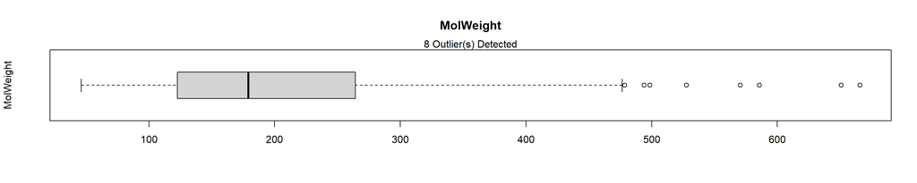

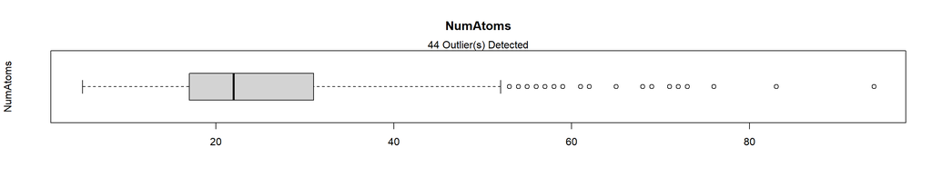

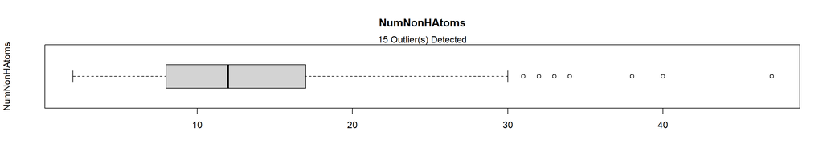

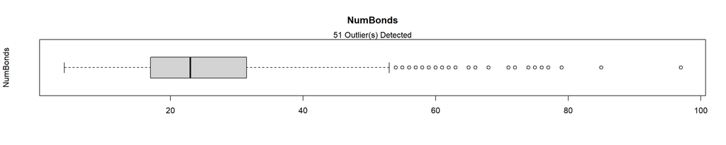

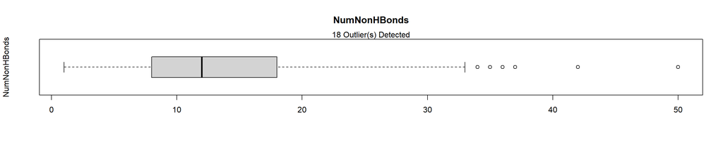

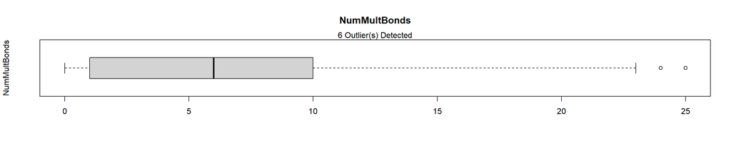

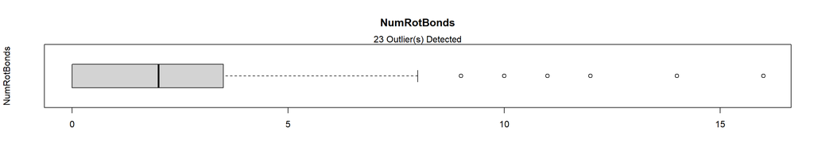

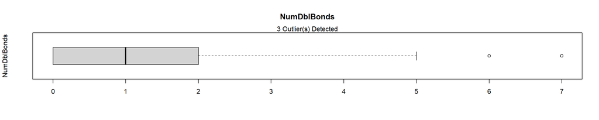

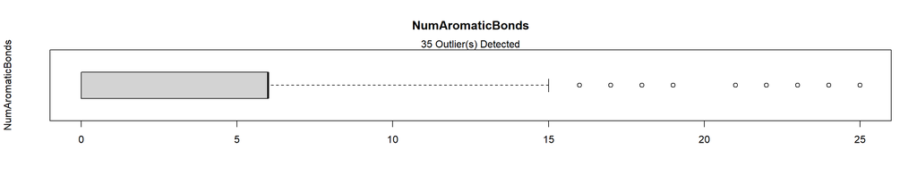

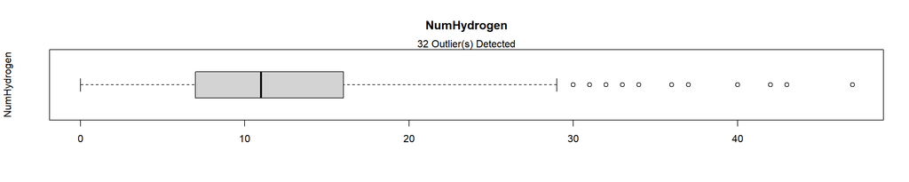

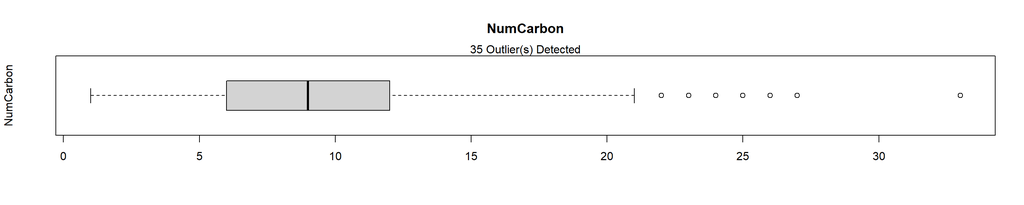

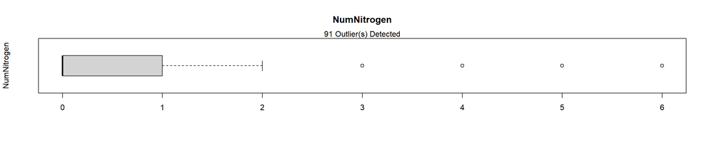

[8 more figures not shown]

```r
##################################
# Loading dataset
##################################
DPA <- Solubility_Train

##################################
# Listing all predictors
##################################
DPA.Predictors <- DPA[,!names(DPA) %in% c("Log_Solubility_Class")]

##################################
# Listing all numeric predictors
##################################
DPA.Predictors.Numeric <- DPA.Predictors[,-(grep("FP", names(DPA.Predictors)))]

##################################
# Identifying outliers for the numeric predictors
##################################
OutlierCountList <- c()

for (i in 1:ncol(DPA.Predictors.Numeric)) {
  Outliers <- boxplot.stats(DPA.Predictors.Numeric[,i])$out
  OutlierCount <- length(Outliers)
  OutlierCountList <- append(OutlierCountList,OutlierCount)
  OutlierIndices <- which(DPA.Predictors.Numeric[,i] %in% c(Outliers))
  boxplot(DPA.Predictors.Numeric[,i],
          ylab = names(DPA.Predictors.Numeric)[i],
          main = names(DPA.Predictors.Numeric)[i],
          horizontal=TRUE)
  mtext(paste0(OutlierCount, " Outlier(s) Detected"))
}
```

```r
OutlierCountSummary <- as.data.frame(cbind(names(DPA.Predictors.Numeric),(OutlierCountList)))
names(OutlierCountSummary) <- c("NumericPredictors","OutlierCount")
OutlierCountSummary$OutlierCount <- as.numeric(as.character(OutlierCountSummary$OutlierCount))
NumericPredictorWithOutlierCount <- nrow(OutlierCountSummary[OutlierCountSummary$OutlierCount>0,])
print(paste0(NumericPredictorWithOutlierCount, " numeric variable(s) were noted with outlier(s)." ))
```

```
## [1] "20 numeric variable(s) were noted with outlier(s)."
```

```r
##################################
# Gathering descriptive statistics
##################################
(DPA_Skimmed <- skim(DPA.Predictors.Numeric))
```

Data summary

| Name | DPA.Predictors.Numeric |
| --- | --- |
| Number of rows | 951 |
| Number of columns | 20 |
| _______________________ |  |
| Column type frequency: |  |
| numeric | 20 |
| ________________________ |  |
| Group variables | None |

**Variable type: numeric**

| skim_variable | n_missing | complete_rate | mean | sd | p0 | p25 | p50 | p75 | p100 | hist |
| --- | --- | --- | --- | --- | --- | --- | --- | --- | --- | --- |
| MolWeight | 0 | 1 | 201.65 | 97.91 | 46.09 | 122.60 | 179.23 | 264.34 | 665.81 | ▇▆▂▁▁ |
| NumAtoms | 0 | 1 | 25.51 | 12.61 | 5.00 | 17.00 | 22.00 | 31.00 | 94.00 | ▇▆▂▁▁ |
| NumNonHAtoms | 0 | 1 | 13.16 | 6.50 | 2.00 | 8.00 | 12.00 | 17.00 | 47.00 | ▇▆▂▁▁ |
| NumBonds | 0 | 1 | 25.91 | 13.48 | 4.00 | 17.00 | 23.00 | 31.50 | 97.00 | ▇▇▂▁▁ |
| NumNonHBonds | 0 | 1 | 13.56 | 7.57 | 1.00 | 8.00 | 12.00 | 18.00 | 50.00 | ▇▇▂▁▁ |
| NumMultBonds | 0 | 1 | 6.15 | 5.17 | 0.00 | 1.00 | 6.00 | 10.00 | 25.00 | ▇▆▃▁▁ |
| NumRotBonds | 0 | 1 | 2.25 | 2.41 | 0.00 | 0.00 | 2.00 | 3.50 | 16.00 | ▇▂▁▁▁ |
| NumDblBonds | 0 | 1 | 1.01 | 1.21 | 0.00 | 0.00 | 1.00 | 2.00 | 7.00 | ▇▂▁▁▁ |
| NumAromaticBonds | 0 | 1 | 5.12 | 5.26 | 0.00 | 0.00 | 6.00 | 6.00 | 25.00 | ▇▆▃▁▁ |
| NumHydrogen | 0 | 1 | 12.35 | 7.32 | 0.00 | 7.00 | 11.00 | 16.00 | 47.00 | ▇▇▂▁▁ |
| NumCarbon | 0 | 1 | 9.89 | 5.29 | 1.00 | 6.00 | 9.00 | 12.00 | 33.00 | ▇▇▃▁▁ |
| NumNitrogen | 0 | 1 | 0.81 | 1.19 | 0.00 | 0.00 | 0.00 | 1.00 | 6.00 | ▇▂▁▁▁ |
| NumOxygen | 0 | 1 | 1.57 | 1.73 | 0.00 | 0.00 | 1.00 | 2.00 | 13.00 | ▇▂▁▁▁ |
| NumSulfer | 0 | 1 | 0.16 | 0.49 | 0.00 | 0.00 | 0.00 | 0.00 | 4.00 | ▇▁▁▁▁ |
| NumChlorine | 0 | 1 | 0.56 | 1.40 | 0.00 | 0.00 | 0.00 | 0.00 | 10.00 | ▇▁▁▁▁ |
| NumHalogen | 0 | 1 | 0.70 | 1.47 | 0.00 | 0.00 | 0.00 | 1.00 | 10.00 | ▇▁▁▁▁ |
| NumRings | 0 | 1 | 1.40 | 1.30 | 0.00 | 0.00 | 1.00 | 2.00 | 7.00 | ▇▃▂▁▁ |
| HydrophilicFactor | 0 | 1 | -0.02 | 1.13 | -0.98 | -0.76 | -0.31 | 0.31 | 13.48 | ▇▁▁▁▁ |
| SurfaceArea1 | 0 | 1 | 36.46 | 35.29 | 0.00 | 9.23 | 29.10 | 53.28 | 331.94 | ▇▂▁▁▁ |
| SurfaceArea2 | 0 | 1 | 40.23 | 38.12 | 0.00 | 10.63 | 33.12 | 60.66 | 331.94 | ▇▂▁▁▁ |

```r
###################################
# Verifying the data dimensions
###################################
dim(DPA.Predictors.Numeric)
```

```
## [1] 951  20
```

### 1.3.2 Zero and Near-Zero Variance

**[A]** Low variance noted for 127 variables from the previous data quality assessment using a lower threshold.  
**[B]** Low variance noted for 3 variables using a preprocessing summary from the **caret** package. The nearZeroVar method using both the freqCut and uniqueCut criteria set at 95/5 and 10, respectively, were applied on the dataset.  
**[B.1]** FP154 variable (factor)  
**[B.2]** FP199 variable (factor)  
**[B.3]** FP200 variable (factor)

**Code Chunk | Output**

```r
##################################
# Loading dataset
##################################
DPA <- Solubility_Train

##################################
# Gathering descriptive statistics
##################################
(DPA_Skimmed <- skim(DPA))
```

Data summary

| Name | DPA |
| --- | --- |
| Number of rows | 951 |
| Number of columns | 229 |
| _______________________ |  |
| Column type frequency: |  |
| factor | 1 |
| numeric | 228 |
| ________________________ |  |
| Group variables | None |

**Variable type: factor**

| skim_variable | n_missing | complete_rate | ordered | n_unique | top_counts |
| --- | --- | --- | --- | --- | --- |
| Log_Solubility_Class | 0 | 1 | FALSE | 2 | Hig: 524, Low: 427 |

**Variable type: numeric**

| skim_variable | n_missing | complete_rate | mean | sd | p0 | p25 | p50 | p75 | p100 | hist |
| --- | --- | --- | --- | --- | --- | --- | --- | --- | --- | --- |
| FP001 | 0 | 1 | 0.49 | 0.50 | 0.00 | 0.00 | 0.00 | 1.00 | 1.00 | ▇▁▁▁▇ |
| FP002 | 0 | 1 | 0.54 | 0.50 | 0.00 | 0.00 | 1.00 | 1.00 | 1.00 | ▇▁▁▁▇ |
| FP003 | 0 | 1 | 0.44 | 0.50 | 0.00 | 0.00 | 0.00 | 1.00 | 1.00 | ▇▁▁▁▆ |
| FP004 | 0 | 1 | 0.58 | 0.49 | 0.00 | 0.00 | 1.00 | 1.00 | 1.00 | ▆▁▁▁▇ |
| FP005 | 0 | 1 | 0.58 | 0.49 | 0.00 | 0.00 | 1.00 | 1.00 | 1.00 | ▆▁▁▁▇ |
| FP006 | 0 | 1 | 0.40 | 0.49 | 0.00 | 0.00 | 0.00 | 1.00 | 1.00 | ▇▁▁▁▆ |
| FP007 | 0 | 1 | 0.36 | 0.48 | 0.00 | 0.00 | 0.00 | 1.00 | 1.00 | ▇▁▁▁▅ |
| FP008 | 0 | 1 | 0.33 | 0.47 | 0.00 | 0.00 | 0.00 | 1.00 | 1.00 | ▇▁▁▁▃ |
| FP009 | 0 | 1 | 0.28 | 0.45 | 0.00 | 0.00 | 0.00 | 1.00 | 1.00 | ▇▁▁▁▃ |
| FP010 | 0 | 1 | 0.18 | 0.38 | 0.00 | 0.00 | 0.00 | 0.00 | 1.00 | ▇▁▁▁▂ |
| FP011 | 0 | 1 | 0.21 | 0.41 | 0.00 | 0.00 | 0.00 | 0.00 | 1.00 | ▇▁▁▁▂ |
| FP012 | 0 | 1 | 0.18 | 0.38 | 0.00 | 0.00 | 0.00 | 0.00 | 1.00 | ▇▁▁▁▂ |
| FP013 | 0 | 1 | 0.17 | 0.37 | 0.00 | 0.00 | 0.00 | 0.00 | 1.00 | ▇▁▁▁▂ |
| FP014 | 0 | 1 | 0.16 | 0.37 | 0.00 | 0.00 | 0.00 | 0.00 | 1.00 | ▇▁▁▁▂ |
| FP015 | 0 | 1 | 0.86 | 0.35 | 0.00 | 1.00 | 1.00 | 1.00 | 1.00 | ▁▁▁▁▇ |
| FP016 | 0 | 1 | 0.15 | 0.35 | 0.00 | 0.00 | 0.00 | 0.00 | 1.00 | ▇▁▁▁▂ |
| FP017 | 0 | 1 | 0.14 | 0.35 | 0.00 | 0.00 | 0.00 | 0.00 | 1.00 | ▇▁▁▁▂ |
| FP018 | 0 | 1 | 0.13 | 0.34 | 0.00 | 0.00 | 0.00 | 0.00 | 1.00 | ▇▁▁▁▁ |
| FP019 | 0 | 1 | 0.12 | 0.33 | 0.00 | 0.00 | 0.00 | 0.00 | 1.00 | ▇▁▁▁▁ |
| FP020 | 0 | 1 | 0.12 | 0.32 | 0.00 | 0.00 | 0.00 | 0.00 | 1.00 | ▇▁▁▁▁ |
| FP021 | 0 | 1 | 0.12 | 0.33 | 0.00 | 0.00 | 0.00 | 0.00 | 1.00 | ▇▁▁▁▁ |
| FP022 | 0 | 1 | 0.10 | 0.31 | 0.00 | 0.00 | 0.00 | 0.00 | 1.00 | ▇▁▁▁▁ |
| FP023 | 0 | 1 | 0.12 | 0.33 | 0.00 | 0.00 | 0.00 | 0.00 | 1.00 | ▇▁▁▁▁ |
| FP024 | 0 | 1 | 0.11 | 0.32 | 0.00 | 0.00 | 0.00 | 0.00 | 1.00 | ▇▁▁▁▁ |
| FP025 | 0 | 1 | 0.12 | 0.32 | 0.00 | 0.00 | 0.00 | 0.00 | 1.00 | ▇▁▁▁▁ |
| FP026 | 0 | 1 | 0.08 | 0.28 | 0.00 | 0.00 | 0.00 | 0.00 | 1.00 | ▇▁▁▁▁ |
| FP027 | 0 | 1 | 0.10 | 0.30 | 0.00 | 0.00 | 0.00 | 0.00 | 1.00 | ▇▁▁▁▁ |
| FP028 | 0 | 1 | 0.11 | 0.31 | 0.00 | 0.00 | 0.00 | 0.00 | 1.00 | ▇▁▁▁▁ |
| FP029 | 0 | 1 | 0.10 | 0.30 | 0.00 | 0.00 | 0.00 | 0.00 | 1.00 | ▇▁▁▁▁ |
| FP030 | 0 | 1 | 0.09 | 0.29 | 0.00 | 0.00 | 0.00 | 0.00 | 1.00 | ▇▁▁▁▁ |

[output cut: 198 more lines]

```r
##################################
# Identifying columns with low variance
###################################
DPA_LowVariance <- nearZeroVar(DPA,
                               freqCut = 95/5,
                               uniqueCut = 10,
                               saveMetrics= TRUE)
(DPA_LowVariance[DPA_LowVariance$nzv,])
```

```
##       freqRatio percentUnique zeroVar  nzv
## FP154  25.41667     0.2103049   FALSE TRUE
## FP199  20.13333     0.2103049   FALSE TRUE
## FP200  19.23404     0.2103049   FALSE TRUE
```

```r
if ((nrow(DPA_LowVariance[DPA_LowVariance$nzv,]))==0){

  print("No low variance predictors noted.")

} else {

  print(paste0("Low variance observed for ",
               (nrow(DPA_LowVariance[DPA_LowVariance$nzv,])),
               " numeric variable(s) with First.Second.Mode.Ratio>4 and Unique.Count.Ratio<0.10."))

  DPA_LowVarianceForRemoval <- (nrow(DPA_LowVariance[DPA_LowVariance$nzv,]))

  print(paste0("Low variance can be resolved by removing ",
               (nrow(DPA_LowVariance[DPA_LowVariance$nzv,])),
               " numeric variable(s)."))

  for (j in 1:DPA_LowVarianceForRemoval) {
  DPA_LowVarianceRemovedVariable <- rownames(DPA_LowVariance[DPA_LowVariance$nzv,])[j]
  print(paste0("Variable ",
               j,
               " for removal: ",
               DPA_LowVarianceRemovedVariable))
  }

  DPA %>%
  skim() %>%
  dplyr::filter(skim_variable %in% rownames(DPA_LowVariance[DPA_LowVariance$nzv,]))

  ##################################
  # Filtering out columns with low variance
  #################################
  DPA_ExcludedLowVariance <- DPA[,!names(DPA) %in% rownames(DPA_LowVariance[DPA_LowVariance$nzv,])]

  ##################################
  # Gathering descriptive statistics
  ##################################
  (DPA_ExcludedLowVariance_Skimmed <- skim(DPA_ExcludedLowVariance))
}
```

```
## [1] "Low variance observed for 3 numeric variable(s) with First.Second.Mode.Ratio>4 and Unique.Count.Ratio<0.10."
## [1] "Low variance can be resolved by removing 3 numeric variable(s)."
## [1] "Variable 1 for removal: FP154"
## [1] "Variable 2 for removal: FP199"
## [1] "Variable 3 for removal: FP200"
```

Data summary

| Name | DPA_ExcludedLowVariance |
| --- | --- |
| Number of rows | 951 |
| Number of columns | 226 |
| _______________________ |  |
| Column type frequency: |  |
| factor | 1 |
| numeric | 225 |
| ________________________ |  |
| Group variables | None |

**Variable type: factor**

| skim_variable | n_missing | complete_rate | ordered | n_unique | top_counts |
| --- | --- | --- | --- | --- | --- |
| Log_Solubility_Class | 0 | 1 | FALSE | 2 | Hig: 524, Low: 427 |

**Variable type: numeric**

| skim_variable | n_missing | complete_rate | mean | sd | p0 | p25 | p50 | p75 | p100 | hist |
| --- | --- | --- | --- | --- | --- | --- | --- | --- | --- | --- |
| FP001 | 0 | 1 | 0.49 | 0.50 | 0.00 | 0.00 | 0.00 | 1.00 | 1.00 | ▇▁▁▁▇ |
| FP002 | 0 | 1 | 0.54 | 0.50 | 0.00 | 0.00 | 1.00 | 1.00 | 1.00 | ▇▁▁▁▇ |
| FP003 | 0 | 1 | 0.44 | 0.50 | 0.00 | 0.00 | 0.00 | 1.00 | 1.00 | ▇▁▁▁▆ |
| FP004 | 0 | 1 | 0.58 | 0.49 | 0.00 | 0.00 | 1.00 | 1.00 | 1.00 | ▆▁▁▁▇ |
| FP005 | 0 | 1 | 0.58 | 0.49 | 0.00 | 0.00 | 1.00 | 1.00 | 1.00 | ▆▁▁▁▇ |
| FP006 | 0 | 1 | 0.40 | 0.49 | 0.00 | 0.00 | 0.00 | 1.00 | 1.00 | ▇▁▁▁▆ |
| FP007 | 0 | 1 | 0.36 | 0.48 | 0.00 | 0.00 | 0.00 | 1.00 | 1.00 | ▇▁▁▁▅ |
| FP008 | 0 | 1 | 0.33 | 0.47 | 0.00 | 0.00 | 0.00 | 1.00 | 1.00 | ▇▁▁▁▃ |
| FP009 | 0 | 1 | 0.28 | 0.45 | 0.00 | 0.00 | 0.00 | 1.00 | 1.00 | ▇▁▁▁▃ |
| FP010 | 0 | 1 | 0.18 | 0.38 | 0.00 | 0.00 | 0.00 | 0.00 | 1.00 | ▇▁▁▁▂ |
| FP011 | 0 | 1 | 0.21 | 0.41 | 0.00 | 0.00 | 0.00 | 0.00 | 1.00 | ▇▁▁▁▂ |
| FP012 | 0 | 1 | 0.18 | 0.38 | 0.00 | 0.00 | 0.00 | 0.00 | 1.00 | ▇▁▁▁▂ |
| FP013 | 0 | 1 | 0.17 | 0.37 | 0.00 | 0.00 | 0.00 | 0.00 | 1.00 | ▇▁▁▁▂ |
| FP014 | 0 | 1 | 0.16 | 0.37 | 0.00 | 0.00 | 0.00 | 0.00 | 1.00 | ▇▁▁▁▂ |
| FP015 | 0 | 1 | 0.86 | 0.35 | 0.00 | 1.00 | 1.00 | 1.00 | 1.00 | ▁▁▁▁▇ |
| FP016 | 0 | 1 | 0.15 | 0.35 | 0.00 | 0.00 | 0.00 | 0.00 | 1.00 | ▇▁▁▁▂ |
| FP017 | 0 | 1 | 0.14 | 0.35 | 0.00 | 0.00 | 0.00 | 0.00 | 1.00 | ▇▁▁▁▂ |
| FP018 | 0 | 1 | 0.13 | 0.34 | 0.00 | 0.00 | 0.00 | 0.00 | 1.00 | ▇▁▁▁▁ |
| FP019 | 0 | 1 | 0.12 | 0.33 | 0.00 | 0.00 | 0.00 | 0.00 | 1.00 | ▇▁▁▁▁ |
| FP020 | 0 | 1 | 0.12 | 0.32 | 0.00 | 0.00 | 0.00 | 0.00 | 1.00 | ▇▁▁▁▁ |
| FP021 | 0 | 1 | 0.12 | 0.33 | 0.00 | 0.00 | 0.00 | 0.00 | 1.00 | ▇▁▁▁▁ |
| FP022 | 0 | 1 | 0.10 | 0.31 | 0.00 | 0.00 | 0.00 | 0.00 | 1.00 | ▇▁▁▁▁ |
| FP023 | 0 | 1 | 0.12 | 0.33 | 0.00 | 0.00 | 0.00 | 0.00 | 1.00 | ▇▁▁▁▁ |
| FP024 | 0 | 1 | 0.11 | 0.32 | 0.00 | 0.00 | 0.00 | 0.00 | 1.00 | ▇▁▁▁▁ |
| FP025 | 0 | 1 | 0.12 | 0.32 | 0.00 | 0.00 | 0.00 | 0.00 | 1.00 | ▇▁▁▁▁ |
| FP026 | 0 | 1 | 0.08 | 0.28 | 0.00 | 0.00 | 0.00 | 0.00 | 1.00 | ▇▁▁▁▁ |
| FP027 | 0 | 1 | 0.10 | 0.30 | 0.00 | 0.00 | 0.00 | 0.00 | 1.00 | ▇▁▁▁▁ |
| FP028 | 0 | 1 | 0.11 | 0.31 | 0.00 | 0.00 | 0.00 | 0.00 | 1.00 | ▇▁▁▁▁ |
| FP029 | 0 | 1 | 0.10 | 0.30 | 0.00 | 0.00 | 0.00 | 0.00 | 1.00 | ▇▁▁▁▁ |
| FP030 | 0 | 1 | 0.09 | 0.29 | 0.00 | 0.00 | 0.00 | 0.00 | 1.00 | ▇▁▁▁▁ |

[output cut: 195 more lines]

```r
###################################
# Verifying the data dimensions
###################################
dim(DPA_ExcludedLowVariance)
```

```
## [1] 951 226
```

### 1.3.3 Collinearity

**Code Chunk | Output**

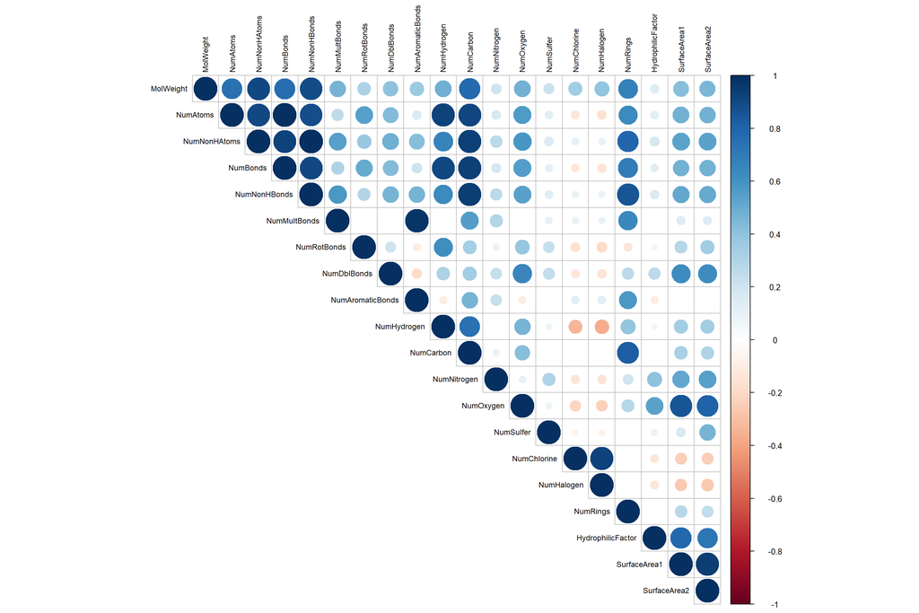

```r
##################################
# Loading dataset
##################################
DPA <- Solubility_Train

##################################
# Listing all predictors
##################################
DPA.Predictors <- DPA[,!names(DPA) %in% c("Log_Solubility_Class")]

##################################
# Listing all numeric predictors
##################################
DPA.Predictors.Numeric <- DPA.Predictors[,-(grep("FP", names(DPA.Predictors)))]

##################################
# Visualizing pairwise correlation between predictors
##################################
DPA_CorrelationTest <- cor.mtest(DPA.Predictors.Numeric,
                       method = "pearson",
                       conf.level = .95)

corrplot(cor(DPA.Predictors.Numeric,
             method = "pearson",
             use="pairwise.complete.obs"),
         method = "circle",
         type = "upper",
         order = "original",
         tl.col = "black",
         tl.cex = 0.75,
         tl.srt = 90,
         sig.level = 0.05,
         p.mat = DPA_CorrelationTest$p,
         insig = "blank")
```

```r
##################################
# Identifying the highly correlated variables
##################################
DPA_Correlation <-  cor(DPA.Predictors.Numeric,
                        method = "pearson",
                        use="pairwise.complete.obs")
(DPA_HighlyCorrelatedCount <- sum(abs(DPA_Correlation[upper.tri(DPA_Correlation)]) > 0.95))
```

```
## [1] 3
```

```
## [1] "High correlation observed for 3 pairs of numeric variable(s) with Correlation.Coefficient>0.95."
```

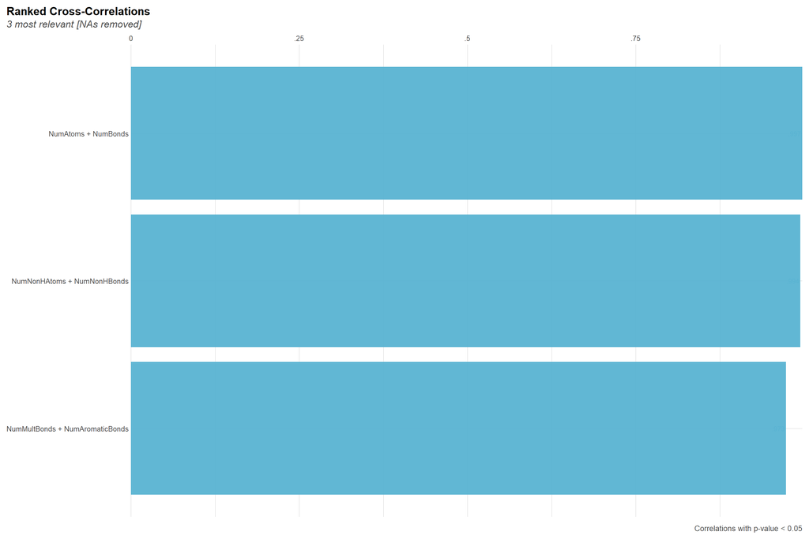

```r
if (DPA_HighlyCorrelatedCount == 0) {
  print("No highly correlated predictors noted.")
} else {
  print(paste0("High correlation observed for ",
               (DPA_HighlyCorrelatedCount),
               " pairs of numeric variable(s) with Correlation.Coefficient>0.95."))

  (DPA_HighlyCorrelatedPairs <- corr_cross(DPA.Predictors.Numeric,
  max_pvalue = 0.05,
  top = DPA_HighlyCorrelatedCount,
  rm.na = TRUE,
  grid = FALSE
))

}
```

```r
if (DPA_HighlyCorrelatedCount > 0) {
  DPA_HighlyCorrelated <- findCorrelation(DPA_Correlation, cutoff = 0.95)

  (DPA_HighlyCorrelatedForRemoval <- length(DPA_HighlyCorrelated))

  print(paste0("High correlation can be resolved by removing ",
               (DPA_HighlyCorrelatedForRemoval),
               " numeric variable(s)."))

  for (j in 1:DPA_HighlyCorrelatedForRemoval) {
  DPA_HighlyCorrelatedRemovedVariable <- colnames(DPA.Predictors.Numeric)[DPA_HighlyCorrelated[j]]
  print(paste0("Variable ",
               j,
               " for removal: ",
               DPA_HighlyCorrelatedRemovedVariable))
  }

  ##################################
  # Filtering out columns with high correlation
  #################################
  DPA_ExcludedHighCorrelation <- DPA[,-DPA_HighlyCorrelated]

  ##################################
  # Gathering descriptive statistics
  ##################################
  (DPA_ExcludedHighCorrelation_Skimmed <- skim(DPA_ExcludedHighCorrelation))

}
```

```
## [1] "High correlation can be resolved by removing 3 numeric variable(s)."
## [1] "Variable 1 for removal: NumNonHAtoms"
## [1] "Variable 2 for removal: NumBonds"
## [1] "Variable 3 for removal: NumAromaticBonds"
```

Data summary

| Name | DPA_ExcludedHighCorrelati… |
| --- | --- |
| Number of rows | 951 |
| Number of columns | 226 |
| _______________________ |  |
| Column type frequency: |  |
| factor | 1 |
| numeric | 225 |
| ________________________ |  |
| Group variables | None |

**Variable type: factor**

| skim_variable | n_missing | complete_rate | ordered | n_unique | top_counts |
| --- | --- | --- | --- | --- | --- |
| Log_Solubility_Class | 0 | 1 | FALSE | 2 | Hig: 524, Low: 427 |

**Variable type: numeric**

| skim_variable | n_missing | complete_rate | mean | sd | p0 | p25 | p50 | p75 | p100 | hist |
| --- | --- | --- | --- | --- | --- | --- | --- | --- | --- | --- |
| FP001 | 0 | 1 | 0.49 | 0.50 | 0.00 | 0.00 | 0.00 | 1.00 | 1.00 | ▇▁▁▁▇ |
| FP002 | 0 | 1 | 0.54 | 0.50 | 0.00 | 0.00 | 1.00 | 1.00 | 1.00 | ▇▁▁▁▇ |
| FP005 | 0 | 1 | 0.58 | 0.49 | 0.00 | 0.00 | 1.00 | 1.00 | 1.00 | ▆▁▁▁▇ |
| FP006 | 0 | 1 | 0.40 | 0.49 | 0.00 | 0.00 | 0.00 | 1.00 | 1.00 | ▇▁▁▁▆ |
| FP007 | 0 | 1 | 0.36 | 0.48 | 0.00 | 0.00 | 0.00 | 1.00 | 1.00 | ▇▁▁▁▅ |
| FP008 | 0 | 1 | 0.33 | 0.47 | 0.00 | 0.00 | 0.00 | 1.00 | 1.00 | ▇▁▁▁▃ |
| FP010 | 0 | 1 | 0.18 | 0.38 | 0.00 | 0.00 | 0.00 | 0.00 | 1.00 | ▇▁▁▁▂ |
| FP011 | 0 | 1 | 0.21 | 0.41 | 0.00 | 0.00 | 0.00 | 0.00 | 1.00 | ▇▁▁▁▂ |
| FP012 | 0 | 1 | 0.18 | 0.38 | 0.00 | 0.00 | 0.00 | 0.00 | 1.00 | ▇▁▁▁▂ |
| FP013 | 0 | 1 | 0.17 | 0.37 | 0.00 | 0.00 | 0.00 | 0.00 | 1.00 | ▇▁▁▁▂ |
| FP014 | 0 | 1 | 0.16 | 0.37 | 0.00 | 0.00 | 0.00 | 0.00 | 1.00 | ▇▁▁▁▂ |
| FP015 | 0 | 1 | 0.86 | 0.35 | 0.00 | 1.00 | 1.00 | 1.00 | 1.00 | ▁▁▁▁▇ |
| FP016 | 0 | 1 | 0.15 | 0.35 | 0.00 | 0.00 | 0.00 | 0.00 | 1.00 | ▇▁▁▁▂ |
| FP017 | 0 | 1 | 0.14 | 0.35 | 0.00 | 0.00 | 0.00 | 0.00 | 1.00 | ▇▁▁▁▂ |
| FP018 | 0 | 1 | 0.13 | 0.34 | 0.00 | 0.00 | 0.00 | 0.00 | 1.00 | ▇▁▁▁▁ |
| FP019 | 0 | 1 | 0.12 | 0.33 | 0.00 | 0.00 | 0.00 | 0.00 | 1.00 | ▇▁▁▁▁ |
| FP020 | 0 | 1 | 0.12 | 0.32 | 0.00 | 0.00 | 0.00 | 0.00 | 1.00 | ▇▁▁▁▁ |
| FP021 | 0 | 1 | 0.12 | 0.33 | 0.00 | 0.00 | 0.00 | 0.00 | 1.00 | ▇▁▁▁▁ |
| FP022 | 0 | 1 | 0.10 | 0.31 | 0.00 | 0.00 | 0.00 | 0.00 | 1.00 | ▇▁▁▁▁ |
| FP023 | 0 | 1 | 0.12 | 0.33 | 0.00 | 0.00 | 0.00 | 0.00 | 1.00 | ▇▁▁▁▁ |
| FP024 | 0 | 1 | 0.11 | 0.32 | 0.00 | 0.00 | 0.00 | 0.00 | 1.00 | ▇▁▁▁▁ |
| FP025 | 0 | 1 | 0.12 | 0.32 | 0.00 | 0.00 | 0.00 | 0.00 | 1.00 | ▇▁▁▁▁ |
| FP026 | 0 | 1 | 0.08 | 0.28 | 0.00 | 0.00 | 0.00 | 0.00 | 1.00 | ▇▁▁▁▁ |
| FP027 | 0 | 1 | 0.10 | 0.30 | 0.00 | 0.00 | 0.00 | 0.00 | 1.00 | ▇▁▁▁▁ |
| FP028 | 0 | 1 | 0.11 | 0.31 | 0.00 | 0.00 | 0.00 | 0.00 | 1.00 | ▇▁▁▁▁ |
| FP029 | 0 | 1 | 0.10 | 0.30 | 0.00 | 0.00 | 0.00 | 0.00 | 1.00 | ▇▁▁▁▁ |
| FP030 | 0 | 1 | 0.09 | 0.29 | 0.00 | 0.00 | 0.00 | 0.00 | 1.00 | ▇▁▁▁▁ |
| FP031 | 0 | 1 | 0.09 | 0.29 | 0.00 | 0.00 | 0.00 | 0.00 | 1.00 | ▇▁▁▁▁ |
| FP032 | 0 | 1 | 0.07 | 0.26 | 0.00 | 0.00 | 0.00 | 0.00 | 1.00 | ▇▁▁▁▁ |
| FP033 | 0 | 1 | 0.07 | 0.25 | 0.00 | 0.00 | 0.00 | 0.00 | 1.00 | ▇▁▁▁▁ |

[output cut: 195 more lines]

```r
###################################
# Verifying the data dimensions
###################################
dim(DPA_ExcludedHighCorrelation)
```

```
## [1] 951 226
```

### 1.3.4 Linear Dependencies

**[A]** Linear dependencies noted for 2 subsets of variables using the preprocessing summary from the **caret** package applying the findLinearCombos method which utilizes the QR decomposition of a matrix to enumerate sets of linear combinations (if they exist).  
**[B]** Subset 1  
**[B.1]** NumNonHBonds variable (numeric)  
**[B.2]** NumAtoms variable (numeric)  
**[B.3]** NumNonHAtoms variable (numeric)  
**[B.3]** NumBonds variable (numeric)  
**[C]** Subset 2  
**[C.1]** NumHydrogen variable (numeric)  
**[C.2]** NumAtoms variable (numeric)  
**[C.3]** NumNonHAtoms variable (numeric)

**Code Chunk | Output**

```r
##################################
# Loading dataset
##################################
DPA <- Solubility_Train

##################################
# Listing all predictors
##################################
DPA.Predictors <- DPA[,!names(DPA) %in% c("Log_Solubility_Class")]

##################################
# Listing all numeric predictors
##################################
DPA.Predictors.Numeric <- DPA.Predictors[,sapply(DPA.Predictors, is.numeric)]

##################################
# Identifying the linearly dependent variables
##################################
DPA_LinearlyDependent <- findLinearCombos(DPA.Predictors.Numeric)

(DPA_LinearlyDependentCount <- length(DPA_LinearlyDependent$linearCombos))
```

```
## [1] 2
```

```r
if (DPA_LinearlyDependentCount == 0) {
  print("No linearly dependent predictors noted.")
} else {
  print(paste0("Linear dependency observed for ",
               (DPA_LinearlyDependentCount),
               " subset(s) of numeric variable(s)."))

  for (i in 1:DPA_LinearlyDependentCount) {
    DPA_LinearlyDependentSubset <- colnames(DPA.Predictors.Numeric)[DPA_LinearlyDependent$linearCombos[[i]]]
    print(paste0("Linear dependent variable(s) for subset ",
                 i,
                 " include: ",
                 DPA_LinearlyDependentSubset))
  }

}
```

```
## [1] "Linear dependency observed for 2 subset(s) of numeric variable(s)."
## [1] "Linear dependent variable(s) for subset 1 include: NumNonHBonds"
## [2] "Linear dependent variable(s) for subset 1 include: NumAtoms"
## [3] "Linear dependent variable(s) for subset 1 include: NumNonHAtoms"
## [4] "Linear dependent variable(s) for subset 1 include: NumBonds"
## [1] "Linear dependent variable(s) for subset 2 include: NumHydrogen"
## [2] "Linear dependent variable(s) for subset 2 include: NumAtoms"
## [3] "Linear dependent variable(s) for subset 2 include: NumNonHAtoms"
```

```r
##################################
# Identifying the linearly dependent variables for removal
##################################

if (DPA_LinearlyDependentCount > 0) {
  DPA_LinearlyDependent <- findLinearCombos(DPA.Predictors.Numeric)

  DPA_LinearlyDependentForRemoval <- length(DPA_LinearlyDependent$remove)

  print(paste0("Linear dependency can be resolved by removing ",
               (DPA_LinearlyDependentForRemoval),
               " numeric variable(s)."))

  for (j in 1:DPA_LinearlyDependentForRemoval) {
  DPA_LinearlyDependentRemovedVariable <- colnames(DPA.Predictors.Numeric)[DPA_LinearlyDependent$remove[j]]
  print(paste0("Variable ",
               j,
               " for removal: ",
               DPA_LinearlyDependentRemovedVariable))
  }

  ##################################
  # Filtering out columns with linear dependency
  #################################
  DPA_ExcludedLinearlyDependent <- DPA[,-DPA_LinearlyDependent$remove]

  ##################################
  # Gathering descriptive statistics
  ##################################
  (DPA_ExcludedLinearlyDependent_Skimmed <- skim(DPA_ExcludedLinearlyDependent))

}
```

```
## [1] "Linear dependency can be resolved by removing 2 numeric variable(s)."
## [1] "Variable 1 for removal: NumNonHBonds"
## [1] "Variable 2 for removal: NumHydrogen"
```

Data summary

| Name | DPA_ExcludedLinearlyDepen… |
| --- | --- |
| Number of rows | 951 |
| Number of columns | 227 |
| _______________________ |  |
| Column type frequency: |  |
| factor | 1 |
| numeric | 226 |
| ________________________ |  |
| Group variables | None |

**Variable type: factor**

| skim_variable | n_missing | complete_rate | ordered | n_unique | top_counts |
| --- | --- | --- | --- | --- | --- |
| Log_Solubility_Class | 0 | 1 | FALSE | 2 | Hig: 524, Low: 427 |

**Variable type: numeric**

| skim_variable | n_missing | complete_rate | mean | sd | p0 | p25 | p50 | p75 | p100 | hist |
| --- | --- | --- | --- | --- | --- | --- | --- | --- | --- | --- |
| FP001 | 0 | 1 | 0.49 | 0.50 | 0.00 | 0.00 | 0.00 | 1.00 | 1.00 | ▇▁▁▁▇ |
| FP002 | 0 | 1 | 0.54 | 0.50 | 0.00 | 0.00 | 1.00 | 1.00 | 1.00 | ▇▁▁▁▇ |
| FP003 | 0 | 1 | 0.44 | 0.50 | 0.00 | 0.00 | 0.00 | 1.00 | 1.00 | ▇▁▁▁▆ |
| FP004 | 0 | 1 | 0.58 | 0.49 | 0.00 | 0.00 | 1.00 | 1.00 | 1.00 | ▆▁▁▁▇ |
| FP005 | 0 | 1 | 0.58 | 0.49 | 0.00 | 0.00 | 1.00 | 1.00 | 1.00 | ▆▁▁▁▇ |
| FP006 | 0 | 1 | 0.40 | 0.49 | 0.00 | 0.00 | 0.00 | 1.00 | 1.00 | ▇▁▁▁▆ |
| FP007 | 0 | 1 | 0.36 | 0.48 | 0.00 | 0.00 | 0.00 | 1.00 | 1.00 | ▇▁▁▁▅ |
| FP008 | 0 | 1 | 0.33 | 0.47 | 0.00 | 0.00 | 0.00 | 1.00 | 1.00 | ▇▁▁▁▃ |
| FP009 | 0 | 1 | 0.28 | 0.45 | 0.00 | 0.00 | 0.00 | 1.00 | 1.00 | ▇▁▁▁▃ |
| FP010 | 0 | 1 | 0.18 | 0.38 | 0.00 | 0.00 | 0.00 | 0.00 | 1.00 | ▇▁▁▁▂ |
| FP011 | 0 | 1 | 0.21 | 0.41 | 0.00 | 0.00 | 0.00 | 0.00 | 1.00 | ▇▁▁▁▂ |
| FP012 | 0 | 1 | 0.18 | 0.38 | 0.00 | 0.00 | 0.00 | 0.00 | 1.00 | ▇▁▁▁▂ |
| FP013 | 0 | 1 | 0.17 | 0.37 | 0.00 | 0.00 | 0.00 | 0.00 | 1.00 | ▇▁▁▁▂ |
| FP014 | 0 | 1 | 0.16 | 0.37 | 0.00 | 0.00 | 0.00 | 0.00 | 1.00 | ▇▁▁▁▂ |
| FP015 | 0 | 1 | 0.86 | 0.35 | 0.00 | 1.00 | 1.00 | 1.00 | 1.00 | ▁▁▁▁▇ |
| FP016 | 0 | 1 | 0.15 | 0.35 | 0.00 | 0.00 | 0.00 | 0.00 | 1.00 | ▇▁▁▁▂ |
| FP017 | 0 | 1 | 0.14 | 0.35 | 0.00 | 0.00 | 0.00 | 0.00 | 1.00 | ▇▁▁▁▂ |
| FP018 | 0 | 1 | 0.13 | 0.34 | 0.00 | 0.00 | 0.00 | 0.00 | 1.00 | ▇▁▁▁▁ |
| FP019 | 0 | 1 | 0.12 | 0.33 | 0.00 | 0.00 | 0.00 | 0.00 | 1.00 | ▇▁▁▁▁ |
| FP020 | 0 | 1 | 0.12 | 0.32 | 0.00 | 0.00 | 0.00 | 0.00 | 1.00 | ▇▁▁▁▁ |
| FP021 | 0 | 1 | 0.12 | 0.33 | 0.00 | 0.00 | 0.00 | 0.00 | 1.00 | ▇▁▁▁▁ |
| FP022 | 0 | 1 | 0.10 | 0.31 | 0.00 | 0.00 | 0.00 | 0.00 | 1.00 | ▇▁▁▁▁ |
| FP023 | 0 | 1 | 0.12 | 0.33 | 0.00 | 0.00 | 0.00 | 0.00 | 1.00 | ▇▁▁▁▁ |
| FP024 | 0 | 1 | 0.11 | 0.32 | 0.00 | 0.00 | 0.00 | 0.00 | 1.00 | ▇▁▁▁▁ |
| FP025 | 0 | 1 | 0.12 | 0.32 | 0.00 | 0.00 | 0.00 | 0.00 | 1.00 | ▇▁▁▁▁ |
| FP026 | 0 | 1 | 0.08 | 0.28 | 0.00 | 0.00 | 0.00 | 0.00 | 1.00 | ▇▁▁▁▁ |
| FP027 | 0 | 1 | 0.10 | 0.30 | 0.00 | 0.00 | 0.00 | 0.00 | 1.00 | ▇▁▁▁▁ |
| FP028 | 0 | 1 | 0.11 | 0.31 | 0.00 | 0.00 | 0.00 | 0.00 | 1.00 | ▇▁▁▁▁ |
| FP029 | 0 | 1 | 0.10 | 0.30 | 0.00 | 0.00 | 0.00 | 0.00 | 1.00 | ▇▁▁▁▁ |
| FP030 | 0 | 1 | 0.09 | 0.29 | 0.00 | 0.00 | 0.00 | 0.00 | 1.00 | ▇▁▁▁▁ |

[output cut: 196 more lines]

```r
###################################
# Verifying the data dimensions
###################################
dim(DPA_ExcludedLinearlyDependent)
```

```
## [1] 951 227
```

### 1.3.5 Shape Transformation

**Code Chunk | Output**

```r
##################################
# Loading dataset
##################################
DPA <- Solubility_Train

##################################
# Listing all predictors
##################################
DPA.Predictors <- DPA[,!names(DPA) %in% c("Log_Solubility_Class")]

##################################
# Listing all numeric predictors
##################################
DPA.Predictors.Numeric <- DPA.Predictors[,-(grep("FP", names(DPA.Predictors)))]

##################################
# Applying a Box-Cox transformation
##################################
DPA_BoxCox <- preProcess(DPA.Predictors.Numeric, method = c("BoxCox"))
DPA_BoxCoxTransformed <- predict(DPA_BoxCox, DPA.Predictors.Numeric)

##################################
# Gathering descriptive statistics
##################################
(DPA_BoxCoxTransformedSkimmed <- skim(DPA_BoxCoxTransformed))
```

Data summary

| Name | DPA_BoxCoxTransformed |
| --- | --- |
| Number of rows | 951 |
| Number of columns | 20 |
| _______________________ |  |
| Column type frequency: |  |
| numeric | 20 |
| ________________________ |  |
| Group variables | None |

**Variable type: numeric**

| skim_variable | n_missing | complete_rate | mean | sd | p0 | p25 | p50 | p75 | p100 | hist |
| --- | --- | --- | --- | --- | --- | --- | --- | --- | --- | --- |
| MolWeight | 0 | 1 | 5.19 | 0.48 | 3.83 | 4.81 | 5.19 | 5.58 | 6.50 | ▁▆▇▆▁ |
| NumAtoms | 0 | 1 | 3.13 | 0.48 | 1.61 | 2.83 | 3.09 | 3.43 | 4.54 | ▁▃▇▃▁ |
| NumNonHAtoms | 0 | 1 | 2.46 | 0.50 | 0.69 | 2.08 | 2.48 | 2.83 | 3.85 | ▁▃▇▇▁ |
| NumBonds | 0 | 1 | 4.39 | 0.96 | 1.60 | 3.81 | 4.36 | 4.97 | 7.48 | ▁▅▇▃▁ |
| NumNonHBonds | 0 | 1 | 3.21 | 0.95 | 0.00 | 2.58 | 3.22 | 3.91 | 5.93 | ▁▃▇▆▁ |
| NumMultBonds | 0 | 1 | 6.15 | 5.17 | 0.00 | 1.00 | 6.00 | 10.00 | 25.00 | ▇▆▃▁▁ |
| NumRotBonds | 0 | 1 | 2.25 | 2.41 | 0.00 | 0.00 | 2.00 | 3.50 | 16.00 | ▇▂▁▁▁ |
| NumDblBonds | 0 | 1 | 1.01 | 1.21 | 0.00 | 0.00 | 1.00 | 2.00 | 7.00 | ▇▂▁▁▁ |
| NumAromaticBonds | 0 | 1 | 5.12 | 5.26 | 0.00 | 0.00 | 6.00 | 6.00 | 25.00 | ▇▆▃▁▁ |
| NumHydrogen | 0 | 1 | 12.35 | 7.32 | 0.00 | 7.00 | 11.00 | 16.00 | 47.00 | ▇▇▂▁▁ |
| NumCarbon | 0 | 1 | 3.54 | 1.34 | 0.00 | 2.62 | 3.52 | 4.25 | 7.62 | ▂▇▇▃▁ |
| NumNitrogen | 0 | 1 | 0.81 | 1.19 | 0.00 | 0.00 | 0.00 | 1.00 | 6.00 | ▇▂▁▁▁ |
| NumOxygen | 0 | 1 | 1.57 | 1.73 | 0.00 | 0.00 | 1.00 | 2.00 | 13.00 | ▇▂▁▁▁ |
| NumSulfer | 0 | 1 | 0.16 | 0.49 | 0.00 | 0.00 | 0.00 | 0.00 | 4.00 | ▇▁▁▁▁ |
| NumChlorine | 0 | 1 | 0.56 | 1.40 | 0.00 | 0.00 | 0.00 | 0.00 | 10.00 | ▇▁▁▁▁ |
| NumHalogen | 0 | 1 | 0.70 | 1.47 | 0.00 | 0.00 | 0.00 | 1.00 | 10.00 | ▇▁▁▁▁ |
| NumRings | 0 | 1 | 1.40 | 1.30 | 0.00 | 0.00 | 1.00 | 2.00 | 7.00 | ▇▃▂▁▁ |
| HydrophilicFactor | 0 | 1 | -0.02 | 1.13 | -0.98 | -0.76 | -0.31 | 0.31 | 13.48 | ▇▁▁▁▁ |
| SurfaceArea1 | 0 | 1 | 36.46 | 35.29 | 0.00 | 9.23 | 29.10 | 53.28 | 331.94 | ▇▂▁▁▁ |
| SurfaceArea2 | 0 | 1 | 40.23 | 38.12 | 0.00 | 10.63 | 33.12 | 60.66 | 331.94 | ▇▂▁▁▁ |

```r
###################################
# Verifying the data dimensions
###################################
dim(DPA_BoxCoxTransformed)
```

```
## [1] 951  20
```

### 1.3.6 Centering and Scaling

**[A]** To maintain numerical stability during modelling, centering and scaling transformations were applied on the transformed numeric variables. The center method from the **caret** package was implemented which subtracts the average value of a numeric variable to all the values. As a result of centering, the variables had zero mean values. In addition, the scale method, also from the **caret** package, was applied which performs a center transformation with each value of the variable divided by its standard deviation. Scaling the data coerced the values to have a common standard deviation of one.

**Code Chunk | Output**

```r
##################################
# Loading dataset
##################################
DPA <- Solubility_Train

##################################
# Listing all predictors
##################################
DPA.Predictors <- DPA[,!names(DPA) %in% c("Log_Solubility_Class")]

##################################
# Listing all numeric predictors
##################################
DPA.Predictors.Numeric <- DPA.Predictors[,-(grep("FP", names(DPA.Predictors)))]

##################################
# Applying a Box-Cox transformation
##################################
DPA_BoxCox <- preProcess(DPA.Predictors.Numeric, method = c("BoxCox"))
DPA_BoxCoxTransformed <- predict(DPA_BoxCox, DPA.Predictors.Numeric)

##################################
# Applying a center and scale data transformation
##################################
DPA.Predictors.Numeric_BoxCoxTransformed_CenteredScaled <- preProcess(DPA_BoxCoxTransformed, method = c("center","scale"))
DPA.Predictors.Numeric_BoxCoxTransformed_CenteredScaledTransformed <- predict(DPA.Predictors.Numeric_BoxCoxTransformed_CenteredScaled, DPA_BoxCoxTransformed)

##################################
# Gathering descriptive statistics
##################################
(DPA.Predictors.Numeric_BoxCoxTransformed_CenteredScaledTransformedSkimmed <- skim(DPA.Predictors.Numeric_BoxCoxTransformed_CenteredScaledTransformed))
```

Data summary

| Name | DPA.Predictors.Numeric_Bo… |
| --- | --- |
| Number of rows | 951 |
| Number of columns | 20 |
| _______________________ |  |
| Column type frequency: |  |
| numeric | 20 |
| ________________________ |  |
| Group variables | None |

**Variable type: numeric**

| skim_variable | n_missing | complete_rate | mean | sd | p0 | p25 | p50 | p75 | p100 | hist |
| --- | --- | --- | --- | --- | --- | --- | --- | --- | --- | --- |
| MolWeight | 0 | 1 | 0 | 1 | -2.84 | -0.80 | -0.01 | 0.80 | 2.72 | ▁▆▇▆▁ |
| NumAtoms | 0 | 1 | 0 | 1 | -3.16 | -0.61 | -0.07 | 0.64 | 2.95 | ▁▃▇▃▁ |
| NumNonHAtoms | 0 | 1 | 0 | 1 | -3.53 | -0.76 | 0.06 | 0.75 | 2.79 | ▁▃▇▇▁ |
| NumBonds | 0 | 1 | 0 | 1 | -2.92 | -0.61 | -0.04 | 0.60 | 3.23 | ▁▅▇▃▁ |
| NumNonHBonds | 0 | 1 | 0 | 1 | -3.38 | -0.67 | 0.01 | 0.74 | 2.86 | ▁▃▇▆▁ |
| NumMultBonds | 0 | 1 | 0 | 1 | -1.19 | -1.00 | -0.03 | 0.74 | 3.65 | ▇▇▃▁▁ |
| NumRotBonds | 0 | 1 | 0 | 1 | -0.93 | -0.93 | -0.10 | 0.52 | 5.71 | ▇▂▁▁▁ |
| NumDblBonds | 0 | 1 | 0 | 1 | -0.83 | -0.83 | -0.01 | 0.82 | 4.95 | ▇▂▁▁▁ |
| NumAromaticBonds | 0 | 1 | 0 | 1 | -0.97 | -0.97 | 0.17 | 0.17 | 3.78 | ▇▆▃▁▁ |
| NumHydrogen | 0 | 1 | 0 | 1 | -1.69 | -0.73 | -0.18 | 0.50 | 4.74 | ▇▇▂▁▁ |
| NumCarbon | 0 | 1 | 0 | 1 | -2.64 | -0.69 | -0.01 | 0.54 | 3.06 | ▂▇▇▃▁ |
| NumNitrogen | 0 | 1 | 0 | 1 | -0.69 | -0.69 | -0.69 | 0.16 | 4.37 | ▇▂▁▁▁ |
| NumOxygen | 0 | 1 | 0 | 1 | -0.91 | -0.91 | -0.33 | 0.25 | 6.61 | ▇▂▁▁▁ |
| NumSulfer | 0 | 1 | 0 | 1 | -0.34 | -0.34 | -0.34 | -0.34 | 7.86 | ▇▁▁▁▁ |
| NumChlorine | 0 | 1 | 0 | 1 | -0.40 | -0.40 | -0.40 | -0.40 | 6.74 | ▇▁▁▁▁ |
| NumHalogen | 0 | 1 | 0 | 1 | -0.47 | -0.47 | -0.47 | 0.20 | 6.32 | ▇▁▁▁▁ |
| NumRings | 0 | 1 | 0 | 1 | -1.08 | -1.08 | -0.31 | 0.46 | 4.31 | ▇▃▂▁▁ |
| HydrophilicFactor | 0 | 1 | 0 | 1 | -0.86 | -0.66 | -0.26 | 0.30 | 11.99 | ▇▁▁▁▁ |
| SurfaceArea1 | 0 | 1 | 0 | 1 | -1.03 | -0.77 | -0.21 | 0.48 | 8.37 | ▇▂▁▁▁ |
| SurfaceArea2 | 0 | 1 | 0 | 1 | -1.06 | -0.78 | -0.19 | 0.54 | 7.65 | ▇▂▁▁▁ |

```r
###################################
# Verifying the data dimensions
###################################
dim(DPA.Predictors.Numeric_BoxCoxTransformed_CenteredScaledTransformed)
```

```
## [1] 951  20
```

### 1.3.7 Pre-Processed Dataset

**[A]** 1267 rows (observations)  
**[A.1]** Train Set = 951 observations  
**[A.2]** Test Set = 316 observations  
**[B]** 221 columns (variables)  
**[B.1]** 1/221 response = Log_Solubility_Class variable (factor)  
**[B.1.1]** Levels = Log_Solubility_Class=Low < Log_Solubility_Class=High  
**[B.2]** 220/221 predictors = All remaining variables (205/220 factor + 15/220 numeric)  
**[C]** Pre-processing actions applied:  
**[C.1]** Centering, scaling and shape transformation applied to improve data quality  
**[C.2]** No outlier treatment applied since the high values noted were contextually valid and sensible  
**[C.3]** 3 predictors removed due to zero or near-zero variance  
**[C.4]** 3 predictors removed due to high correlation  
**[C.5]** 2 predictors removed due to linear dependencies

**Code Chunk | Output**

```r
##################################
# Creating the pre-modelling
# train set
##################################
Log_Solubility_Class <- DPA$Log_Solubility_Class
PMA.Predictors.Factor   <- DPA.Predictors[,(grep("FP", names(DPA.Predictors)))]
PMA.Predictors.Factor   <- as.data.frame(lapply(PMA.Predictors.Factor,factor))
PMA.Predictors.Numeric  <- DPA.Predictors.Numeric_BoxCoxTransformed_CenteredScaledTransformed
PMA_BoxCoxTransformed_CenteredScaledTransformed <- cbind(Log_Solubility_Class,PMA.Predictors.Factor,PMA.Predictors.Numeric)

##################################
# Filtering out columns noted with data quality issues including
# zero and near-zero variance,
# high correlation and linear dependencies
# to create the pre-modelling dataset
##################################
PMA_BoxCoxTransformed_CenteredScaledTransformed_ExcludedLowVariance_ExcludedLinearlyDependent_ExcludedHighCorrelation <- PMA_BoxCoxTransformed_CenteredScaledTransformed[,!names(PMA_BoxCoxTransformed_CenteredScaledTransformed) %in% c("FP154","FP199","FP200","NumNonHBonds","NumHydrogen","NumNonHAtoms","NumAromaticBonds","NumAtoms")]

PMA_PreModelling_Train <- PMA_BoxCoxTransformed_CenteredScaledTransformed_ExcludedLowVariance_ExcludedLinearlyDependent_ExcludedHighCorrelation

##################################
# Gathering descriptive statistics
##################################
(PMA_PreModelling_Train_Skimmed <- skim(PMA_PreModelling_Train))
```

Data summary

| Name | PMA_PreModelling_Train |
| --- | --- |
| Number of rows | 951 |
| Number of columns | 221 |
| _______________________ |  |
| Column type frequency: |  |
| factor | 206 |
| numeric | 15 |
| ________________________ |  |
| Group variables | None |

**Variable type: factor**

| skim_variable | n_missing | complete_rate | ordered | n_unique | top_counts |
| --- | --- | --- | --- | --- | --- |
| Log_Solubility_Class | 0 | 1 | FALSE | 2 | Hig: 524, Low: 427 |
| FP001 | 0 | 1 | FALSE | 2 | 0: 482, 1: 469 |
| FP002 | 0 | 1 | FALSE | 2 | 1: 513, 0: 438 |
| FP003 | 0 | 1 | FALSE | 2 | 0: 536, 1: 415 |
| FP004 | 0 | 1 | FALSE | 2 | 1: 556, 0: 395 |
| FP005 | 0 | 1 | FALSE | 2 | 1: 551, 0: 400 |
| FP006 | 0 | 1 | FALSE | 2 | 0: 570, 1: 381 |
| FP007 | 0 | 1 | FALSE | 2 | 0: 605, 1: 346 |
| FP008 | 0 | 1 | FALSE | 2 | 0: 641, 1: 310 |
| FP009 | 0 | 1 | FALSE | 2 | 0: 685, 1: 266 |
| FP010 | 0 | 1 | FALSE | 2 | 0: 781, 1: 170 |
| FP011 | 0 | 1 | FALSE | 2 | 0: 747, 1: 204 |
| FP012 | 0 | 1 | FALSE | 2 | 0: 783, 1: 168 |
| FP013 | 0 | 1 | FALSE | 2 | 0: 793, 1: 158 |
| FP014 | 0 | 1 | FALSE | 2 | 0: 798, 1: 153 |
| FP015 | 0 | 1 | FALSE | 2 | 1: 818, 0: 133 |
| FP016 | 0 | 1 | FALSE | 2 | 0: 812, 1: 139 |
| FP017 | 0 | 1 | FALSE | 2 | 0: 814, 1: 137 |
| FP018 | 0 | 1 | FALSE | 2 | 0: 826, 1: 125 |
| FP019 | 0 | 1 | FALSE | 2 | 0: 835, 1: 116 |
| FP020 | 0 | 1 | FALSE | 2 | 0: 837, 1: 114 |
| FP021 | 0 | 1 | FALSE | 2 | 0: 836, 1: 115 |
| FP022 | 0 | 1 | FALSE | 2 | 0: 852, 1: 99 |
| FP023 | 0 | 1 | FALSE | 2 | 0: 834, 1: 117 |
| FP024 | 0 | 1 | FALSE | 2 | 0: 844, 1: 107 |
| FP025 | 0 | 1 | FALSE | 2 | 0: 841, 1: 110 |
| FP026 | 0 | 1 | FALSE | 2 | 0: 871, 1: 80 |
| FP027 | 0 | 1 | FALSE | 2 | 0: 858, 1: 93 |
| FP028 | 0 | 1 | FALSE | 2 | 0: 850, 1: 101 |
| FP029 | 0 | 1 | FALSE | 2 | 0: 854, 1: 97 |

[output cut: 176 more lines]

**Variable type: numeric**

| skim_variable | n_missing | complete_rate | mean | sd | p0 | p25 | p50 | p75 | p100 | hist |
| --- | --- | --- | --- | --- | --- | --- | --- | --- | --- | --- |
| MolWeight | 0 | 1 | 0 | 1 | -2.84 | -0.80 | -0.01 | 0.80 | 2.72 | ▁▆▇▆▁ |
| NumBonds | 0 | 1 | 0 | 1 | -2.92 | -0.61 | -0.04 | 0.60 | 3.23 | ▁▅▇▃▁ |
| NumMultBonds | 0 | 1 | 0 | 1 | -1.19 | -1.00 | -0.03 | 0.74 | 3.65 | ▇▇▃▁▁ |
| NumRotBonds | 0 | 1 | 0 | 1 | -0.93 | -0.93 | -0.10 | 0.52 | 5.71 | ▇▂▁▁▁ |
| NumDblBonds | 0 | 1 | 0 | 1 | -0.83 | -0.83 | -0.01 | 0.82 | 4.95 | ▇▂▁▁▁ |
| NumCarbon | 0 | 1 | 0 | 1 | -2.64 | -0.69 | -0.01 | 0.54 | 3.06 | ▂▇▇▃▁ |
| NumNitrogen | 0 | 1 | 0 | 1 | -0.69 | -0.69 | -0.69 | 0.16 | 4.37 | ▇▂▁▁▁ |
| NumOxygen | 0 | 1 | 0 | 1 | -0.91 | -0.91 | -0.33 | 0.25 | 6.61 | ▇▂▁▁▁ |
| NumSulfer | 0 | 1 | 0 | 1 | -0.34 | -0.34 | -0.34 | -0.34 | 7.86 | ▇▁▁▁▁ |
| NumChlorine | 0 | 1 | 0 | 1 | -0.40 | -0.40 | -0.40 | -0.40 | 6.74 | ▇▁▁▁▁ |
| NumHalogen | 0 | 1 | 0 | 1 | -0.47 | -0.47 | -0.47 | 0.20 | 6.32 | ▇▁▁▁▁ |
| NumRings | 0 | 1 | 0 | 1 | -1.08 | -1.08 | -0.31 | 0.46 | 4.31 | ▇▃▂▁▁ |
| HydrophilicFactor | 0 | 1 | 0 | 1 | -0.86 | -0.66 | -0.26 | 0.30 | 11.99 | ▇▁▁▁▁ |
| SurfaceArea1 | 0 | 1 | 0 | 1 | -1.03 | -0.77 | -0.21 | 0.48 | 8.37 | ▇▂▁▁▁ |
| SurfaceArea2 | 0 | 1 | 0 | 1 | -1.06 | -0.78 | -0.19 | 0.54 | 7.65 | ▇▂▁▁▁ |

```r
###################################
# Verifying the data dimensions
# for the train set
###################################
dim(PMA_PreModelling_Train)
```

```
## [1] 951 221
```

```r
##################################
# Formulating the test set
##################################
DPA_Test <- Solubility_Test
DPA_Test.Predictors <- DPA_Test[,!names(DPA_Test) %in% c("Log_Solubility_Class")]
DPA_Test.Predictors.Numeric <- DPA_Test.Predictors[,-(grep("FP", names(DPA_Test.Predictors)))]
DPA_Test_BoxCox <- preProcess(DPA_Test.Predictors.Numeric, method = c("BoxCox"))
DPA_Test_BoxCoxTransformed <- predict(DPA_Test_BoxCox, DPA_Test.Predictors.Numeric)
DPA_Test.Predictors.Numeric_BoxCoxTransformed_CenteredScaled <- preProcess(DPA_Test_BoxCoxTransformed, method = c("center","scale"))
DPA_Test.Predictors.Numeric_BoxCoxTransformed_CenteredScaledTransformed <- predict(DPA_Test.Predictors.Numeric_BoxCoxTransformed_CenteredScaled, DPA_Test_BoxCoxTransformed)

##################################
# Creating the pre-modelling
# test set
##################################
Log_Solubility_Class <- DPA_Test$Log_Solubility_Class
PMA_Test.Predictors.Factor   <- DPA_Test.Predictors[,(grep("FP", names(DPA_Test.Predictors)))]
PMA_Test.Predictors.Factor   <- as.data.frame(lapply(PMA_Test.Predictors.Factor,factor))
PMA_Test.Predictors.Numeric  <- DPA_Test.Predictors.Numeric_BoxCoxTransformed_CenteredScaledTransformed
PMA_Test_BoxCoxTransformed_CenteredScaledTransformed <- cbind(Log_Solubility_Class,PMA_Test.Predictors.Factor,PMA_Test.Predictors.Numeric)
PMA_Test_BoxCoxTransformed_CenteredScaledTransformed_ExcludedLowVariance_ExcludedLinearlyDependent_ExcludedHighCorrelation <- PMA_Test_BoxCoxTransformed_CenteredScaledTransformed[,!names(PMA_Test_BoxCoxTransformed_CenteredScaledTransformed) %in% c("FP154","FP199","FP200","NumNonHBonds","NumHydrogen","NumNonHAtoms","NumAromaticBonds","NumAtoms")]

PMA_PreModelling_Test <- PMA_Test_BoxCoxTransformed_CenteredScaledTransformed_ExcludedLowVariance_ExcludedLinearlyDependent_ExcludedHighCorrelation

##################################
# Gathering descriptive statistics
##################################
(PMA_PreModelling_Test_Skimmed <- skim(PMA_PreModelling_Test))
```

Data summary

| Name | PMA_PreModelling_Test |
| --- | --- |
| Number of rows | 316 |
| Number of columns | 221 |
| _______________________ |  |
| Column type frequency: |  |
| factor | 206 |
| numeric | 15 |
| ________________________ |  |
| Group variables | None |

**Variable type: factor**

| skim_variable | n_missing | complete_rate | ordered | n_unique | top_counts |
| --- | --- | --- | --- | --- | --- |
| Log_Solubility_Class | 0 | 1 | FALSE | 2 | Hig: 173, Low: 143 |
| FP001 | 0 | 1 | FALSE | 2 | 0: 168, 1: 148 |
| FP002 | 0 | 1 | FALSE | 2 | 1: 185, 0: 131 |
| FP003 | 0 | 1 | FALSE | 2 | 0: 176, 1: 140 |
| FP004 | 0 | 1 | FALSE | 2 | 1: 168, 0: 148 |
| FP005 | 0 | 1 | FALSE | 2 | 1: 195, 0: 121 |
| FP006 | 0 | 1 | FALSE | 2 | 0: 205, 1: 111 |
| FP007 | 0 | 1 | FALSE | 2 | 0: 204, 1: 112 |
| FP008 | 0 | 1 | FALSE | 2 | 0: 202, 1: 114 |
| FP009 | 0 | 1 | FALSE | 2 | 0: 233, 1: 83 |
| FP010 | 0 | 1 | FALSE | 2 | 0: 255, 1: 61 |
| FP011 | 0 | 1 | FALSE | 2 | 0: 261, 1: 55 |
| FP012 | 0 | 1 | FALSE | 2 | 0: 263, 1: 53 |
| FP013 | 0 | 1 | FALSE | 2 | 0: 264, 1: 52 |
| FP014 | 0 | 1 | FALSE | 2 | 0: 266, 1: 50 |
| FP015 | 0 | 1 | FALSE | 2 | 1: 262, 0: 54 |
| FP016 | 0 | 1 | FALSE | 2 | 0: 271, 1: 45 |
| FP017 | 0 | 1 | FALSE | 2 | 0: 269, 1: 47 |
| FP018 | 0 | 1 | FALSE | 2 | 0: 289, 1: 27 |
| FP019 | 0 | 1 | FALSE | 2 | 0: 280, 1: 36 |
| FP020 | 0 | 1 | FALSE | 2 | 0: 282, 1: 34 |
| FP021 | 0 | 1 | FALSE | 2 | 0: 282, 1: 34 |
| FP022 | 0 | 1 | FALSE | 2 | 0: 279, 1: 37 |
| FP023 | 0 | 1 | FALSE | 2 | 0: 289, 1: 27 |
| FP024 | 0 | 1 | FALSE | 2 | 0: 285, 1: 31 |
| FP025 | 0 | 1 | FALSE | 2 | 0: 291, 1: 25 |
| FP026 | 0 | 1 | FALSE | 2 | 0: 279, 1: 37 |
| FP027 | 0 | 1 | FALSE | 2 | 0: 291, 1: 25 |
| FP028 | 0 | 1 | FALSE | 2 | 0: 298, 1: 18 |
| FP029 | 0 | 1 | FALSE | 2 | 0: 300, 1: 16 |

[output cut: 176 more lines]

**Variable type: numeric**

| skim_variable | n_missing | complete_rate | mean | sd | p0 | p25 | p50 | p75 | p100 | hist |
| --- | --- | --- | --- | --- | --- | --- | --- | --- | --- | --- |
| MolWeight | 0 | 1 | 0 | 1 | -2.46 | -0.78 | -0.06 | 0.81 | 2.18 | ▁▇▇▇▃ |
| NumBonds | 0 | 1 | 0 | 1 | -2.92 | -0.67 | 0.03 | 0.57 | 2.55 | ▁▂▇▃▂ |
| NumMultBonds | 0 | 1 | 0 | 1 | -1.24 | -1.04 | -0.06 | 0.72 | 4.06 | ▇▇▅▁▁ |
| NumRotBonds | 0 | 1 | 0 | 1 | -0.82 | -0.82 | -0.40 | 0.44 | 5.94 | ▇▁▁▁▁ |
| NumDblBonds | 0 | 1 | 0 | 1 | -0.76 | -0.76 | 0.09 | 0.09 | 4.35 | ▇▁▁▁▁ |
| NumCarbon | 0 | 1 | 0 | 1 | -2.71 | -0.70 | -0.21 | 0.56 | 2.23 | ▁▂▇▅▂ |
| NumNitrogen | 0 | 1 | 0 | 1 | -0.63 | -0.63 | -0.63 | 0.26 | 4.71 | ▇▂▁▁▁ |
| NumOxygen | 0 | 1 | 0 | 1 | -0.92 | -0.92 | -0.26 | 0.40 | 5.02 | ▇▃▁▁▁ |
| NumSulfer | 0 | 1 | 0 | 1 | -0.28 | -0.28 | -0.28 | -0.28 | 8.06 | ▇▁▁▁▁ |
| NumChlorine | 0 | 1 | 0 | 1 | -0.40 | -0.40 | -0.40 | -0.40 | 6.02 | ▇▁▁▁▁ |
| NumHalogen | 0 | 1 | 0 | 1 | -0.48 | -0.48 | -0.48 | 0.20 | 5.57 | ▇▁▁▁▁ |
| NumRings | 0 | 1 | 0 | 1 | -1.14 | -0.32 | -0.32 | 0.49 | 3.74 | ▇▃▁▁▁ |
| HydrophilicFactor | 0 | 1 | 0 | 1 | -0.90 | -0.68 | -0.30 | 0.32 | 5.19 | ▇▂▁▁▁ |
| SurfaceArea1 | 0 | 1 | 0 | 1 | -1.04 | -0.75 | -0.21 | 0.53 | 5.37 | ▇▃▁▁▁ |
| SurfaceArea2 | 0 | 1 | 0 | 1 | -1.05 | -0.77 | -0.26 | 0.52 | 5.00 | ▇▃▁▁▁ |

```r
###################################
# Verifying the data dimensions
# for the test set
###################################
dim(PMA_PreModelling_Test)
```

```
## [1] 316 221
```

## 1.4 Data Exploration

**[A]** Numeric variables which demonstrated differential relationships with the Log_Solubility_Class response variable include:  
**[A.1]** MolWeight variable (numeric)  
**[A.2]** NumCarbon variable (numeric)  
**[A.3]** NumChlorine variable (numeric)  
**[A.4]** NumHalogen variable (numeric)  
**[A.5]** NumMultBonds variable (numeric)  
**[B]** Factor variables which demonstrated relatively better differentiation of the Log_Solubility_Class response variable between its 1 and 0 structure levels include:  
**[B.1]** FP207 variable (factor)  
**[B.2]** FP190 variable (factor)  
**[B.3]** FP197 variable (factor)  
**[B.4]** FP196 variable (factor)  
**[B.5]** FP193 variable (factor)  
**[B.6]** FP184 variable (factor)  
**[B.7]** FP172 variable (factor)  
**[B.8]** FP149 variable (factor)  
**[B.9]** FP112 variable (factor)  
**[B.10]** FP107 variable (factor)  
**[B.11]** FP089 variable (factor)  
**[B.12]** FP079 variable (factor)  
**[B.13]** FP076 variable (factor)  
**[B.14]** FP072 variable (factor)  
**[B.15]** FP071 variable (factor)  
**[B.16]** FP070 variable (factor)  
**[B.17]** FP065 variable (factor)  
**[B.18]** FP059 variable (factor)  
**[B.19]** FP054 variable (factor)  
**[B.20]** FP056 variable (factor)  
**[B.21]** FP053 variable (factor)  
**[B.22]** FP049 variable (factor)  
**[B.23]** FP044 variable (factor)  
**[B.24]** FP041 variable (factor)  
**[B.25]** FP039 variable (factor)  
**[B.26]** FP014 variable (factor)  
**[B.27]** FP013 variable (factor)

**Code Chunk | Output**

```r
##################################
# Loading dataset
##################################
EDA <- PMA_PreModelling_Train

##################################
# Listing all predictors
##################################
EDA.Predictors <- EDA[,!names(EDA) %in% c("Log_Solubility_Class")]

##################################
# Listing all numeric predictors
##################################
EDA.Predictors.Numeric <- EDA.Predictors[,sapply(EDA.Predictors, is.numeric)]
ncol(EDA.Predictors.Numeric)
```

```
## [1] 15
```

```r
names(EDA.Predictors.Numeric)
```

```
##  [1] "MolWeight"         "NumBonds"          "NumMultBonds"
##  [4] "NumRotBonds"       "NumDblBonds"       "NumCarbon"
##  [7] "NumNitrogen"       "NumOxygen"         "NumSulfer"
## [10] "NumChlorine"       "NumHalogen"        "NumRings"
## [13] "HydrophilicFactor" "SurfaceArea1"      "SurfaceArea2"
```

```r
##################################
# Listing all factor predictors
##################################
EDA.Predictors.Factor <- EDA.Predictors[,sapply(EDA.Predictors, is.factor)]
ncol(EDA.Predictors.Factor)
```

```
## [1] 205
```

```r
names(EDA.Predictors.Factor)
```

```
##   [1] "FP001" "FP002" "FP003" "FP004" "FP005" "FP006" "FP007" "FP008" "FP009"
##  [10] "FP010" "FP011" "FP012" "FP013" "FP014" "FP015" "FP016" "FP017" "FP018"
##  [19] "FP019" "FP020" "FP021" "FP022" "FP023" "FP024" "FP025" "FP026" "FP027"
##  [28] "FP028" "FP029" "FP030" "FP031" "FP032" "FP033" "FP034" "FP035" "FP036"
##  [37] "FP037" "FP038" "FP039" "FP040" "FP041" "FP042" "FP043" "FP044" "FP045"
##  [46] "FP046" "FP047" "FP048" "FP049" "FP050" "FP051" "FP052" "FP053" "FP054"
##  [55] "FP055" "FP056" "FP057" "FP058" "FP059" "FP060" "FP061" "FP062" "FP063"
##  [64] "FP064" "FP065" "FP066" "FP067" "FP068" "FP069" "FP070" "FP071" "FP072"
##  [73] "FP073" "FP074" "FP075" "FP076" "FP077" "FP078" "FP079" "FP080" "FP081"
##  [82] "FP082" "FP083" "FP084" "FP085" "FP086" "FP087" "FP088" "FP089" "FP090"
##  [91] "FP091" "FP092" "FP093" "FP094" "FP095" "FP096" "FP097" "FP098" "FP099"
## [100] "FP100" "FP101" "FP102" "FP103" "FP104" "FP105" "FP106" "FP107" "FP108"
## [109] "FP109" "FP110" "FP111" "FP112" "FP113" "FP114" "FP115" "FP116" "FP117"
## [118] "FP118" "FP119" "FP120" "FP121" "FP122" "FP123" "FP124" "FP125" "FP126"
## [127] "FP127" "FP128" "FP129" "FP130" "FP131" "FP132" "FP133" "FP134" "FP135"
## [136] "FP136" "FP137" "FP138" "FP139" "FP140" "FP141" "FP142" "FP143" "FP144"
## [145] "FP145" "FP146" "FP147" "FP148" "FP149" "FP150" "FP151" "FP152" "FP153"
## [154] "FP155" "FP156" "FP157" "FP158" "FP159" "FP160" "FP161" "FP162" "FP163"
## [163] "FP164" "FP165" "FP166" "FP167" "FP168" "FP169" "FP170" "FP171" "FP172"
## [172] "FP173" "FP174" "FP175" "FP176" "FP177" "FP178" "FP179" "FP180" "FP181"
## [181] "FP182" "FP183" "FP184" "FP185" "FP186" "FP187" "FP188" "FP189" "FP190"
## [190] "FP191" "FP192" "FP193" "FP194" "FP195" "FP196" "FP197" "FP198" "FP201"
## [199] "FP202" "FP203" "FP204" "FP205" "FP206" "FP207" "FP208"
```

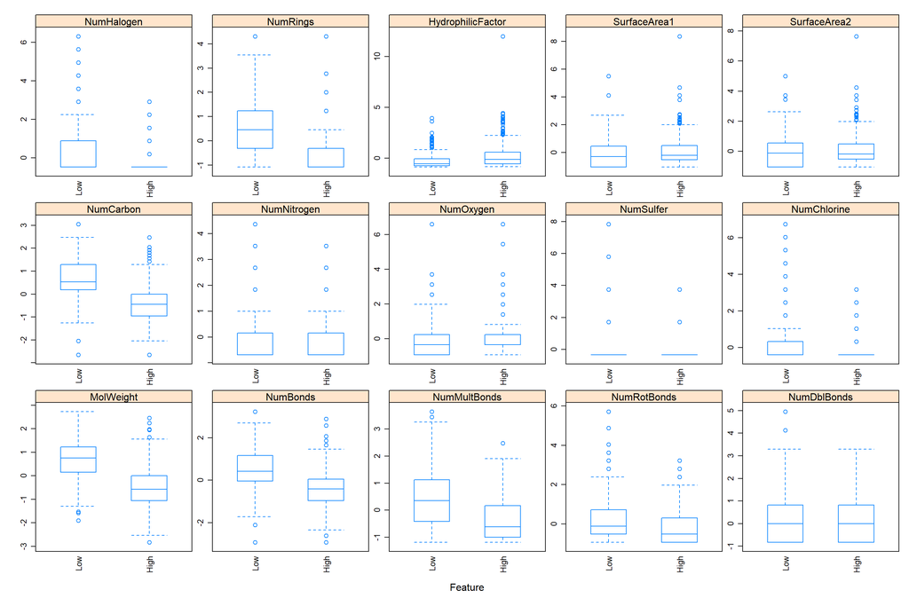

```r
##################################
# Formulating the box plots
##################################
featurePlot(x = EDA.Predictors.Numeric,
            y = EDA$Log_Solubility_Class,
            plot = "box",
            scales = list(x = list(relation="free", rot = 90),
                          y = list(relation="free")),
            adjust = 1.5,
            pch = "|")
```

```r
##################################
# Restructuring the dataset for
# for barchart analysis
##################################
Log_Solubility_Class <- DPA$Log_Solubility_Class
EDA.Bar.Source <- as.data.frame(cbind(Log_Solubility_Class,
                     EDA.Predictors.Factor))
ncol(EDA.Bar.Source)
```

```
## [1] 206
```

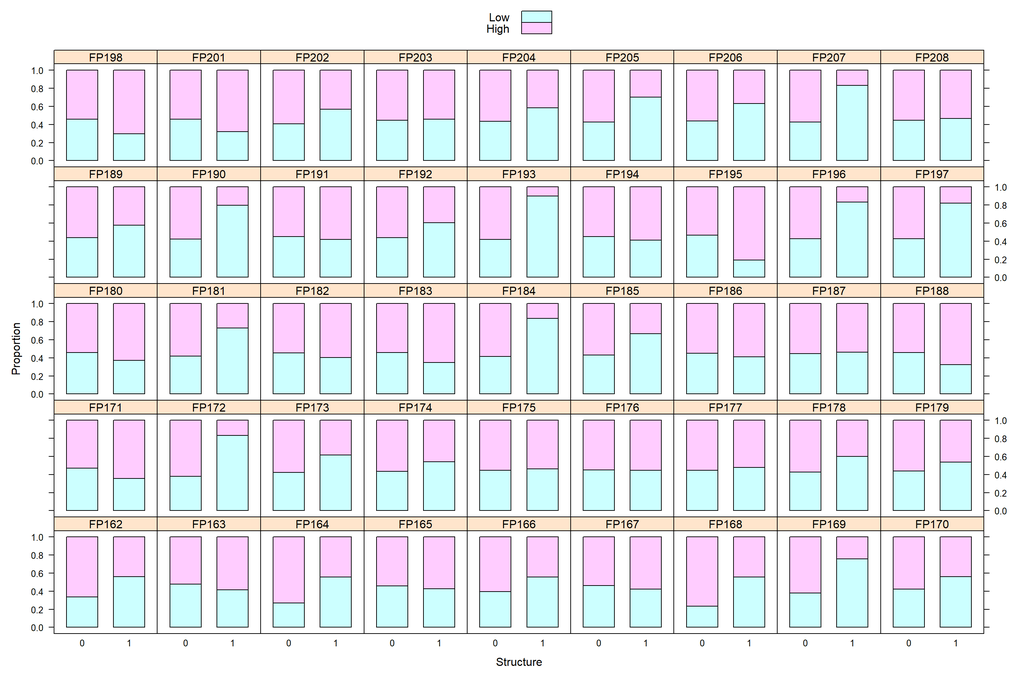

```r
##################################
# Creating a function to formulate
# the proportions table
##################################
EDA.PropTable.Function <- function(FactorVar) {
  EDA.Bar.Source.FactorVar <- EDA.Bar.Source[,c("Log_Solubility_Class",
                                          FactorVar)]
  EDA.Bar.Source.FactorVar.Prop <- as.data.frame(prop.table(table(EDA.Bar.Source.FactorVar), 2))
  names(EDA.Bar.Source.FactorVar.Prop)[2] <- "Structure"
  EDA.Bar.Source.FactorVar.Prop$Variable <- rep(FactorVar,nrow(EDA.Bar.Source.FactorVar.Prop))

  return(EDA.Bar.Source.FactorVar.Prop)

}

EDA.Bar.Source.FactorVar.Prop.Group5 <- rbind(EDA.PropTable.Function(names(EDA.Bar.Source)[162]),
                                              EDA.PropTable.Function(names(EDA.Bar.Source)[163]),
                                              EDA.PropTable.Function(names(EDA.Bar.Source)[164]),
                                              EDA.PropTable.Function(names(EDA.Bar.Source)[165]),
                                              EDA.PropTable.Function(names(EDA.Bar.Source)[166]),
                                              EDA.PropTable.Function(names(EDA.Bar.Source)[167]),
                                              EDA.PropTable.Function(names(EDA.Bar.Source)[168]),
                                              EDA.PropTable.Function(names(EDA.Bar.Source)[169]),
                                              EDA.PropTable.Function(names(EDA.Bar.Source)[170]),
                                              EDA.PropTable.Function(names(EDA.Bar.Source)[171]),
                                              EDA.PropTable.Function(names(EDA.Bar.Source)[172]),
                                              EDA.PropTable.Function(names(EDA.Bar.Source)[173]),
                                              EDA.PropTable.Function(names(EDA.Bar.Source)[174]),
                                              EDA.PropTable.Function(names(EDA.Bar.Source)[175]),
                                              EDA.PropTable.Function(names(EDA.Bar.Source)[176]),
                                              EDA.PropTable.Function(names(EDA.Bar.Source)[177]),
                                              EDA.PropTable.Function(names(EDA.Bar.Source)[178]),
                                              EDA.PropTable.Function(names(EDA.Bar.Source)[179]),
                                              EDA.PropTable.Function(names(EDA.Bar.Source)[180]),
                                              EDA.PropTable.Function(names(EDA.Bar.Source)[181]),
                                              EDA.PropTable.Function(names(EDA.Bar.Source)[182]),
                                              EDA.PropTable.Function(names(EDA.Bar.Source)[183]),
                                              EDA.PropTable.Function(names(EDA.Bar.Source)[184]),
                                              EDA.PropTable.Function(names(EDA.Bar.Source)[185]),
                                              EDA.PropTable.Function(names(EDA.Bar.Source)[186]),
                                              EDA.PropTable.Function(names(EDA.Bar.Source)[187]),
                                              EDA.PropTable.Function(names(EDA.Bar.Source)[188]),
                                              EDA.PropTable.Function(names(EDA.Bar.Source)[189]),
                                              EDA.PropTable.Function(names(EDA.Bar.Source)[190]),
                                              EDA.PropTable.Function(names(EDA.Bar.Source)[191]),
                                              EDA.PropTable.Function(names(EDA.Bar.Source)[192]),
                                              EDA.PropTable.Function(names(EDA.Bar.Source)[193]),
                                              EDA.PropTable.Function(names(EDA.Bar.Source)[194]),
                                              EDA.PropTable.Function(names(EDA.Bar.Source)[195]),
                                              EDA.PropTable.Function(names(EDA.Bar.Source)[196]),
                                              EDA.PropTable.Function(names(EDA.Bar.Source)[197]),
                                              EDA.PropTable.Function(names(EDA.Bar.Source)[198]),
                                              EDA.PropTable.Function(names(EDA.Bar.Source)[199]),
                                              EDA.PropTable.Function(names(EDA.Bar.Source)[200]),
                                              EDA.PropTable.Function(names(EDA.Bar.Source)[201]),
                                              EDA.PropTable.Function(names(EDA.Bar.Source)[202]),
                                              EDA.PropTable.Function(names(EDA.Bar.Source)[203]),
                                              EDA.PropTable.Function(names(EDA.Bar.Source)[204]),
                                              EDA.PropTable.Function(names(EDA.Bar.Source)[205]),
                                              EDA.PropTable.Function(names(EDA.Bar.Source)[206]))

(EDA.Barchart.FactorVar <- barchart(EDA.Bar.Source.FactorVar.Prop.Group5[,3] ~
                                      EDA.Bar.Source.FactorVar.Prop.Group5[,2] | EDA.Bar.Source.FactorVar.Prop.Group5[,4],
                                      data=EDA.Bar.Source.FactorVar.Prop.Group5,
                                      groups = EDA.Bar.Source.FactorVar.Prop.Group5[,1],
                                      stack=TRUE,
                                      ylab = "Proportion",
                                      xlab = "Structure",
                                      auto.key = list(adj = 1),
                                      layout=(c(9,5))))
```

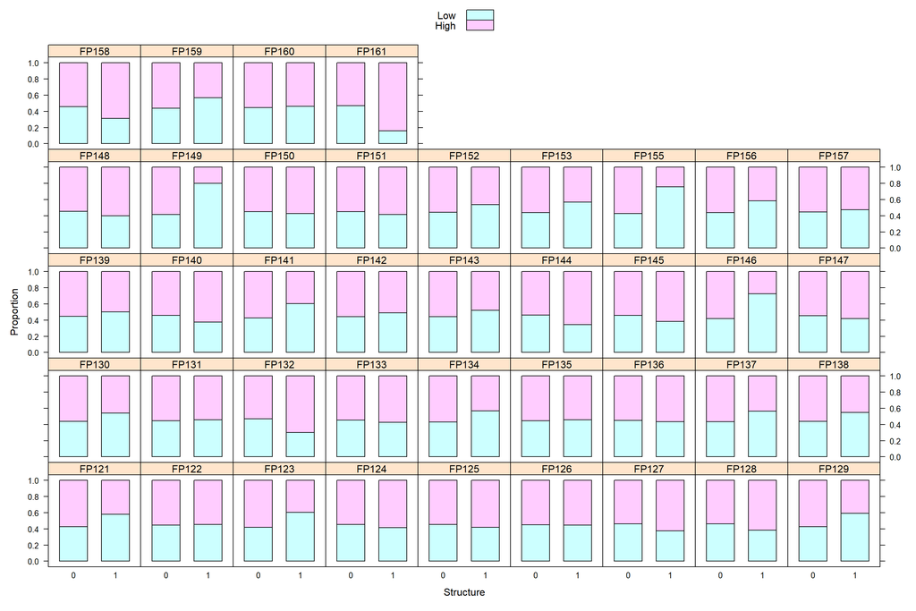

```r
EDA.Bar.Source.FactorVar.Prop.Group4 <- rbind(EDA.PropTable.Function(names(EDA.Bar.Source)[122]),
                                              EDA.PropTable.Function(names(EDA.Bar.Source)[123]),
                                              EDA.PropTable.Function(names(EDA.Bar.Source)[124]),
                                              EDA.PropTable.Function(names(EDA.Bar.Source)[125]),
                                              EDA.PropTable.Function(names(EDA.Bar.Source)[126]),
                                              EDA.PropTable.Function(names(EDA.Bar.Source)[127]),
                                              EDA.PropTable.Function(names(EDA.Bar.Source)[128]),
                                              EDA.PropTable.Function(names(EDA.Bar.Source)[129]),
                                              EDA.PropTable.Function(names(EDA.Bar.Source)[130]),
                                              EDA.PropTable.Function(names(EDA.Bar.Source)[131]),
                                              EDA.PropTable.Function(names(EDA.Bar.Source)[132]),
                                              EDA.PropTable.Function(names(EDA.Bar.Source)[133]),
                                              EDA.PropTable.Function(names(EDA.Bar.Source)[134]),
                                              EDA.PropTable.Function(names(EDA.Bar.Source)[135]),
                                              EDA.PropTable.Function(names(EDA.Bar.Source)[136]),
                                              EDA.PropTable.Function(names(EDA.Bar.Source)[137]),
                                              EDA.PropTable.Function(names(EDA.Bar.Source)[138]),
                                              EDA.PropTable.Function(names(EDA.Bar.Source)[139]),
                                              EDA.PropTable.Function(names(EDA.Bar.Source)[140]),
                                              EDA.PropTable.Function(names(EDA.Bar.Source)[141]),
                                              EDA.PropTable.Function(names(EDA.Bar.Source)[142]),
                                              EDA.PropTable.Function(names(EDA.Bar.Source)[143]),
                                              EDA.PropTable.Function(names(EDA.Bar.Source)[144]),
                                              EDA.PropTable.Function(names(EDA.Bar.Source)[145]),
                                              EDA.PropTable.Function(names(EDA.Bar.Source)[146]),
                                              EDA.PropTable.Function(names(EDA.Bar.Source)[147]),
                                              EDA.PropTable.Function(names(EDA.Bar.Source)[148]),
                                              EDA.PropTable.Function(names(EDA.Bar.Source)[149]),
                                              EDA.PropTable.Function(names(EDA.Bar.Source)[150]),
                                              EDA.PropTable.Function(names(EDA.Bar.Source)[151]),
                                              EDA.PropTable.Function(names(EDA.Bar.Source)[152]),
                                              EDA.PropTable.Function(names(EDA.Bar.Source)[153]),
                                              EDA.PropTable.Function(names(EDA.Bar.Source)[154]),
                                              EDA.PropTable.Function(names(EDA.Bar.Source)[155]),
                                              EDA.PropTable.Function(names(EDA.Bar.Source)[156]),
                                              EDA.PropTable.Function(names(EDA.Bar.Source)[157]),
                                              EDA.PropTable.Function(names(EDA.Bar.Source)[158]),
                                              EDA.PropTable.Function(names(EDA.Bar.Source)[159]),
                                              EDA.PropTable.Function(names(EDA.Bar.Source)[160]),
                                              EDA.PropTable.Function(names(EDA.Bar.Source)[161]))

(EDA.Barchart.FactorVar <- barchart(EDA.Bar.Source.FactorVar.Prop.Group4[,3] ~
                                      EDA.Bar.Source.FactorVar.Prop.Group4[,2] | EDA.Bar.Source.FactorVar.Prop.Group4[,4],
                                      data=EDA.Bar.Source.FactorVar.Prop.Group4,
                                      groups = EDA.Bar.Source.FactorVar.Prop.Group4[,1],
                                      stack=TRUE,
                                      ylab = "Proportion",
                                      xlab = "Structure",
                                      auto.key = list(adj = 1),
                                      layout=(c(9,5))))
```

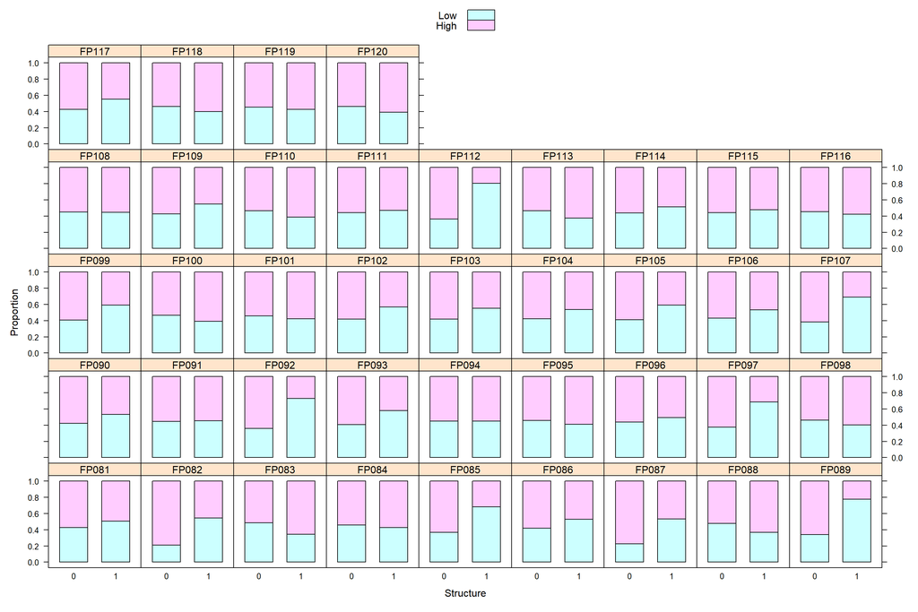

```r
EDA.Bar.Source.FactorVar.Prop.Group3 <- rbind(EDA.PropTable.Function(names(EDA.Bar.Source)[82]),
                                              EDA.PropTable.Function(names(EDA.Bar.Source)[83]),
                                              EDA.PropTable.Function(names(EDA.Bar.Source)[84]),
                                              EDA.PropTable.Function(names(EDA.Bar.Source)[85]),
                                              EDA.PropTable.Function(names(EDA.Bar.Source)[86]),
                                              EDA.PropTable.Function(names(EDA.Bar.Source)[87]),
                                              EDA.PropTable.Function(names(EDA.Bar.Source)[88]),
                                              EDA.PropTable.Function(names(EDA.Bar.Source)[89]),
                                              EDA.PropTable.Function(names(EDA.Bar.Source)[90]),
                                              EDA.PropTable.Function(names(EDA.Bar.Source)[91]),
                                              EDA.PropTable.Function(names(EDA.Bar.Source)[92]),
                                              EDA.PropTable.Function(names(EDA.Bar.Source)[93]),
                                              EDA.PropTable.Function(names(EDA.Bar.Source)[94]),
                                              EDA.PropTable.Function(names(EDA.Bar.Source)[95]),
                                              EDA.PropTable.Function(names(EDA.Bar.Source)[96]),
                                              EDA.PropTable.Function(names(EDA.Bar.Source)[97]),
                                              EDA.PropTable.Function(names(EDA.Bar.Source)[98]),
                                              EDA.PropTable.Function(names(EDA.Bar.Source)[99]),
                                              EDA.PropTable.Function(names(EDA.Bar.Source)[100]),
                                              EDA.PropTable.Function(names(EDA.Bar.Source)[101]),
                                              EDA.PropTable.Function(names(EDA.Bar.Source)[102]),
                                              EDA.PropTable.Function(names(EDA.Bar.Source)[103]),
                                              EDA.PropTable.Function(names(EDA.Bar.Source)[104]),
                                              EDA.PropTable.Function(names(EDA.Bar.Source)[105]),
                                              EDA.PropTable.Function(names(EDA.Bar.Source)[106]),
                                              EDA.PropTable.Function(names(EDA.Bar.Source)[107]),
                                              EDA.PropTable.Function(names(EDA.Bar.Source)[108]),
                                              EDA.PropTable.Function(names(EDA.Bar.Source)[109]),
                                              EDA.PropTable.Function(names(EDA.Bar.Source)[110]),
                                              EDA.PropTable.Function(names(EDA.Bar.Source)[111]),
                                              EDA.PropTable.Function(names(EDA.Bar.Source)[112]),
                                              EDA.PropTable.Function(names(EDA.Bar.Source)[113]),
                                              EDA.PropTable.Function(names(EDA.Bar.Source)[114]),
                                              EDA.PropTable.Function(names(EDA.Bar.Source)[115]),
                                              EDA.PropTable.Function(names(EDA.Bar.Source)[116]),
                                              EDA.PropTable.Function(names(EDA.Bar.Source)[117]),
                                              EDA.PropTable.Function(names(EDA.Bar.Source)[118]),
                                              EDA.PropTable.Function(names(EDA.Bar.Source)[119]),
                                              EDA.PropTable.Function(names(EDA.Bar.Source)[120]),
                                              EDA.PropTable.Function(names(EDA.Bar.Source)[121]))

(EDA.Barchart.FactorVar <- barchart(EDA.Bar.Source.FactorVar.Prop.Group3[,3] ~
                                      EDA.Bar.Source.FactorVar.Prop.Group3[,2] | EDA.Bar.Source.FactorVar.Prop.Group3[,4],
                                      data=EDA.Bar.Source.FactorVar.Prop.Group3,
                                      groups = EDA.Bar.Source.FactorVar.Prop.Group3[,1],
                                      stack=TRUE,
                                      ylab = "Proportion",
                                      xlab = "Structure",
                                      auto.key = list(adj = 1),
                                      layout=(c(9,5))))
```

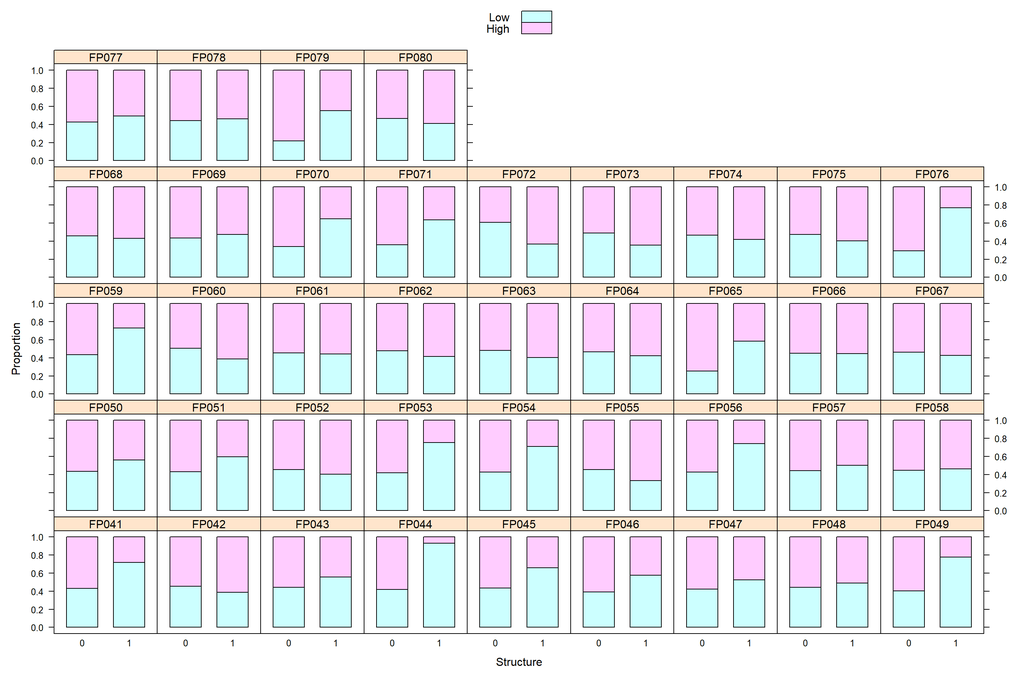

```r
EDA.Bar.Source.FactorVar.Prop.Group2 <- rbind(EDA.PropTable.Function(names(EDA.Bar.Source)[42]),
                                              EDA.PropTable.Function(names(EDA.Bar.Source)[43]),
                                              EDA.PropTable.Function(names(EDA.Bar.Source)[44]),
                                              EDA.PropTable.Function(names(EDA.Bar.Source)[45]),
                                              EDA.PropTable.Function(names(EDA.Bar.Source)[46]),
                                              EDA.PropTable.Function(names(EDA.Bar.Source)[47]),
                                              EDA.PropTable.Function(names(EDA.Bar.Source)[48]),
                                              EDA.PropTable.Function(names(EDA.Bar.Source)[49]),
                                              EDA.PropTable.Function(names(EDA.Bar.Source)[50]),
                                              EDA.PropTable.Function(names(EDA.Bar.Source)[51]),
                                              EDA.PropTable.Function(names(EDA.Bar.Source)[52]),
                                              EDA.PropTable.Function(names(EDA.Bar.Source)[53]),
                                              EDA.PropTable.Function(names(EDA.Bar.Source)[54]),
                                              EDA.PropTable.Function(names(EDA.Bar.Source)[55]),
                                              EDA.PropTable.Function(names(EDA.Bar.Source)[56]),
                                              EDA.PropTable.Function(names(EDA.Bar.Source)[57]),
                                              EDA.PropTable.Function(names(EDA.Bar.Source)[58]),
                                              EDA.PropTable.Function(names(EDA.Bar.Source)[59]),
                                              EDA.PropTable.Function(names(EDA.Bar.Source)[60]),
                                              EDA.PropTable.Function(names(EDA.Bar.Source)[61]),
                                              EDA.PropTable.Function(names(EDA.Bar.Source)[62]),
                                              EDA.PropTable.Function(names(EDA.Bar.Source)[63]),
                                              EDA.PropTable.Function(names(EDA.Bar.Source)[64]),
                                              EDA.PropTable.Function(names(EDA.Bar.Source)[65]),
                                              EDA.PropTable.Function(names(EDA.Bar.Source)[66]),
                                              EDA.PropTable.Function(names(EDA.Bar.Source)[67]),
                                              EDA.PropTable.Function(names(EDA.Bar.Source)[68]),
                                              EDA.PropTable.Function(names(EDA.Bar.Source)[69]),
                                              EDA.PropTable.Function(names(EDA.Bar.Source)[70]),
                                              EDA.PropTable.Function(names(EDA.Bar.Source)[71]),
                                              EDA.PropTable.Function(names(EDA.Bar.Source)[72]),
                                              EDA.PropTable.Function(names(EDA.Bar.Source)[73]),
                                              EDA.PropTable.Function(names(EDA.Bar.Source)[74]),
                                              EDA.PropTable.Function(names(EDA.Bar.Source)[75]),
                                              EDA.PropTable.Function(names(EDA.Bar.Source)[76]),
                                              EDA.PropTable.Function(names(EDA.Bar.Source)[77]),
                                              EDA.PropTable.Function(names(EDA.Bar.Source)[78]),
                                              EDA.PropTable.Function(names(EDA.Bar.Source)[79]),
                                              EDA.PropTable.Function(names(EDA.Bar.Source)[80]),
                                              EDA.PropTable.Function(names(EDA.Bar.Source)[81]))

(EDA.Barchart.FactorVar <- barchart(EDA.Bar.Source.FactorVar.Prop.Group2[,3] ~
                                      EDA.Bar.Source.FactorVar.Prop.Group2[,2] | EDA.Bar.Source.FactorVar.Prop.Group2[,4],
                                      data=EDA.Bar.Source.FactorVar.Prop.Group2,
                                      groups = EDA.Bar.Source.FactorVar.Prop.Group2[,1],
                                      stack=TRUE,
                                      ylab = "Proportion",
                                      xlab = "Structure",
                                      auto.key = list(adj = 1),
                                      layout=(c(9,5))))
```

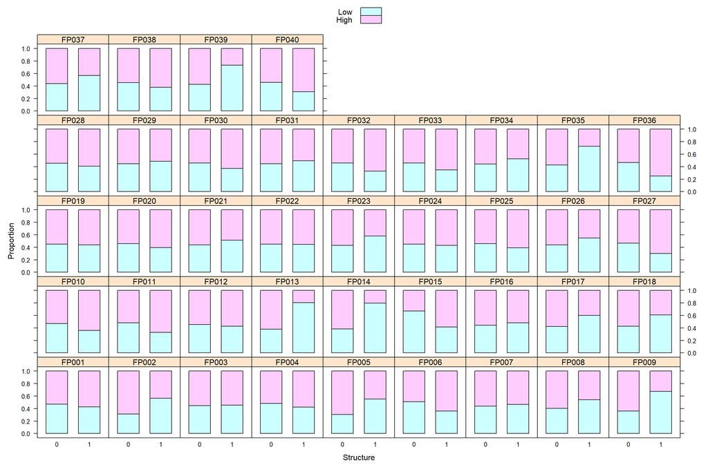

```r
EDA.Bar.Source.FactorVar.Prop.Group1 <- rbind(EDA.PropTable.Function(names(EDA.Bar.Source)[2]),
                                              EDA.PropTable.Function(names(EDA.Bar.Source)[3]),
                                              EDA.PropTable.Function(names(EDA.Bar.Source)[4]),
                                              EDA.PropTable.Function(names(EDA.Bar.Source)[5]),
                                              EDA.PropTable.Function(names(EDA.Bar.Source)[6]),
                                              EDA.PropTable.Function(names(EDA.Bar.Source)[7]),
                                              EDA.PropTable.Function(names(EDA.Bar.Source)[8]),
                                              EDA.PropTable.Function(names(EDA.Bar.Source)[9]),
                                              EDA.PropTable.Function(names(EDA.Bar.Source)[10]),
                                              EDA.PropTable.Function(names(EDA.Bar.Source)[11]),
                                              EDA.PropTable.Function(names(EDA.Bar.Source)[12]),
                                              EDA.PropTable.Function(names(EDA.Bar.Source)[13]),
                                              EDA.PropTable.Function(names(EDA.Bar.Source)[14]),
                                              EDA.PropTable.Function(names(EDA.Bar.Source)[15]),
                                              EDA.PropTable.Function(names(EDA.Bar.Source)[16]),
                                              EDA.PropTable.Function(names(EDA.Bar.Source)[17]),
                                              EDA.PropTable.Function(names(EDA.Bar.Source)[18]),
                                              EDA.PropTable.Function(names(EDA.Bar.Source)[19]),
                                              EDA.PropTable.Function(names(EDA.Bar.Source)[20]),
                                              EDA.PropTable.Function(names(EDA.Bar.Source)[21]),
                                              EDA.PropTable.Function(names(EDA.Bar.Source)[22]),
                                              EDA.PropTable.Function(names(EDA.Bar.Source)[23]),
                                              EDA.PropTable.Function(names(EDA.Bar.Source)[24]),
                                              EDA.PropTable.Function(names(EDA.Bar.Source)[25]),
                                              EDA.PropTable.Function(names(EDA.Bar.Source)[26]),
                                              EDA.PropTable.Function(names(EDA.Bar.Source)[27]),
                                              EDA.PropTable.Function(names(EDA.Bar.Source)[28]),
                                              EDA.PropTable.Function(names(EDA.Bar.Source)[29]),
                                              EDA.PropTable.Function(names(EDA.Bar.Source)[30]),
                                              EDA.PropTable.Function(names(EDA.Bar.Source)[31]),
                                              EDA.PropTable.Function(names(EDA.Bar.Source)[32]),
                                              EDA.PropTable.Function(names(EDA.Bar.Source)[33]),
                                              EDA.PropTable.Function(names(EDA.Bar.Source)[34]),
                                              EDA.PropTable.Function(names(EDA.Bar.Source)[35]),
                                              EDA.PropTable.Function(names(EDA.Bar.Source)[36]),
                                              EDA.PropTable.Function(names(EDA.Bar.Source)[37]),
                                              EDA.PropTable.Function(names(EDA.Bar.Source)[38]),
                                              EDA.PropTable.Function(names(EDA.Bar.Source)[39]),
                                              EDA.PropTable.Function(names(EDA.Bar.Source)[40]),
                                              EDA.PropTable.Function(names(EDA.Bar.Source)[41]))

(EDA.Barchart.FactorVar <- barchart(EDA.Bar.Source.FactorVar.Prop.Group1[,3] ~
                                      EDA.Bar.Source.FactorVar.Prop.Group1[,2] | EDA.Bar.Source.FactorVar.Prop.Group1[,4],
                                      data=EDA.Bar.Source.FactorVar.Prop.Group1,
                                      groups = EDA.Bar.Source.FactorVar.Prop.Group1[,1],
                                      stack=TRUE,
                                      ylab = "Proportion",
                                      xlab = "Structure",
                                      auto.key = list(adj = 1),
                                      layout=(c(9,5))))
```

## 1.5 Model-Independent Feature Importance Metrics

### 1.5.1 Area Under The Receiver Operating Characteristics Curve (AUROC)

[Area Under The Receiver Operating Characteristics Curve](https://www.semanticscholar.org/paper/Signal-detection-theory-and-ROC-analysis-Egan/a2cf3479c3b5c96b8ee8c353876fba5048a39fb7) involves a plot that demonstrates the performance of a classification prediction model to discriminate between two levels of a categorical response when compared to a gold standard, using the true positive rate (or Sensitivity) and the false positive rate (or 1-Specificity) for a range of threshold settings. The area under the ROC curve measures its discrimination power which is the ability of the model to distinguish between two classes or groups. The presence of high AUROC indicates the univariate discrimination of the categorical response by the numeric predictors.  
**[A]** The area under the receiver operating characteristics curve metric was obtained using the **caret** package. High raw values of the metric indicate that the numeric predictors were associated with the factor response.  
**[B]** The numeric predictors which demonstrated the best feature importance in terms of this metric are as follows:  
**[B.1]** MolWeight = 0.84419  
**[B.2]** NumCarbon = 0.84088  
**[B.3]** NumBonds = 0.78932  
**[B.4]** NumRings = 0.74385  
**[B.5]** NumMultBonds = 0.72301

**Code Chunk | Output**

```r
##################################
# Filtering in the numeric predictors
# with the factor response variable
##################################
PMA_PreModelling_Train_Numeric <- PMA_PreModelling_Train[,!grepl("FP", names(PMA_PreModelling_Train))]
dim(PMA_PreModelling_Train_Numeric)
```

```
## [1] 951  16
```

```r
str(PMA_PreModelling_Train_Numeric)
```

```
## 'data.frame':    951 obs. of  16 variables:
##  $ Log_Solubility_Class: Factor w/ 2 levels "Low","High": 1 1 1 1 1 1 1 1 1 1 ...
##  $ MolWeight           : num  0.304 1.475 0.284 -0.579 0.508 ...
##  $ NumBonds            : num  0.498 1.698 0.697 0.207 0.566 ...
##  $ NumMultBonds        : num  1.9049 1.3248 0.1647 -0.8021 -0.0287 ...
##  $ NumRotBonds         : num  -0.935 0.726 0.726 -0.52 1.141 ...
##  $ NumDblBonds         : num  -0.83134 -0.83134 -0.00521 0.82092 -0.83134 ...
##  $ NumCarbon           : num  0.858 1.804 0.701 0.182 -0.012 ...
##  $ NumNitrogen         : num  1.001 1.844 -0.685 -0.685 3.53 ...
##  $ NumOxygen           : num  -0.91 -0.332 0.246 -0.91 -0.91 ...
##  $ NumSulfer           : num  -0.336 1.712 -0.336 -0.336 -0.336 ...
##  $ NumChlorine         : num  -0.397 -0.397 -0.397 -0.397 0.317 ...
##  $ NumHalogen          : num  -0.474 -0.474 -0.474 -0.474 0.205 ...
##  $ NumRings            : num  1.231 2.001 -0.309 -0.309 -0.309 ...
##  $ HydrophilicFactor   : num  -0.742 -0.31 -0.275 -0.834 -0.043 ...
##  $ SurfaceArea1        : num  -0.3026 0.4458 0.0238 -1.0332 0.4954 ...
##  $ SurfaceArea2        : num  -0.379 1.054 -0.077 -1.055 0.36 ...
```

```r
summary(PMA_PreModelling_Train_Numeric)
```

```
##  Log_Solubility_Class   MolWeight            NumBonds        NumMultBonds
##  Low :427             Min.   :-2.835229   Min.   :-2.9239   Min.   :-1.18881
##  High:524             1st Qu.:-0.798923   1st Qu.:-0.6096   1st Qu.:-0.99545
##                       Median :-0.008626   Median :-0.0356   Median :-0.02867
##                       Mean   : 0.000000   Mean   : 0.0000   Mean   : 0.00000
##                       3rd Qu.: 0.800109   3rd Qu.: 0.5994   3rd Qu.: 0.74476
##                       Max.   : 2.722778   Max.   : 3.2279   Max.   : 3.64511
##   NumRotBonds       NumDblBonds          NumCarbon         NumNitrogen
##  Min.   :-0.9347   Min.   :-0.831342   Min.   :-2.64433   Min.   :-0.6852
##  1st Qu.:-0.9347   1st Qu.:-0.831342   1st Qu.:-0.68596   1st Qu.:-0.6852
##  Median :-0.1043   Median :-0.005212   Median :-0.01199   Median :-0.6852
##  Mean   : 0.0000   Mean   : 0.000000   Mean   : 0.00000   Mean   : 0.0000
##  3rd Qu.: 0.5184   3rd Qu.: 0.820917   3rd Qu.: 0.53700   3rd Qu.: 0.1578
##  Max.   : 5.7083   Max.   : 4.951564   Max.   : 3.05604   Max.   : 4.3730
##    NumOxygen         NumSulfer       NumChlorine        NumHalogen
##  Min.   :-0.9103   Min.   :-0.336   Min.   :-0.3972   Min.   :-0.4741
##  1st Qu.:-0.9103   1st Qu.:-0.336   1st Qu.:-0.3972   1st Qu.:-0.4741
##  Median :-0.3320   Median :-0.336   Median :-0.3972   Median :-0.4741
##  Mean   : 0.0000   Mean   : 0.000   Mean   : 0.0000   Mean   : 0.0000
##  3rd Qu.: 0.2463   3rd Qu.:-0.336   3rd Qu.:-0.3972   3rd Qu.: 0.2049
##  Max.   : 6.6077   Max.   : 7.858   Max.   : 6.7442   Max.   : 6.3162
##     NumRings       HydrophilicFactor  SurfaceArea1      SurfaceArea2
##  Min.   :-1.0792   Min.   :-0.8565   Min.   :-1.0332   Min.   :-1.0554
##  1st Qu.:-1.0792   1st Qu.:-0.6593   1st Qu.:-0.7716   1st Qu.:-0.7765
##  Median :-0.3093   Median :-0.2606   Median :-0.2085   Median :-0.1866
##  Mean   : 0.0000   Mean   : 0.0000   Mean   : 0.0000   Mean   : 0.0000
##  3rd Qu.: 0.4607   3rd Qu.: 0.2963   3rd Qu.: 0.4767   3rd Qu.: 0.5358
##  Max.   : 4.3103   Max.   :11.9924   Max.   : 8.3733   Max.   : 7.6515
```

```r
##################################
# Obtaining the ROC AUC
##################################
AUROC <- filterVarImp(x = PMA_PreModelling_Train_Numeric[, 2:ncol(PMA_PreModelling_Train_Numeric)],
                        y = PMA_PreModelling_Train_Numeric$Log_Solubility_Class)

##################################
# Formulating the summary table
##################################
AUROC_Summary <- AUROC

AUROC_Summary$Predictor <- rownames(AUROC)
names(AUROC_Summary)[1] <- "AUROC"
AUROC_Summary$Metric <- rep("AUROC",nrow(AUROC))

AUROC_Summary
```

```
##                       AUROC      High         Predictor Metric
## MolWeight         0.8441930 0.8441930         MolWeight  AUROC
## NumBonds          0.7893255 0.7893255          NumBonds  AUROC
## NumMultBonds      0.7230098 0.7230098      NumMultBonds  AUROC
## NumRotBonds       0.5847695 0.5847695       NumRotBonds  AUROC
## NumDblBonds       0.5142035 0.5142035       NumDblBonds  AUROC
## NumCarbon         0.8408857 0.8408857         NumCarbon  AUROC
## NumNitrogen       0.5285634 0.5285634       NumNitrogen  AUROC
## NumOxygen         0.5536988 0.5536988         NumOxygen  AUROC
## NumSulfer         0.5317902 0.5317902         NumSulfer  AUROC
## NumChlorine       0.6104904 0.6104904       NumChlorine  AUROC
## NumHalogen        0.6381755 0.6381755        NumHalogen  AUROC
## NumRings          0.7438569 0.7438569          NumRings  AUROC
## HydrophilicFactor 0.6699367 0.6699367 HydrophilicFactor  AUROC
## SurfaceArea1      0.5726889 0.5726889      SurfaceArea1  AUROC
## SurfaceArea2      0.5479915 0.5479915      SurfaceArea2  AUROC
```

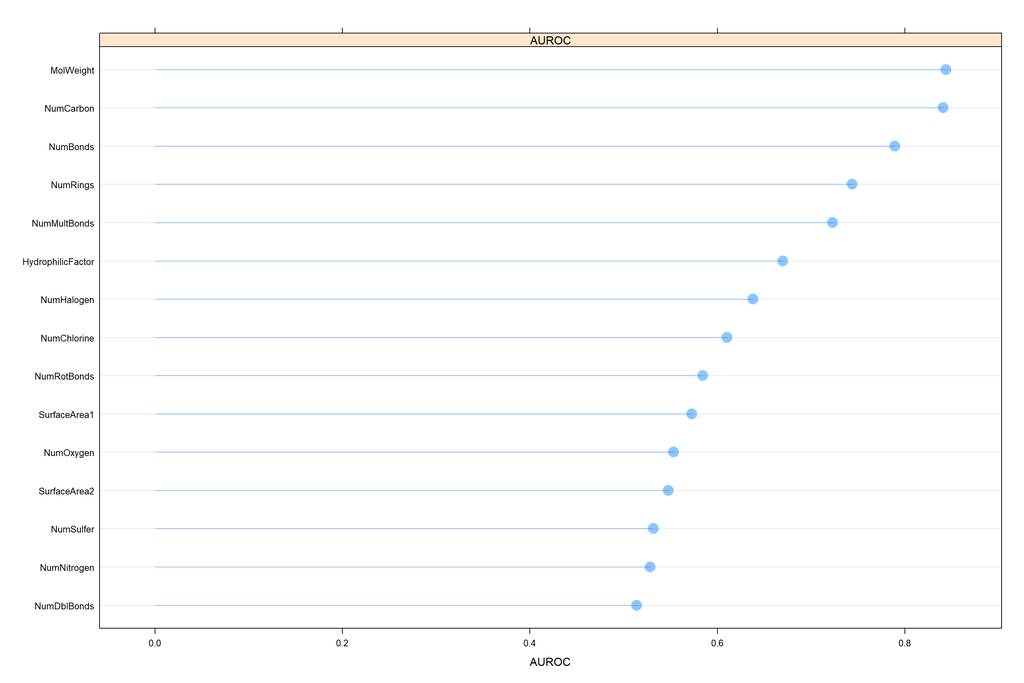

```r
##################################
# Exploring predictor performance
##################################
dotplot(Predictor ~ AUROC | Metric,
        AUROC_Summary,
        origin = 0,
        type = c("p", "h"),
        pch = 16,
        cex = 2,
        alpha = 0.45,
        prepanel = function(x, y) {
            list(ylim = levels(reorder(y, x)))
        },
        panel = function(x, y, ...) {
            panel.dotplot(x, reorder(y, x), ...)
        })
```

### 1.5.2 Absolute T-Test Statistic (ATS)

[T-Test Statistic](https://www.jstor.org/stable/2685564?seq=1#page_scan_tab_contents), as derived from implementing a T-Test, measures the magnitude of the difference between the two group means being compared and is used to estimate the likelihood that this difference exists purely by chance. The test of hypothesis involved applying T-Test to evaluate for any significant differences in the means of the numeric predictors between the two classes of the categorical response. The presence of high T-Test statistic indicates the univariate discrimination of the categorical response by the numeric predictors.  
**[A]** The absolute T-test statistic was obtained using the **stats** package. High absolute values of the metric indicate that the numeric predictors were associated with the factor response.  
**[B]** The numeric predictors which demonstrated the best feature importance in terms of this metric are as follows:  
**[B.1]** MolWeight = 22.06757  
**[B.2]** NumCarbon = 21.00363  
**[B.3]** NumBonds = 16.49077  
**[B.4]** NumRings = 14.39568  
**[B.5]** NumMultBonds = 13.09205

**Code Chunk | Output**

```r
##################################
# Obtaining the t-test statistics
##################################
ATS <- apply(PMA_PreModelling_Train_Numeric[, 2:ncol(PMA_PreModelling_Train_Numeric)],
             2,
             function(x, y){
               tStats <- t.test(x ~ y)[c("statistic", "p.value", "estimate")]
               unlist(tStats)},
             y=PMA_PreModelling_Train_Numeric$Log_Solubility_Class)

##################################
# Formulating the summary table
##################################
ATS_Summary <- as.data.frame(t(ATS))
names(ATS_Summary) <- c("t.Statistic", "t.Test_P.Value", "Mean0", "Mean1")
ATS_Summary$Predictor <- names(PMA_PreModelling_Train_Numeric[,-1])
ATS_Summary$Metric <- rep("ATS", nrow(ATS_Summary))
ATS_Summary$ATS <- abs(ATS_Summary$t.Statistic)

ATS_Summary
```

```
##                   t.Statistic t.Test_P.Value       Mean0       Mean1
## MolWeight          22.0675750   8.568100e-87  0.64470512 -0.52536085
## NumBonds           16.4907720   2.071672e-53  0.52608866 -0.42870202
## NumMultBonds       13.0920514   2.095787e-35  0.44544021 -0.36298277
## NumRotBonds         5.8690062   6.747824e-09  0.21555838 -0.17565539
## NumDblBonds         1.9672950   4.949190e-02  0.07217700 -0.05881599
## NumCarbon          21.0036355   8.156177e-80  0.62632485 -0.51038304
## NumNitrogen        -0.8247139   4.097543e-01 -0.02976857  0.02425798
## NumOxygen          -0.9312510   3.519946e-01 -0.03406840  0.02776184
## NumSulfer           3.2021823   1.427379e-03  0.11971764 -0.09755617
## NumChlorine         8.3362925   7.315159e-16  0.31187920 -0.25414584
## NumHalogen          9.1800512   9.409615e-19  0.33850129 -0.27583979
## NumRings           14.3956856   1.979115e-41  0.48410734 -0.39449205
## HydrophilicFactor  -7.3321483   5.053677e-13 -0.24599149  0.20045490
## SurfaceArea1       -2.5597702   1.063897e-02 -0.09225436  0.07517674
## SurfaceArea2       -1.1459666   2.521288e-01 -0.04168274  0.03396666
##                           Predictor Metric        ATS
## MolWeight                 MolWeight    ATS 22.0675750
## NumBonds                   NumBonds    ATS 16.4907720
## NumMultBonds           NumMultBonds    ATS 13.0920514
## NumRotBonds             NumRotBonds    ATS  5.8690062
## NumDblBonds             NumDblBonds    ATS  1.9672950
## NumCarbon                 NumCarbon    ATS 21.0036355
## NumNitrogen             NumNitrogen    ATS  0.8247139
## NumOxygen                 NumOxygen    ATS  0.9312510
## NumSulfer                 NumSulfer    ATS  3.2021823
## NumChlorine             NumChlorine    ATS  8.3362925
## NumHalogen               NumHalogen    ATS  9.1800512
## NumRings                   NumRings    ATS 14.3956856
## HydrophilicFactor HydrophilicFactor    ATS  7.3321483
## SurfaceArea1           SurfaceArea1    ATS  2.5597702
## SurfaceArea2           SurfaceArea2    ATS  1.1459666
```

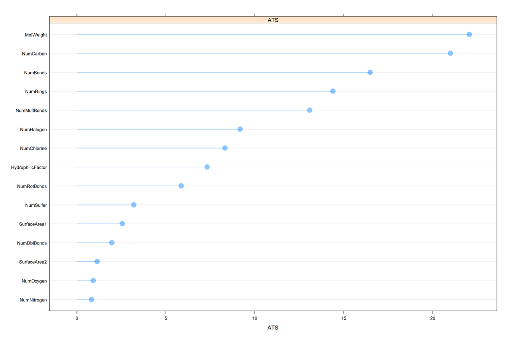

```r
##################################
# Exploring predictor performance
##################################
dotplot(Predictor ~ ATS | Metric,
        ATS_Summary,
        origin = 0,
        type = c("p", "h"),
        pch = 16,
        cex = 2,
        alpha = 0.45,
        prepanel = function(x, y) {
            list(ylim = levels(reorder(y, x)))
        },
        panel = function(x, y, ...) {
            panel.dotplot(x, reorder(y, x), ...)
        })
```

### 1.5.3 Maximal Information Coefficient (MIC)

**Code Chunk | Output**

```r
##################################
# Obtaining the maximal information coefficient
##################################
MIC <- mine(x = PMA_PreModelling_Train_Numeric[, 2:ncol(PMA_PreModelling_Train_Numeric)],
            y = ifelse(PMA_PreModelling_Train_Numeric$Log_Solubility_Class=="High",1,0))$MIC

##################################
# Formulating the summary table
##################################
MIC_Summary <- data.frame(Predictor = names(PMA_PreModelling_Train_Numeric)[2:ncol(PMA_PreModelling_Train_Numeric)],
                          MIC = MIC[,1],
                          Metric = rep("MIC", length(MIC)))

MIC_Summary
```

```
##            Predictor        MIC Metric
## 1          MolWeight 0.46368934    MIC
## 2           NumBonds 0.28498465    MIC
## 3       NumMultBonds 0.19005119    MIC
## 4        NumRotBonds 0.03861351    MIC
## 5        NumDblBonds 0.01133118    MIC
## 6          NumCarbon 0.31544845    MIC
## 7        NumNitrogen 0.01995159    MIC
## 8          NumOxygen 0.07491145    MIC
## 9          NumSulfer 0.01254889    MIC
## 10       NumChlorine 0.07010055    MIC
## 11        NumHalogen 0.08459159    MIC
## 12          NumRings 0.16421351    MIC
## 13 HydrophilicFactor 0.32734124    MIC
## 14      SurfaceArea1 0.19959108    MIC
## 15      SurfaceArea2 0.22267432    MIC
```

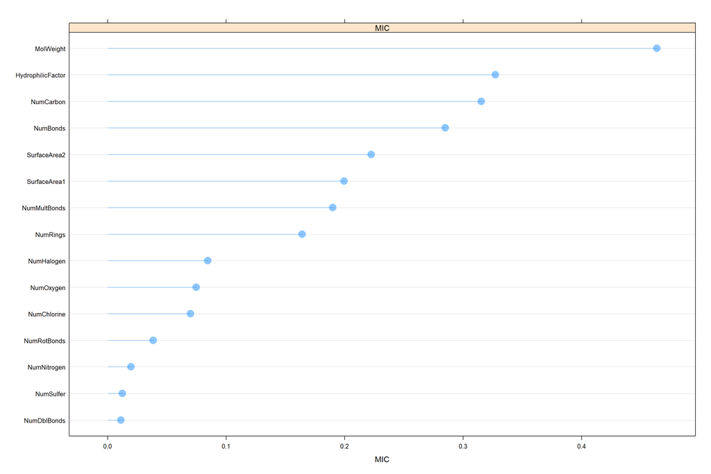

```r
##################################
# Exploring predictor performance
##################################
dotplot(Predictor ~ MIC | Metric,
        MIC_Summary,
        origin = 0,
        type = c("p", "h"),
        pch = 16,
        cex = 2,
        alpha = 0.45,
        prepanel = function(x, y) {
            list(ylim = levels(reorder(y, x)))
        },
        panel = function(x, y, ...) {
            panel.dotplot(x, reorder(y, x), ...)
        })
```

### 1.5.4 Relief Values (RV)

[Relief Values](https://link.springer.com/article/10.1023/A:1025667309714) are heuristic measures which estimate the quality of variables according to how well their values compare to instances that are near to each other, but are efficient in detecting contextual information even with strong dependencies between attributes. Given a randomly selected instance, its two nearest neighbors are selected - one from the same class (called nearest hit) and the other from a different class (called nearest miss). The quality for an attribute is estimated depending on the difference in probabilities obtained using the hits and misses. The presence of high relief values indicate the univariate association between the numeric predictors and the categorical response.  
**[A]** The relief values statistic was obtained using the **CORElearn** package. High raw values of the metric indicate that the numeric predictors were associated with the factor response.  
**[B]** The numeric predictors which demonstrated the best feature importance in terms of this metric are as follows:  
**[B.1]** MolWeight = 0.30039  
**[B.2]** NumCarbon = 0.28938  
**[B.3]** NumRings = 0.20600  
**[B.4]** NumBonds = 0.20575  
**[B.5]** NumNitrogen = 0.10800

**Code Chunk | Output**

```r
summary(PMA_PreModelling_Train_Numeric)
```

```
##  Log_Solubility_Class   MolWeight            NumBonds        NumMultBonds
##  Low :427             Min.   :-2.835229   Min.   :-2.9239   Min.   :-1.18881
##  High:524             1st Qu.:-0.798923   1st Qu.:-0.6096   1st Qu.:-0.99545
##                       Median :-0.008626   Median :-0.0356   Median :-0.02867
##                       Mean   : 0.000000   Mean   : 0.0000   Mean   : 0.00000
##                       3rd Qu.: 0.800109   3rd Qu.: 0.5994   3rd Qu.: 0.74476
##                       Max.   : 2.722778   Max.   : 3.2279   Max.   : 3.64511
##   NumRotBonds       NumDblBonds          NumCarbon         NumNitrogen
##  Min.   :-0.9347   Min.   :-0.831342   Min.   :-2.64433   Min.   :-0.6852
##  1st Qu.:-0.9347   1st Qu.:-0.831342   1st Qu.:-0.68596   1st Qu.:-0.6852
##  Median :-0.1043   Median :-0.005212   Median :-0.01199   Median :-0.6852
##  Mean   : 0.0000   Mean   : 0.000000   Mean   : 0.00000   Mean   : 0.0000
##  3rd Qu.: 0.5184   3rd Qu.: 0.820917   3rd Qu.: 0.53700   3rd Qu.: 0.1578
##  Max.   : 5.7083   Max.   : 4.951564   Max.   : 3.05604   Max.   : 4.3730
##    NumOxygen         NumSulfer       NumChlorine        NumHalogen
##  Min.   :-0.9103   Min.   :-0.336   Min.   :-0.3972   Min.   :-0.4741
##  1st Qu.:-0.9103   1st Qu.:-0.336   1st Qu.:-0.3972   1st Qu.:-0.4741
##  Median :-0.3320   Median :-0.336   Median :-0.3972   Median :-0.4741
##  Mean   : 0.0000   Mean   : 0.000   Mean   : 0.0000   Mean   : 0.0000
##  3rd Qu.: 0.2463   3rd Qu.:-0.336   3rd Qu.:-0.3972   3rd Qu.: 0.2049
##  Max.   : 6.6077   Max.   : 7.858   Max.   : 6.7442   Max.   : 6.3162
##     NumRings       HydrophilicFactor  SurfaceArea1      SurfaceArea2
##  Min.   :-1.0792   Min.   :-0.8565   Min.   :-1.0332   Min.   :-1.0554
##  1st Qu.:-1.0792   1st Qu.:-0.6593   1st Qu.:-0.7716   1st Qu.:-0.7765
##  Median :-0.3093   Median :-0.2606   Median :-0.2085   Median :-0.1866
##  Mean   : 0.0000   Mean   : 0.0000   Mean   : 0.0000   Mean   : 0.0000
##  3rd Qu.: 0.4607   3rd Qu.: 0.2963   3rd Qu.: 0.4767   3rd Qu.: 0.5358
##  Max.   : 4.3103   Max.   :11.9924   Max.   : 8.3733   Max.   : 7.6515
```

```r
##################################
# Obtaining the relief values
##################################
set.seed(12345678)
RV <- attrEval(Log_Solubility_Class ~ .,
               data = PMA_PreModelling_Train_Numeric,
               estimator = "ReliefFequalK",
               ReliefIterations = 50)

##################################
# Formulating the summary table
##################################
RV_Summary <- data.frame(Predictor = names(RV),
                         RV = RV,
                         Metric = rep("RV", length(RV)))

RV_Summary
```

```
##                           Predictor         RV Metric
## MolWeight                 MolWeight 0.30039075     RV
## NumBonds                   NumBonds 0.20575373     RV
## NumMultBonds           NumMultBonds 0.08333333     RV
## NumRotBonds             NumRotBonds 0.08825000     RV
## NumDblBonds             NumDblBonds 0.00200000     RV
## NumCarbon                 NumCarbon 0.28938624     RV
## NumNitrogen             NumNitrogen 0.10800000     RV
## NumOxygen                 NumOxygen 0.07476923     RV
## NumSulfer                 NumSulfer 0.01600000     RV
## NumChlorine             NumChlorine 0.01400000     RV
## NumHalogen               NumHalogen 0.08400000     RV
## NumRings                   NumRings 0.20600000     RV
## HydrophilicFactor HydrophilicFactor 0.04048816     RV
## SurfaceArea1           SurfaceArea1 0.05630307     RV
## SurfaceArea2           SurfaceArea2 0.08079488     RV
```

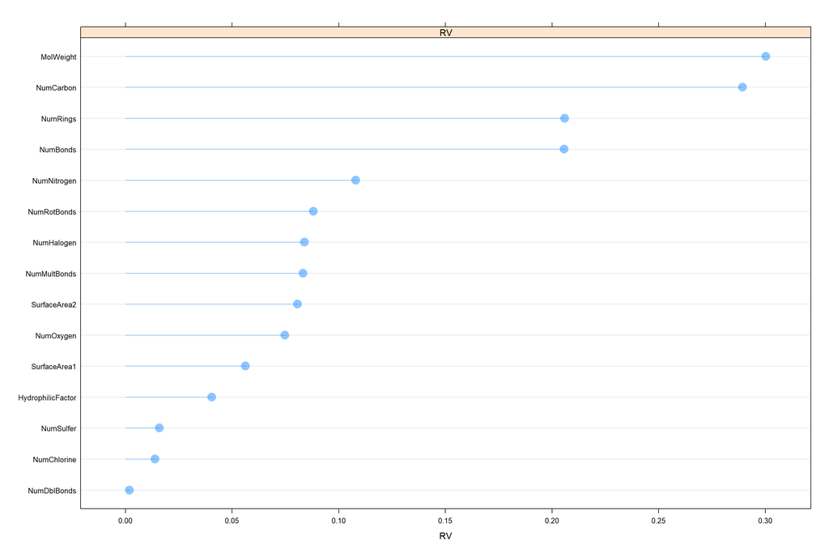

```r
##################################
# Exploring predictor performance
##################################
dotplot(Predictor ~ RV | Metric,
        RV_Summary,
        origin = 0,
        type = c("p", "h"),
        pch = 16,
        cex = 2,
        alpha = 0.45,
        prepanel = function(x, y) {
            list(ylim = levels(reorder(y, x)))
        },
        panel = function(x, y, ...) {
            panel.dotplot(x, reorder(y, x), ...)
        })
```

### 1.5.5 Volcano Plot - Fisher’s Exact Test (VP_F)

[Fisher’s Exact Test](https://www.semanticscholar.org/paper/019%3A-On-the-Interpretation-of-x2-from-Contingency-Fisher/2dfebf541541451c4200161214b4c6912ff3d4c2) tests contingency tables for homogeneity of proportion and determines if there are nonrandom associations between two categorical variables. To compute the P-value of the test, the tables must be ordered by some criterion that measures dependence, and those tables that represent equal or greater deviation from independence than the observed table are the ones whose probabilities are added together. The presence of low Fisher’s exact test p-values indicate the univariate association between the categorical predictors and the categorical response.  
**[A]** The volcano plot - Fisher’s Exact Test p-value was obtained using the **stats** package. High raw values of the negative logarithm of the metric, and the absolute log odds ratio indicate that the factor predictors were associated with the factor response.  
**[B]** The factor predictors which demonstrated the best feature importance in terms of the negative logarithm of the Fisher’s Exact Test p-value are as follows:  
**[B.1]** FP076 = 44.20850  
**[B.2]** FP089 = 31.66852  
**[B.3]** FP112 = 27.56836  
**[B.4]** FP172 = 23.86142  
**[B.5]** FP065 = 23.62888  
**[C]** The factor predictors which demonstrated the best feature importance in terms of the absolute log odds ratio are as follows:  
**[C.1]** FP044 = 2.911268  
**[C.2]** FP193 = 2.50206  
**[C.3]** FP172 = 2.09503  
**[C.4]** FP076 = 2.08379  
**[C.5]** FP184 = 1.98819

**Code Chunk | Output**

```r
##################################
# Filtering in the factor predictors
# with the numeric response variable
##################################
PMA_PreModelling_Train_Factor <- PMA_PreModelling_Train[,grepl("FP", names(PMA_PreModelling_Train))]
PMA_PreModelling_Train_Factor$Log_Solubility_Class <- PMA_PreModelling_Train$Log_Solubility
dim(PMA_PreModelling_Train_Factor)
```

```
## [1] 951 206
```

```r
str(PMA_PreModelling_Train_Factor)
```

```
## 'data.frame':    951 obs. of  206 variables:
##  $ FP001               : Factor w/ 2 levels "0","1": 1 1 2 1 1 2 1 2 2 2 ...
##  $ FP002               : Factor w/ 2 levels "0","1": 2 2 2 1 1 1 2 1 1 2 ...
##  $ FP003               : Factor w/ 2 levels "0","1": 1 1 2 2 2 2 1 2 2 2 ...
##  $ FP004               : Factor w/ 2 levels "0","1": 1 2 2 1 2 2 2 2 2 2 ...
##  $ FP005               : Factor w/ 2 levels "0","1": 2 2 2 1 2 1 2 1 1 2 ...
##  $ FP006               : Factor w/ 2 levels "0","1": 1 2 1 1 2 1 1 1 2 2 ...
##  $ FP007               : Factor w/ 2 levels "0","1": 1 2 1 2 1 1 1 2 2 2 ...
##  $ FP008               : Factor w/ 2 levels "0","1": 2 2 2 1 1 1 2 1 1 1 ...
##  $ FP009               : Factor w/ 2 levels "0","1": 1 1 1 1 2 2 2 1 2 1 ...
##  $ FP010               : Factor w/ 2 levels "0","1": 1 1 2 1 1 1 1 1 1 1 ...
##  $ FP011               : Factor w/ 2 levels "0","1": 1 2 1 1 1 1 1 1 2 1 ...
##  $ FP012               : Factor w/ 2 levels "0","1": 1 1 1 1 1 2 1 2 1 1 ...
##  $ FP013               : Factor w/ 2 levels "0","1": 1 1 1 1 2 1 2 1 1 1 ...
##  $ FP014               : Factor w/ 2 levels "0","1": 1 1 1 1 1 1 2 1 1 1 ...
```

[output cut: 86 more lines]

```r
summary(PMA_PreModelling_Train_Factor)
```

```
##  FP001   FP002   FP003   FP004   FP005   FP006   FP007   FP008   FP009
##  0:482   0:438   0:536   0:395   0:400   0:570   0:605   0:641   0:685
##  1:469   1:513   1:415   1:556   1:551   1:381   1:346   1:310   1:266
##  FP010   FP011   FP012   FP013   FP014   FP015   FP016   FP017   FP018
##  0:781   0:747   0:783   0:793   0:798   0:133   0:812   0:814   0:826
##  1:170   1:204   1:168   1:158   1:153   1:818   1:139   1:137   1:125
##  FP019   FP020   FP021   FP022   FP023   FP024   FP025   FP026   FP027
##  0:835   0:837   0:836   0:852   0:834   0:844   0:841   0:871   0:858
##  1:116   1:114   1:115   1: 99   1:117   1:107   1:110   1: 80   1: 93
##  FP028   FP029   FP030   FP031   FP032   FP033   FP034   FP035   FP036
##  0:850   0:854   0:862   0:866   0:881   0:885   0:875   0:882   0:879
##  1:101   1: 97   1: 89   1: 85   1: 70   1: 66   1: 76   1: 69   1: 72
##  FP037   FP038   FP039   FP040   FP041   FP042   FP043   FP044   FP045
##  0:884   0:869   0:880   0:886   0:891   0:897   0:888   0:894   0:898
##  1: 67   1: 82   1: 71   1: 65   1: 60   1: 54   1: 63   1: 57   1: 53
##  FP046   FP047   FP048   FP049   FP050   FP051   FP052   FP053   FP054
##  0:651   0:698   0:833   0:835   0:844   0:847   0:864   0:862   0:879
##  1:300   1:253   1:118   1:116   1:107   1:104   1: 87   1: 89   1: 72
##  FP055   FP056   FP057   FP058   FP059   FP060   FP061   FP062   FP063
##  0:900   0:889   0:837   0:843   0:899   0:493   0:526   0:535   0:546
##  1: 51   1: 62   1:114   1:108   1: 52   1:458   1:425   1:416   1:405
##  FP064   FP065   FP066   FP067   FP068   FP069   FP070   FP071   FP072
##  0:555   0:387   0:371   0:590   0:607   0:607   0:613   0:640   0:325
##  1:396   1:564   1:580   1:361   1:344   1:344   1:338   1:311   1:626
##  FP073   FP074   FP075   FP076   FP077   FP078   FP079   FP080   FP081
##  0:656   0:642   0:629   0:639   0:646   0:662   0:295   0:663   0:686
##  1:295   1:309   1:322   1:312   1:305   1:289   1:656   1:288   1:265
##  FP082   FP083   FP084   FP085   FP086   FP087   FP088   FP089   FP090
##  0:272   0:691   0:679   0:708   0:695   0:260   0:701   0:716   0:714
##  1:679   1:260   1:272   1:243   1:256   1:691   1:250   1:235   1:237
##  FP091   FP092   FP093   FP094   FP095   FP096   FP097   FP098   FP099
##  0:737   0:719   0:719   0:731   0:742   0:744   0:727   0:725   0:735
##  1:214   1:232   1:232   1:220   1:209   1:207   1:224   1:226   1:216
##  FP100   FP101   FP102   FP103   FP104   FP105   FP106   FP107   FP108
##  0:731   0:726   0:759   0:743   0:739   0:746   0:769   0:750   0:756
##  1:220   1:225   1:192   1:208   1:212   1:205   1:182   1:201   1:195
##  FP109   FP110   FP111   FP112   FP113   FP114   FP115   FP116   FP117
##  0:783   0:755   0:764   0:766   0:765   0:803   0:781   0:768   0:781
##  1:168   1:196   1:187   1:185   1:186   1:148   1:170   1:183   1:170
##  FP118   FP119   FP120   FP121   FP122   FP123   FP124   FP125   FP126
```

[output cut: 14 more lines]

```
##  FP164   FP165   FP166   FP167   FP168   FP169   FP170   FP171   FP172
##  0:354   0:619   0:636   0:639   0:318   0:774   0:776   0:790   0:807
##  1:597   1:332   1:315   1:312   1:633   1:177   1:175   1:161   1:144
##  FP173   FP174   FP175   FP176   FP177   FP178   FP179   FP180   FP181
##  0:816   0:827   0:823   0:835   0:836   0:836   0:858   0:849   0:862
##  1:135   1:124   1:128   1:116   1:115   1:115   1: 93   1:102   1: 89
##  FP182   FP183   FP184   FP185   FP186   FP187   FP188   FP189   FP190
##  0:857   0:879   0:871   0:870   0:878   0:882   0:886   0:878   0:882
##  1: 94   1: 72   1: 80   1: 81   1: 73   1: 69   1: 65   1: 73   1: 69
##  FP191   FP192   FP193   FP194   FP195   FP196   FP197   FP198   FP201
##  0:884   0:893   0:892   0:895   0:893   0:897   0:901   0:897   0:901
##  1: 67   1: 58   1: 59   1: 56   1: 58   1: 54   1: 50   1: 54   1: 50
##  FP202   FP203   FP204   FP205   FP206   FP207   FP208   Log_Solubility_Class
##  0:706   0:842   0:857   0:877   0:894   0:897   0:844   Low :427
##  1:245   1:109   1: 94   1: 74   1: 57   1: 54   1:107   High:524
```

```r
##################################
# Obtaining the Fisher exact test statistics
##################################
VP_F <- function(x, y){
  tab <- table(x, y)
  fet <- fisher.test(tab)
  out <- c(FET_OR = fet$estimate,
           FET_P.Value = fet$p.value)}

##################################
# Formulating the summary table
##################################
VP_F_Summary <- lapply(PMA_PreModelling_Train_Factor,
                       VP_F,
                       y = PMA_PreModelling_Train_Factor$Log_Solubility_Class)
VP_F_Summary <- as.data.frame(do.call("rbind", VP_F_Summary))
VP_F_Summary$Predictor <- names(PMA_PreModelling_Train_Factor)
VP_F_Summary <- VP_F_Summary[-nrow(VP_F_Summary),]
VP_F_Summary$Metric <- rep("VP_F", nrow(VP_F_Summary))
VP_F_Summary$NegativeLog10_FET_P.Value <- -log10(VP_F_Summary$FET_P.Value)
VP_F_Summary$LogOddsRatio <- log(VP_F_Summary[,1])
VP_F_Summary$AbsoluteLogOddsRatio <- abs(VP_F_Summary$LogOddsRatio)

VP_F_Summary$Group <- ifelse(rownames(VP_F_Summary)=="FP076","FP076",
                             ifelse(rownames(VP_F_Summary)=="FP089","FP089",
                                    ifelse(rownames(VP_F_Summary)=="FP112","FP112",
                                           ifelse(rownames(VP_F_Summary)=="FP044","FP044",
                                                  ifelse(rownames(VP_F_Summary)=="FP193","FP193",
                                                         "Others")))))

VP_F_Summary
```

```
##       FET_OR.odds ratio  FET_P.Value Predictor Metric NegativeLog10_FET_P.Value
## FP001        1.19708080 1.715372e-01     FP001   VP_F              7.656418e-01
## FP002        0.35039786 5.181602e-15     FP002   VP_F              1.428554e+01
## FP003        0.97166586 8.438406e-01     FP003   VP_F              7.373956e-02
## FP004        1.26919078 7.435063e-02     FP004   VP_F              1.128715e+00
## FP005        0.35435518 2.273432e-14     FP005   VP_F              1.364332e+01
## FP006        1.84346020 5.972899e-06     FP006   VP_F              5.223815e+00
## FP007        0.88537336 3.789438e-01     FP007   VP_F              4.214252e-01
## FP008        0.57340983 7.203997e-05     FP008   VP_F              4.142426e+00
## FP009        0.26982672 1.890323e-18     FP009   VP_F              1.772346e+01
## FP010        1.57515069 1.057248e-02     FP010   VP_F              1.975823e+00
## FP011        1.90083496 9.542912e-05     FP011   VP_F              4.020319e+00
## FP012        1.10579162 6.082058e-01     FP012   VP_F              2.159494e-01
## FP013        0.14883782 2.727491e-23     FP013   VP_F              2.256424e+01
## FP014        0.15750978 9.678623e-22     FP014   VP_F              2.101419e+01
## FP015        2.86928927 5.561892e-08     FP015   VP_F              7.254777e+00
## FP016        0.85604079 4.075094e-01     FP016   VP_F              3.898624e-01
## FP017        0.49376123 1.883936e-04     FP017   VP_F              3.724934e+00
## FP018        0.47679807 1.545802e-04     FP018   VP_F              3.810846e+00
## FP019        1.04400654 8.428105e-01     FP019   VP_F              7.427005e-02
## FP020        1.28698533 2.293994e-01     FP020   VP_F              6.394076e-01
## FP021        0.74658209 1.614886e-01     FP021   VP_F              7.918582e-01
## FP022        1.02076928 1.000000e+00     FP022   VP_F              4.821637e-17
## FP023        0.54497814 2.790955e-03     FP023   VP_F              2.554247e+00
## FP024        1.09109789 6.815917e-01     FP024   VP_F              1.664757e-01
## FP025        1.30887702 2.213225e-01     FP025   VP_F              6.549744e-01
## FP026        0.64245234 6.095878e-02     FP026   VP_F              1.214964e+00
## FP027        2.01654412 2.893976e-03     FP027   VP_F              2.538505e+00
## FP028        1.21715865 3.977531e-01     FP028   VP_F              4.003864e-01
## FP029        0.85300530 5.182871e-01     FP029   VP_F              2.854296e-01
## FP030        1.42811535 1.453412e-01     FP030   VP_F              8.376114e-01
## FP031        0.81964988 4.241544e-01     FP031   VP_F              3.724760e-01
## FP032        1.72977657 4.512846e-02     FP032   VP_F              1.345550e+00
## FP033        1.56955042 9.624740e-02     FP033   VP_F              1.016611e+00
## FP034        0.71399401 1.858759e-01     FP034   VP_F              7.307769e-01
## FP035        0.28405176 2.035732e-06     FP035   VP_F              5.691279e+00
## FP036        2.60842408 4.826361e-04     FP036   VP_F              3.316380e+00
## FP037        0.60007108 5.538991e-02     FP037   VP_F              1.256569e+00
## FP038        1.37688518 2.016885e-01     FP038   VP_F              6.953188e-01
## FP039        0.27168922 7.256956e-07     FP039   VP_F              6.139246e+00
```

[output cut: 357 more lines]

```
## FP192 -0.664508453          0.664508453 Others
## FP193 -2.502059785          2.502059785  FP193
## FP194  0.165810490          0.165810490 Others
## FP195  1.314151018          1.314151018 Others
## FP196 -1.906569334          1.906569334 Others
## FP197 -1.803058135          1.803058135 Others
## FP198  0.696686345          0.696686345 Others
## FP201  0.577374992          0.577374992 Others
## FP202 -0.642880476          0.642880476 Others
## FP203 -0.044255912          0.044255912 Others
## FP204 -0.608357895          0.608357895 Others
## FP205 -1.150680746          1.150680746 Others
## FP206 -0.790054693          0.790054693 Others
## FP207 -1.906569334          1.906569334 Others
## FP208 -0.082967663          0.082967663 Others
```

```r
##################################
# Selecting the best-performing
# predictors based from metrics
##################################
VP_F_Summary_Top15_FETPValue <- VP_F_Summary[order(VP_F_Summary$NegativeLog10_FET_P.Value,decreasing=TRUE),]
(VP_F_Summary_Top15_FETPValue <- VP_F_Summary_Top15_FETPValue[1:15,])
```

```
##       FET_OR.odds ratio  FET_P.Value Predictor Metric NegativeLog10_FET_P.Value
## FP076         0.1244571 6.187262e-45     FP076   VP_F                  44.20850
## FP089         0.1472122 2.145272e-32     FP089   VP_F                  31.66852
## FP112         0.1379398 2.701713e-28     FP112   VP_F                  27.56836
## FP172         0.1230654 1.375876e-24     FP172   VP_F                  23.86142
## FP065         0.2425985 2.350296e-24     FP065   VP_F                  23.62888
## FP013         0.1488378 2.727491e-23     FP013   VP_F                  22.56424
## FP079         0.2239833 6.263011e-23     FP079   VP_F                  22.20322
## FP092         0.2089925 6.412816e-23     FP092   VP_F                  22.19295
## FP082         0.2217568 7.799605e-22     FP082   VP_F                  21.10793
## FP014         0.1575098 9.678623e-22     FP014   VP_F                  21.01419
## FP168         0.2467345 1.869134e-21     FP168   VP_F                  20.72836
## FP169         0.1958171 3.513565e-20     FP169   VP_F                  19.45425
## FP070         0.2794757 5.654858e-20     FP070   VP_F                  19.24758
## FP009         0.2698267 1.890323e-18     FP009   VP_F                  17.72346
## FP164         0.2931674 3.185855e-18     FP164   VP_F                  17.49677
##       LogOddsRatio AbsoluteLogOddsRatio  Group
## FP076    -2.083795             2.083795  FP076
## FP089    -1.915880             1.915880  FP089
## FP112    -1.980938             1.980938  FP112
## FP172    -2.095039             2.095039 Others
## FP065    -1.416348             1.416348 Others
## FP013    -1.904898             1.904898 Others
## FP079    -1.496184             1.496184 Others
## FP092    -1.565457             1.565457 Others
## FP082    -1.506174             1.506174 Others
## FP014    -1.848268             1.848268 Others
## FP168    -1.399442             1.399442 Others
## FP169    -1.630574             1.630574 Others
## FP070    -1.274840             1.274840 Others
## FP009    -1.309975             1.309975 Others
## FP164    -1.227011             1.227011 Others
```

```r
VP_F_Summary_Top15_AbsoluteLogOddsRatio <- VP_F_Summary[order(VP_F_Summary$AbsoluteLogOddsRatio,decreasing=TRUE),]
(VP_F_Summary_Top15_AbsoluteLogOddsRatio <- VP_F_Summary_Top15_AbsoluteLogOddsRatio[1:15,])
```

```
##       FET_OR.odds ratio  FET_P.Value Predictor Metric NegativeLog10_FET_P.Value
## FP044        0.05440672 3.102624e-15     FP044   VP_F                 14.508271
## FP193        0.08191610 1.128789e-13     FP193   VP_F                 12.947387
## FP172        0.12306538 1.375876e-24     FP172   VP_F                 23.861421
## FP076        0.12445706 6.187262e-45     FP076   VP_F                 44.208501
## FP184        0.13694274 1.118373e-13     FP184   VP_F                 12.951413
## FP112        0.13793978 2.701713e-28     FP112   VP_F                 27.568361
## FP089        0.14721223 2.145272e-32     FP089   VP_F                 31.668518
## FP196        0.14858927 3.201577e-09     FP196   VP_F                  8.494636
## FP207        0.14858927 3.201577e-09     FP207   VP_F                  8.494636
## FP013        0.14883782 2.727491e-23     FP013   VP_F                 22.564237
## FP014        0.15750978 9.678623e-22     FP014   VP_F                 21.014186
## FP197        0.16479415 4.266746e-08     FP197   VP_F                  7.369903
## FP149        0.17427309 2.945871e-12     FP149   VP_F                 11.530786
## FP190        0.18597681 1.732961e-09     FP190   VP_F                  8.761211
## FP169        0.19581712 3.513565e-20     FP169   VP_F                 19.454252
##       LogOddsRatio AbsoluteLogOddsRatio  Group
## FP044    -2.911268             2.911268  FP044
## FP193    -2.502060             2.502060  FP193
## FP172    -2.095039             2.095039 Others
## FP076    -2.083795             2.083795  FP076
## FP184    -1.988192             1.988192 Others
## FP112    -1.980938             1.980938  FP112
## FP089    -1.915880             1.915880  FP089
## FP196    -1.906569             1.906569 Others
## FP207    -1.906569             1.906569 Others
## FP013    -1.904898             1.904898 Others
## FP014    -1.848268             1.848268 Others
## FP197    -1.803058             1.803058 Others
## FP149    -1.747132             1.747132 Others
## FP190    -1.682133             1.682133 Others
## FP169    -1.630574             1.630574 Others
```

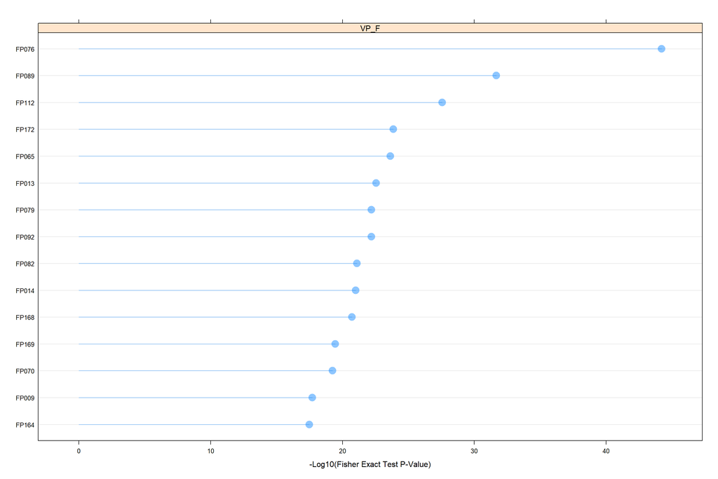

```r
##################################
# Exploring predictor performance
##################################
dotplot(Predictor ~ NegativeLog10_FET_P.Value | Metric,
        VP_F_Summary_Top15_FETPValue,
        origin = 0,
        xlab = "-Log10(Fisher Exact Test P-Value)",
        type = c("p","h"),
        pch = 16,
        cex = 2,
        alpha = 0.45,
        prepanel = function(x, y) {
            list(ylim = levels(reorder(y, x)))
        },
        panel = function(x, y, ...) {
            panel.dotplot(x, reorder(y, x), ...)
        })
```

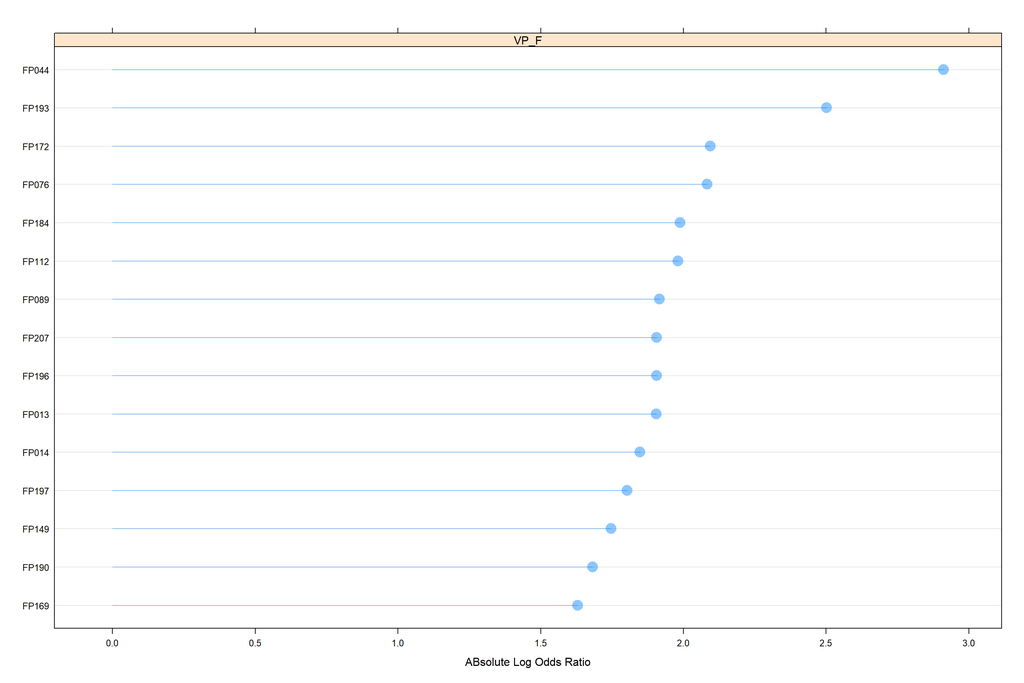

```r
dotplot(Predictor ~ AbsoluteLogOddsRatio | Metric,
        VP_F_Summary_Top15_AbsoluteLogOddsRatio,
        origin = 0,
        xlab = "ABsolute Log Odds Ratio",
        type = c("p", "h"),
        pch = 16,
        cex = 2,
        alpha = 0.45,
        prepanel = function(x, y) {
            list(ylim = levels(reorder(y, x)))
        },
        panel = function(x, y, ...) {
            panel.dotplot(x, reorder(y, x), ...)
        })
```

### 1.5.6 Volcano Plot - Gain Ratio (VP_G)

**Code Chunk | Output**

```r
##################################
# Obtaining the gain ratio
##################################
VP_G <- function(x, y){
  tab <- table(x, y)
  fet <- fisher.test(tab)
  out <- c(FET_OR = fet$estimate,
           Gain = attrEval(y ~ x, estimator="GainRatio"))}

##################################
# Formulating the summary table
##################################
VP_G_Summary <- lapply(PMA_PreModelling_Train_Factor,
                       VP_G,
                       y = PMA_PreModelling_Train_Factor$Log_Solubility_Class)
VP_G_Summary <- as.data.frame(do.call("rbind", VP_G_Summary))
VP_G_Summary$Gain <- VP_G_Summary$Gain.x
VP_G_Summary$Gain.x <- NULL
VP_G_Summary$Predictor <- names(PMA_PreModelling_Train_Factor)
VP_G_Summary <- VP_G_Summary[-nrow(VP_G_Summary),]
VP_G_Summary$Metric <- rep("VP_G", nrow(VP_G_Summary))
VP_G_Summary$LogOddsRatio <- log(VP_G_Summary[,1])
VP_G_Summary$AbsoluteLogOddsRatio <- abs(VP_G_Summary$LogOddsRatio)

VP_G_Summary$Group <- ifelse(rownames(VP_G_Summary)=="FP076","FP076",
                             ifelse(rownames(VP_G_Summary)=="FP089","FP089",
                                    ifelse(rownames(VP_G_Summary)=="FP172","FP172",
                                           ifelse(rownames(VP_G_Summary)=="FP044","FP044",
                                                  ifelse(rownames(VP_G_Summary)=="FP193","FP193",
                                                         "Others")))))

VP_G_Summary
```

```
##       FET_OR.odds ratio         Gain Predictor Metric LogOddsRatio
## FP001        1.19708080 1.444996e-03     FP001   VP_G  0.179885927
## FP002        0.35039786 4.708223e-02     FP002   VP_G -1.048686041
## FP003        0.97166586 3.674512e-05     FP003   VP_G -0.028743299
## FP004        1.26919078 2.522331e-03     FP004   VP_G  0.238379513
## FP005        0.35435518 4.551018e-02     FP005   VP_G -1.037455546
## FP006        1.84346020 1.618232e-02     FP006   VP_G  0.611644351
## FP007        0.88537336 6.497937e-04     FP007   VP_G -0.121745848
## FP008        0.57340983 1.334323e-02     FP008   VP_G -0.556154591
## FP009        0.26982672 6.919817e-02     FP009   VP_G -1.309975319
## FP010        1.57515069 7.731544e-03     FP010   VP_G  0.454350945
## FP011        1.90083496 1.575628e-02     FP011   VP_G  0.642293242
## FP012        1.10579162 3.890917e-04     FP012   VP_G  0.100561473
## FP013        0.14883782 1.170524e-01     FP013   VP_G -1.904898041
## FP014        0.15750978 1.104560e-01     FP014   VP_G -1.848267748
## FP015        2.86928927 3.948765e-02     FP015   VP_G  1.054064357
## FP016        0.85604079 9.035850e-04     FP016   VP_G -0.155437247
## FP017        0.49376123 1.837501e-02     FP017   VP_G -0.705703211
## FP018        0.47679807 1.979839e-02     FP018   VP_G -0.740662219
## FP019        1.04400654 6.620556e-05     FP019   VP_G  0.043065754
## FP020        1.28698533 2.228941e-03     FP020   VP_G  0.252302533
## FP021        0.74658209 3.076260e-03     FP021   VP_G -0.292249695
## FP022        1.02076928 1.460657e-05     FP022   VP_G  0.020556543
## FP023        0.54497814 1.321735e-02     FP023   VP_G -0.607009590
## FP024        1.09109789 2.662594e-04     FP024   VP_G  0.087184424
## FP025        1.30887702 2.513100e-03     FP025   VP_G  0.269169534
## FP026        0.64245234 6.517365e-03     FP026   VP_G -0.442462641
## FP027        2.01654412 1.547364e-02     FP027   VP_G  0.701385217
## FP028        1.21715865 1.323858e-03     FP028   VP_G  0.196519164
## FP029        0.85300530 8.767322e-04     FP029   VP_G -0.158989520
## FP030        1.42811535 4.164198e-03     FP030   VP_G  0.356355635
## FP031        0.81964988 1.335234e-03     FP031   VP_G -0.198878004
## FP032        1.72977657 9.085596e-03     FP032   VP_G  0.547992253
## FP033        1.56955042 6.160663e-03     FP033   VP_G  0.450789220
## FP034        0.71399401 3.744446e-03     FP034   VP_G -0.336880708
## FP035        0.28405176 4.681628e-02     FP035   VP_G -1.258598799
## FP036        2.60842408 2.580646e-02     FP036   VP_G  0.958746238
## FP037        0.60007108 8.341477e-03     FP037   VP_G -0.510707161
## FP038        1.37688518 3.308563e-03     FP038   VP_G  0.319823833
## FP039        0.27168922 5.011275e-02     FP039   VP_G -1.303096431
```

[output cut: 357 more lines]

```
## FP192          0.664508453 Others
## FP193          2.502059785  FP193
## FP194          0.165810490 Others
## FP195          1.314151018 Others
## FP196          1.906569334 Others
## FP197          1.803058135 Others
## FP198          0.696686345 Others
## FP201          0.577374992 Others
## FP202          0.642880476 Others
## FP203          0.044255912 Others
## FP204          0.608357895 Others
## FP205          1.150680746 Others
## FP206          0.790054693 Others
## FP207          1.906569334 Others
## FP208          0.082967663 Others
```

```r
##################################
# Selecting the best-performing
# predictors based from metrics
##################################
VP_G_Summary_Top15_Gain <- VP_G_Summary[order(VP_G_Summary$Gain,decreasing=TRUE),]
(VP_G_Summary_Top15_Gain <- VP_G_Summary_Top15_Gain[1:15,])
```

```
##       FET_OR.odds ratio       Gain Predictor Metric LogOddsRatio
## FP076        0.12445706 0.16518193     FP076   VP_G    -2.083795
## FP044        0.05440672 0.14857995     FP044   VP_G    -2.911268
## FP089        0.14721223 0.13291055     FP089   VP_G    -1.915880
## FP172        0.12306538 0.13177523     FP172   VP_G    -2.095039
## FP112        0.13793978 0.13074132     FP112   VP_G    -1.980938
## FP193        0.08191610 0.12758720     FP193   VP_G    -2.502060
## FP013        0.14883782 0.11705243     FP013   VP_G    -1.904898
## FP014        0.15750978 0.11045599     FP014   VP_G    -1.848268
## FP184        0.13694274 0.10251539     FP184   VP_G    -1.988192
## FP169        0.19581712 0.09334163     FP169   VP_G    -1.630574
## FP092        0.20899251 0.09317801     FP092   VP_G    -1.565457
## FP196        0.14858927 0.08701108     FP196   VP_G    -1.906569
## FP207        0.14858927 0.08701108     FP207   VP_G    -1.906569
## FP149        0.17427309 0.08590156     FP149   VP_G    -1.747132
## FP049        0.19582389 0.08320908     FP049   VP_G    -1.630540
##       AbsoluteLogOddsRatio  Group
## FP076             2.083795  FP076
## FP044             2.911268  FP044
## FP089             1.915880  FP089
## FP172             2.095039  FP172
## FP112             1.980938 Others
## FP193             2.502060  FP193
## FP013             1.904898 Others
## FP014             1.848268 Others
## FP184             1.988192 Others
## FP169             1.630574 Others
## FP092             1.565457 Others
## FP196             1.906569 Others
## FP207             1.906569 Others
## FP149             1.747132 Others
## FP049             1.630540 Others
```

```r
VP_G_Summary_Top15_AbsoluteLogOddsRatio <- VP_G_Summary[order(VP_G_Summary$AbsoluteLogOddsRatio,decreasing=TRUE),]
(VP_G_Summary_Top15_AbsoluteLogOddsRatio <- VP_G_Summary_Top15_AbsoluteLogOddsRatio[1:15,])
```

```
##       FET_OR.odds ratio       Gain Predictor Metric LogOddsRatio
## FP044        0.05440672 0.14857995     FP044   VP_G    -2.911268
## FP193        0.08191610 0.12758720     FP193   VP_G    -2.502060
## FP172        0.12306538 0.13177523     FP172   VP_G    -2.095039
## FP076        0.12445706 0.16518193     FP076   VP_G    -2.083795
## FP184        0.13694274 0.10251539     FP184   VP_G    -1.988192
## FP112        0.13793978 0.13074132     FP112   VP_G    -1.980938
## FP089        0.14721223 0.13291055     FP089   VP_G    -1.915880
## FP196        0.14858927 0.08701108     FP196   VP_G    -1.906569
## FP207        0.14858927 0.08701108     FP207   VP_G    -1.906569
## FP013        0.14883782 0.11705243     FP013   VP_G    -1.904898
## FP014        0.15750978 0.11045599     FP014   VP_G    -1.848268
## FP197        0.16479415 0.07859039     FP197   VP_G    -1.803058
## FP149        0.17427309 0.08590156     FP149   VP_G    -1.747132
## FP190        0.18597681 0.07641501     FP190   VP_G    -1.682133
## FP169        0.19581712 0.09334163     FP169   VP_G    -1.630574
##       AbsoluteLogOddsRatio  Group
## FP044             2.911268  FP044
## FP193             2.502060  FP193
## FP172             2.095039  FP172
## FP076             2.083795  FP076
## FP184             1.988192 Others
## FP112             1.980938 Others
## FP089             1.915880  FP089
## FP196             1.906569 Others
## FP207             1.906569 Others
## FP013             1.904898 Others
## FP014             1.848268 Others
## FP197             1.803058 Others
## FP149             1.747132 Others
## FP190             1.682133 Others
## FP169             1.630574 Others
```

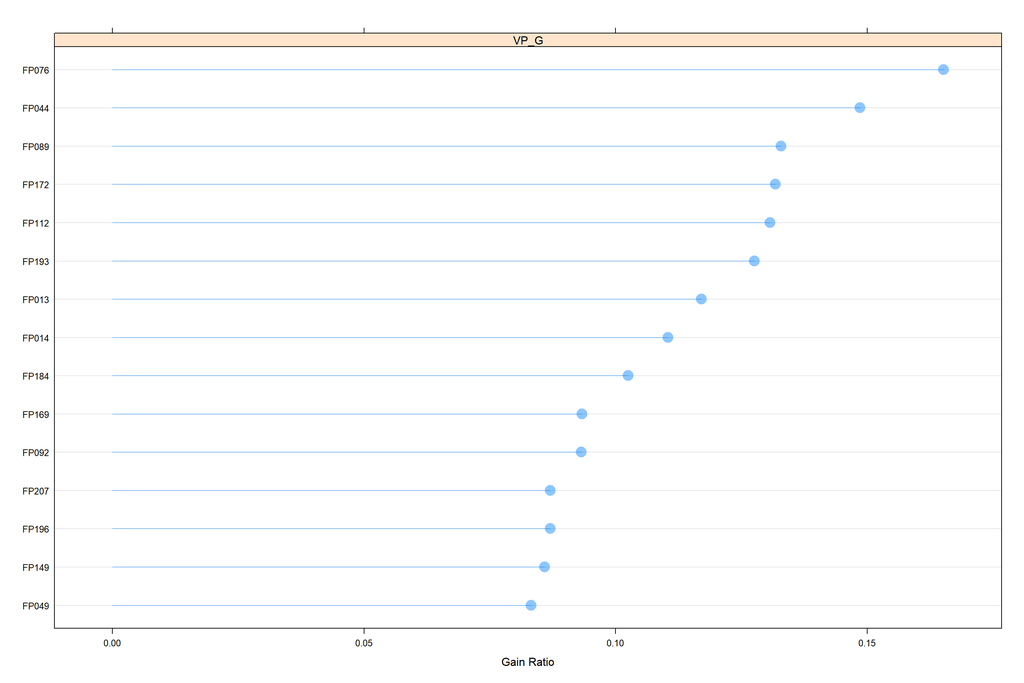

```r
##################################
# Exploring predictor performance
##################################
dotplot(Predictor ~ Gain | Metric,
        VP_G_Summary_Top15_Gain,
        origin = 0,
        xlab = "Gain Ratio",
        type = c("p", "h"),
        pch = 16,
        cex = 2,
        alpha = 0.45,
        prepanel = function(x, y) {
            list(ylim = levels(reorder(y, x)))
        },
        panel = function(x, y, ...) {
            panel.dotplot(x, reorder(y, x), ...)
        })
```

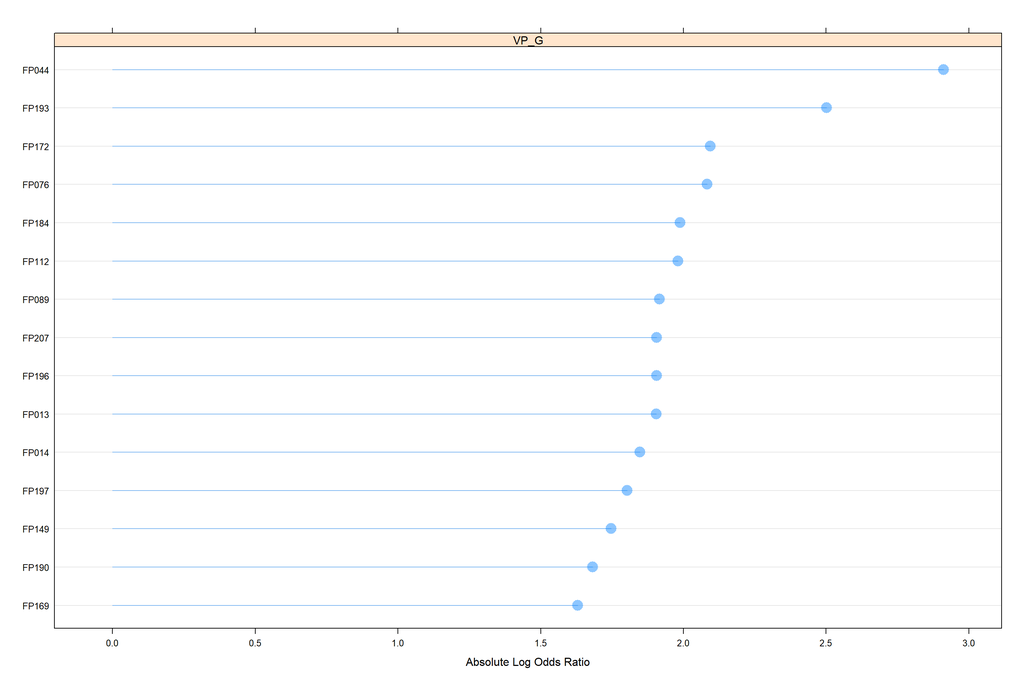

```r
dotplot(Predictor ~ AbsoluteLogOddsRatio | Metric,
        VP_G_Summary_Top15_AbsoluteLogOddsRatio,
        origin = 0,
        xlab = "Absolute Log Odds Ratio",
        type = c("p", "h"),
        pch = 16,
        cex = 2,
        alpha = 0.45,
        prepanel = function(x, y) {
            list(ylim = levels(reorder(y, x)))
        },
        panel = function(x, y, ...) {
            panel.dotplot(x, reorder(y, x), ...)
        })
```

## 1.6 Consolidated Findings

**[A]** The model-independent feature importance for all numeric predictors were evaluated in terms of the following metrics:  
**[A.1]** **AUROC: Area Under the Receiver Operating Characteristics Curve** (**caret** package)  
**[A.2]** **ATS : Absolute T-Test Statistic** (**stats** package)  
**[A.3]** **MIC: Maximal Information Coefficient** (**minerva** package)  
**[A.4]** **RV: Relief Values** (**CORElearn** package)  
**[B]** The numeric predictors which demonstrated the most consistent feature importance across the given metrics are as follows:  
**[B.1]** MolWeight  
**[B.2]** NumCarbon  
**[B.3]** NumMultBonds  
**[B.4]** NumBonds  
**[B.5]** NumRings  
**[C]** The model-independent feature importance for all factor predictors were evaluated in terms of the following metrics:  
**[C.1]** **VP_F: Volcano Plot - Fisher’s Exact Test** (**stats** package)  
**[C.2]** **VP_G: Volcano Plot - Gain Ratio** (**CORElearn** package)  
**[D]** The factor predictors which demonstrated the most consistent feature importance across the given metrics are as follows:  
**[D.1]** FP076  
**[D.2]** FP044  
**[D.3]** FP089  
**[D.4]** FP193  
**[D.5]** FP112

**Code Chunk | Output**

```r
##################################
# Consolidating all performance metrics
# for the numeric predictors
##################################
NumericPredictor_Metrics <- cbind(AUROC_Summary$AUROC,
                                  ATS_Summary$ATS,
                                  MIC_Summary$MIC,
                                  RV_Summary$RV)

colnames(NumericPredictor_Metrics) <- c("AUROC",
                                        "ATS",
                                        "MIC",
                                        "RV")

rownames(NumericPredictor_Metrics) <- names(PMA_PreModelling_Train_Numeric)[2:ncol(PMA_PreModelling_Train_Numeric)]

NumericPredictor_Metrics <- as.data.frame(NumericPredictor_Metrics)

NumericPredictor_Metrics$Group <- ifelse(rownames(NumericPredictor_Metrics)=="MolWeight","MolWeight",
                                         ifelse(rownames(NumericPredictor_Metrics)=="NumCarbon","NumCarbon",
                                                ifelse(rownames(NumericPredictor_Metrics)=="NumMultBonds","NumMultBonds",
                                                       ifelse(rownames(NumericPredictor_Metrics)=="NumBonds","NumBonds",
                                                              ifelse(rownames(NumericPredictor_Metrics)=="NumRings","NumRings",
                                                                     "Others")))))

NumericPredictor_Metrics
```

```
##                       AUROC        ATS        MIC         RV        Group
## MolWeight         0.8441930 22.0675750 0.46368934 0.30039075    MolWeight
## NumBonds          0.7893255 16.4907720 0.28498465 0.20575373     NumBonds
## NumMultBonds      0.7230098 13.0920514 0.19005119 0.08333333 NumMultBonds
## NumRotBonds       0.5847695  5.8690062 0.03861351 0.08825000       Others
## NumDblBonds       0.5142035  1.9672950 0.01133118 0.00200000       Others
## NumCarbon         0.8408857 21.0036355 0.31544845 0.28938624    NumCarbon
## NumNitrogen       0.5285634  0.8247139 0.01995159 0.10800000       Others
## NumOxygen         0.5536988  0.9312510 0.07491145 0.07476923       Others
## NumSulfer         0.5317902  3.2021823 0.01254889 0.01600000       Others
## NumChlorine       0.6104904  8.3362925 0.07010055 0.01400000       Others
## NumHalogen        0.6381755  9.1800512 0.08459159 0.08400000       Others
## NumRings          0.7438569 14.3956856 0.16421351 0.20600000     NumRings
## HydrophilicFactor 0.6699367  7.3321483 0.32734124 0.04048816       Others
## SurfaceArea1      0.5726889  2.5597702 0.19959108 0.05630307       Others
## SurfaceArea2      0.5479915  1.1459666 0.22267432 0.08079488       Others
```

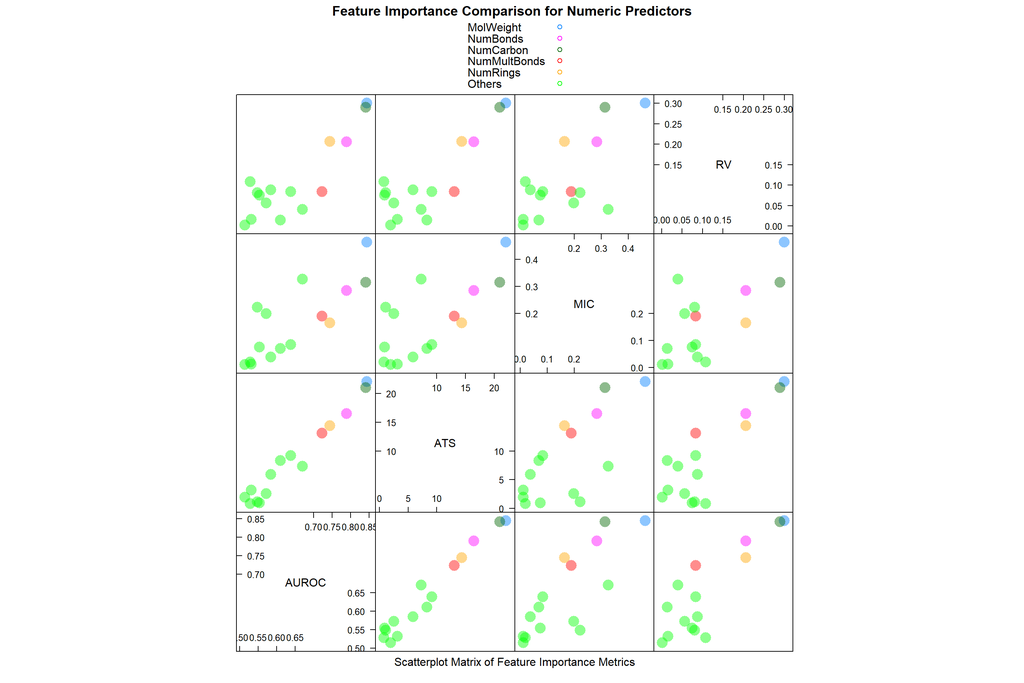

```r
splom(~NumericPredictor_Metrics[,c(1:4)],
      groups = NumericPredictor_Metrics$Group,
      pch = 16,
      cex = 2,
      alpha = 0.45,
      varnames = c("AUROC", "ATS", "MIC", "RV"),
      auto.key = list(points = TRUE, space = "top"),
      main = "Feature Importance Comparison for Numeric Predictors",
      xlab = "Scatterplot Matrix of Feature Importance Metrics")
```

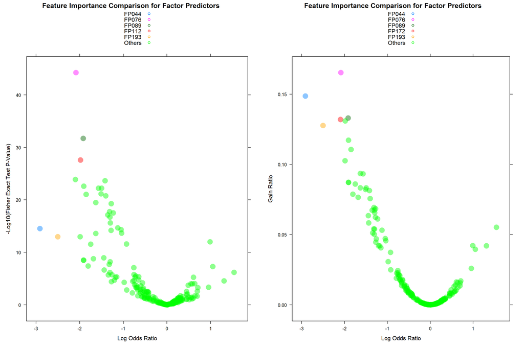

```r
##################################
# Consolidating all performance metrics
# for the factor predictors
##################################
FET_P.Value_Plot <- xyplot(NegativeLog10_FET_P.Value ~ LogOddsRatio,
       groups = VP_F_Summary$Group,
       data = VP_F_Summary,
       xlab = "Log Odds Ratio",
       ylab = "-Log10(Fisher Exact Test P-Value)",
       type = "p",
       pch = 16,
       cex = 2,
       alpha = 0.45,
       auto.key = list(points = TRUE, space = "top"),
       main = "Feature Importance Comparison for Factor Predictors")

Gain_Plot <- xyplot(Gain ~ LogOddsRatio,
       groups = VP_G_Summary$Group,
       data = VP_G_Summary,
       xlab = "Log Odds Ratio",
       ylab = "Gain Ratio",
       type = "p",
       pch = 16,
       cex = 2,
       alpha = 0.45,
       auto.key = list(points = TRUE, space = "top"),
       main = "Feature Importance Comparison for Factor Predictors")

grid.arrange(FET_P.Value_Plot,
             Gain_Plot,
             ncol = 2)
```

# **2. Summary**

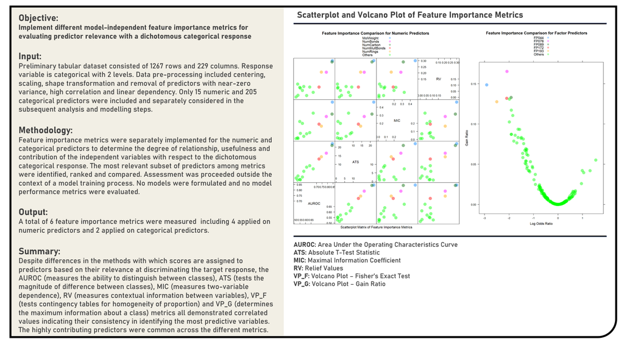

# **3. References**

**[Book]** [Applied Predictive Modeling](http://appliedpredictivemodeling.com/) by Max Kuhn and Kjell Johnson  
**[Book]** [An Introduction to Statistical Learning](https://www.statlearning.com/) by Gareth James, Daniela Witten, Trevor Hastie and Rob Tibshirani  
**[Book]** [Multivariate Data Visualization with R](http://lmdvr.r-forge.r-project.org/figures/figures.html) by Deepayan Sarkar  
**[Book]** [Machine Learning](https://bookdown.org/ssjackson300/Machine-Learning-Lecture-Notes/) by Samuel Jackson  
**[Book]** [Data Modeling Methods](https://bookdown.org/larget_jacob/data-modeling-methods/) by Jacob Larget  
**[Book]** [Introduction to R](https://biocorecrg.github.io/CRG_RIntroduction/) by Sara Bonnin  
**[R Package]** [AppliedPredictiveModeling](https://cran.r-project.org/web//packages/AppliedPredictiveModeling/AppliedPredictiveModeling.pdf) by Max Kuhn  
**[R Package]** [caret](https://topepo.github.io/caret/index.html) by Max Kuhn  
**[R Package]** [rpart](https://mran.microsoft.com/web/packages/rpart/rpart.pdf) by Terry Therneau and Beth Atkinson  
**[R Package]** [lattice](https://cran.r-project.org/web/packages/lattice/lattice.pdf) by Deepayan Sarkar  
**[R Package]** [dplyr](https://cran.r-project.org/web/packages/dplyr/index.html/) by Hadley Wickham  
**[R Package]** [moments](https://cran.r-project.org/web/packages/moments/index.html) by Lukasz Komsta and Frederick  
**[R Package]** [skimr](https://cran.r-project.org/web/packages/skimr/skimr.pdf) by Elin Waring  
**[R Package]** [RANN](https://cran.r-project.org/web/packages/RANN/RANN.pdf) by Sunil Arya, David Mount, Samuel Kemp and Gregory Jefferis  
**[R Package]** [corrplot](https://cran.r-project.org/web/packages/corrplot/corrplot.pdf) by Taiyun Wei  
**[R Package]** [tidyverse](https://cran.r-project.org/web/packages/tidyverse/tidyverse.pdf) by Hadley Wickham  
**[R Package]** [lares](https://cran.rstudio.com/web/packages/lares/lares.pdf) by Bernardo Lares  
**[R Package]** [DMwR](https://mran.microsoft.com/snapshot/2016-05-02/web/packages/DMwR/DMwR.pdf) by Luis Torgo  
**[R Package]** [gridExtra](https://cran.r-project.org/web/packages/gridExtra/gridExtra.pdf) by Baptiste Auguie and Anton Antonov  
**[R Package]** [rattle](https://cran.r-project.org/web/packages/rattle/rattle.pdf) by Graham Williams  
**[R Package]** [rpart.plot](https://cran.r-project.org/web/packages/rpart.plot/rpart.plot.pdf) by Stephen Milborrow  
**[R Package]** [RColorBrewer](https://cran.r-project.org/web//packages/RColorBrewer/RColorBrewer.pdf) by Erich Neuwirth  
**[R Package]** [stats](https://search.r-project.org/R/refmans/stats/html/00Index.html) by R Core Team  
**[R Package]** [pls](https://cran.r-project.org/web/packages/pls/pls.pdf) by Kristian Hovde Liland  
**[R Package]** [nnet](https://cran.r-project.org/web/packages/nnet/nnet.pdf) by Brian Ripley  
**[R Package]** [elasticnet](https://cran.r-project.org/web/packages/elasticnet/elasticnet.pdf) by Hui Zou  
**[R Package]** [earth](https://cran.r-project.org/web/packages/earth/earth.pdf) by Stephen Milborrow  
**[R Package]** [party](https://cran.r-project.org/web/packages/party/party.pdf) by Torsten Hothorn  
**[R Package]** [kernlab](https://cran.r-project.org/web/packages/kernlab/kernlab.pdf) by Alexandros Karatzoglou  
**[R Package]** [randomForest](https://cran.r-project.org/web/packages/randomForest/randomForest.pdf) by Andy Liaw  
**[R Package]** [Cubist](https://cran.r-project.org/web/packages/Cubist/Cubist.pdf) by Max Kuhn  
**[R Package]** [minerva](https://cran.r-project.org/web/packages/minerva/minerva.pdf) by Michele Filosi  
**[R Package]** [CORElearn](https://cran.r-project.org/web/packages/CORElearn/CORElearn.pdf) by Marko Robnik-Sikonja and Petr Savicky  
**[Article]** [The caret Package](https://topepo.github.io/caret/index.html) by Max Kuhn  
**[Article]** [A Short Introduction to the caret Package](https://cran.r-project.org/web/packages/caret/vignettes/caret.html) by Max Kuhn  
**[Article]** Caret Package – A Practical Guide to Machine Learning in R by Selva Prabhakaran  
**[Article]** [Tuning Machine Learning Models Using the Caret R Package](https://machinelearningmastery.com/tuning-machine-learning-models-using-the-caret-r-package/) by Jason Brownlee  
**[Article]** [Lattice Graphs](http://www.sthda.com/english/wiki/lattice-graphs) by STHDA Team  
**[Article]** [A Tour of Machine Learning Algorithms](https://machinelearningmastery.com/a-tour-of-machine-learning-algorithms/) by Jason Brownlee  
**[Article]** [Maximal Information Coefficient](https://www.r-bloggers.com/2014/09/maximal-information-coefficient-part-ii/) by R Bloggers Team  
**[Article]** [Understanding t-Tests: 1-sample, 2-sample, and Paired t-Tests](https://blog.minitab.com/en/adventures-in-statistics-2/understanding-t-tests-1-sample-2-sample-and-paired-t-tests) by Minitab Support Team  
**[Article]** [How to Interpret a ROC Curve (With Examples)](https://www.statology.org/interpret-roc-curve/) by Statology Team  
**[Article]** [Fisher’s Exact Test](https://www.statstest.com/fischers-exact-test/) by Stats Test Team  
**[Article]** [Visualization of Volcano Plots in R](https://sdgamboa.github.io/post/2020_volcano/) by Samuel David Gamboa-Tuz  
**[Article]** [Using Volcano Plots in R to Visualize Microarray and RNA-seq Results](https://www.r-bloggers.com/2014/05/using-volcano-plots-in-r-to-visualize-microarray-and-rna-seq-results/) by Stephen Turner  
**[Publication]** [Signal Detection Theory and ROC Analysis](https://www.semanticscholar.org/paper/Signal-detection-theory-and-ROC-analysis-Egan/a2cf3479c3b5c96b8ee8c353876fba5048a39fb7) by J Egan ( Series in Cognition and Perception)  
**[Publication]** [Detecting Novel Associations in Large Data Sets](https://www.science.org/doi/10.1126/science.1205438) by David Reshef, Yakir Reshef, Hilary Finucane, Sharon Grossman, Gilean Mcvean, Peter Turnbaugh, Eric Lander, Michael Mitzenmacher and Pardis Sabeti (Science)  
**[Publication]** [Theoretical and Empirical Analysis of ReliefF and RReliefF](https://link.springer.com/article/10.1023/A:1025667309714) by Marko Robnik-Šikonja and Igor Kononenko (Machine Learning)  
**[Publication]** [First (?) Occurrence of Common Terms in Probability and Statistics-A Second List, with Corrections](https://www.jstor.org/stable/2685564?seq=1#page_scan_tab_contents) by H David (The American Statistician)  
**[Publication]** [On the Interpretation of x2 from Contingency Tables, and the Calculation of P](https://www.semanticscholar.org/paper/019%3A-On-the-Interpretation-of-x2-from-Contingency-Fisher/2dfebf541541451c4200161214b4c6912ff3d4c2) by Ronald Fisher (Journal of the Royal Statistical Society)  
**[Publication]** [Induction of Decision Trees](https://www.semanticscholar.org/paper/Induction-of-Decision-Trees-Quinlan/bcee7c85d237b79491a773ef51e746bbbcf48e35) by John Quinlan (Computer Science)  
**[Course]** [Applied Data Mining and Statistical Learning](https://online.stat.psu.edu/stat508/) by Penn State Eberly College of Science  
**[Course]** [Regression Methods](https://online.stat.psu.edu/stat501/) by Penn State Eberly College of Science  
**[Course]** [Applied Regression Analysis](https://online.stat.psu.edu/stat462/) by Penn State Eberly College of Science